# Future Droughts in the Potohar Plateau under CMIP6 Scenarios — complete analysis

Implements Paper6_Methodology_IEEE.docx, Sections II–IV and Eq. (1)–(8)

23 October 2026

# 1 Study area and data (Methodology II)

## 1.1 Boundaries, Soan basin and analysis grid (II-A)

The four districts and Islamabad Capital Territory (OCHA COD-AB 2022) were taken as the study area. The Soan basin was delineated (D8, Copernicus DEM; `scripts/01d_boundaries_basin.py`) to Dhok Pathan and Chirah, and to the Indus confluence at Makhad. All gridded analyses use the native **0.25° NEX-GDDP-CMIP6 grid**, the finest scale common to the projections and the observations. Observed maps are also produced at **0.05°** (CHIRPS native resolution).

```r
B <- file.path(ROOT, "01_boundaries")
dist   <- st_read(file.path(B, "potohar_districts.gpkg"), layer = "districts", quiet = TRUE)
region <- st_read(file.path(B, "potohar_districts.gpkg"), layer = "union", quiet = TRUE)
nbrs   <- st_read(file.path(B, "potohar_districts.gpkg"), layer = "neighbours", quiet = TRUE)
basins <- st_read(file.path(B, "soan_basins.gpkg"), quiet = TRUE)
basin  <- basins[grepl("Dhok Pathan, GLO-90", basins$name), ]
rivers <- st_read(file.path(B, "soan_rivers.gpkg"), quiet = TRUE)
pak0   <- st_read(file.path(dirname(cfg$paths$boundaries), "pak_admin0.shp"), quiet = TRUE) |> st_transform(4326)
pak1   <- st_read(file.path(dirname(cfg$paths$boundaries), "pak_admin1.shp"), quiet = TRUE) |> st_transform(4326)
dem90  <- rast(file.path(B, "dem_glo90_potohar.tif"))
basin_tab <- fread(file.path(B, "basin_areas.csv"))

# ---- 0.25 deg analysis grid and area weights ----
res <- cfg$domain$grid_res; bb <- unlist(cfg$domain$download_bbox)
glon <- round(seq(bb[1] + res / 2, bb[2], by = res), 3); glat <- round(seq(bb[3] + res / 2, bb[4], by = res), 3)
make_grid <- function(lons, lats, r) {
  g <- CJ(lat = lats, lon = lons)
  g[, ilon := match(lon, lons)][, ilat := match(lat, lats)]
  polys <- lapply(seq_len(nrow(g)), function(i) st_polygon(list(matrix(c(
    g$lon[i] - r / 2, g$lat[i] - r / 2, g$lon[i] + r / 2, g$lat[i] - r / 2, g$lon[i] + r / 2, g$lat[i] + r / 2,
    g$lon[i] - r / 2, g$lat[i] + r / 2, g$lon[i] - r / 2, g$lat[i] - r / 2), ncol = 2, byrow = TRUE))))
  st_sf(g, geometry = st_sfc(polys, crs = 4326))
}
frac_in <- function(gs, poly) {
  a <- as.numeric(st_area(st_transform(gs, 32643)))
  g0 <- st_transform(gs[, "id"], 32643); st_agr(g0) <- "constant"; it <- st_intersection(g0, st_transform(st_union(poly), 32643))
  f <- numeric(nrow(gs)); f[match(it$id, gs$id)] <- as.numeric(st_area(it)) / a[match(it$id, gs$id)]
  f
}
G_sf <- make_grid(glon, glat, res); G_sf$id <- seq_len(nrow(G_sf))
G_sf$w_region <- frac_in(G_sf, region)
G_sf$w_basin  <- frac_in(G_sf, basin)
G_sf$w_basin_chirah <- frac_in(G_sf, basins[grepl("Chirah", basins$name), ])   # v3.1: Chirah catchment (propagation at the Chirah gauge)
for (d in dist$district) G_sf[[paste0("w_", make.names(d))]] <- frac_in(G_sf, dist[dist$district == d, ])
G_sf$z <- terra::extract(dem90, vect(G_sf), fun = mean, na.rm = TRUE)[, 2]
G_sf$ana <- G_sf$w_region > 0 | G_sf$w_basin > 0
G_sf$frac_region <- G_sf$w_region
G_sf$area_km2 <- 6371.0072^2 * (res * pi / 180) * (sin((G_sf$lat + res / 2) * pi / 180) - sin((G_sf$lat - res / 2) * pi / 180))   # exact spherical cell area (authalic radius, km2)
for (wc in grep("^w_", names(G_sf), value = TRUE)) G_sf[[wc]] <- G_sf[[wc]] * G_sf$area_km2 / mean(G_sf$area_km2)   # v2.1: polygon fraction x cell area
G <- as.data.table(st_drop_geometry(G_sf))
ANA <- G[ana == TRUE]
DCOLS <- grep("^w_(?!region|basin)", names(G), value = TRUE, perl = TRUE)
cat("0.25-deg cells in the analysis domain:", nrow(ANA), "| region-weighted area check (km2):",
    round(sum(ANA$frac_region * as.numeric(st_area(st_transform(G_sf[G_sf$ana, ], 32643))) / 1e6)), "\n")
```

```
## 0.25-deg cells in the analysis domain: 57 | region-weighted area check (km2): 23102
```

```r
KEY$n_cells_025 <- nrow(ANA)

dist_tab <- data.table(Unit = dist$district, Province = dist$province, `Area (km²)` = round(dist$area_km2))
# v2.1 (audit c2): Makhad is compared with the published area of the whole Soan basin, not with the Dhok Pathan value
basin_tab[grepl("Makhad", name) & !is.na(published_km2_alt), `:=`(published_km2 = published_km2_alt, difference_pct = 100 * (area_km2 / published_km2_alt - 1))]
basin_tab_out <- basin_tab[, .(Outlet = name, `Lon (°E)` = round(outlet_lon, 3), `Lat (°N)` = round(outlet_lat, 3),
                               `Delineated area (km²)` = round(area_km2, 1), `Published (km²)` = published_km2,
                               `Difference (%)` = round(difference_pct, 1))]
KEY$basin <- basin_tab_out
knitr::kable(dist_tab, caption = "Study-area units (OCHA COD-AB, 2022)")
```

Study-area units (OCHA COD-AB, 2022)

| Unit | Province | Area (km²) |
| --- | --- | --- |
| Islamabad (ICT) | Islamabad | 901 |
| Attock | Punjab | 6915 |
| Chakwal | Punjab | 6491 |
| Jhelum | Punjab | 3568 |
| Rawalpindi | Punjab | 5225 |

```r
knitr::kable(basin_tab_out, caption = "Soan basin delineation vs published catchment areas")
```

Soan basin delineation vs published catchment areas

| Outlet | Lon (°E) | Lat (°N) | Delineated area (km²) | Published (km²) | Difference (%) |
| --- | --- | --- | --- | --- | --- |
| Soan at Makhad (Indus confluence), GLO-90 | 71.713 | 33.018 | 11183.0 | 11228 | -0.4 |
| Soan at Dhok Pathan, GLO-90 (cross-check) | 72.312 | 33.123 | 6848.6 | 6475 | 5.8 |
| Soan at Dhok Pathan, GLO-30 | 72.311 | 33.123 | 6026.7 | 6475 | -6.9 |
| Soan at Chirah (13.9 km below Simly Dam), GLO-30 | 73.298 | 33.621 | 352.7 | 355 | -0.7 |

## 1.2 Observational data and preprocessing (II-B, III-B)

### 1.2.1 Station records: QC, gap filling and homogeneity

Station data were taken from **every NOAA GSOD/ISD and GHCN-Daily station within 100 km** of the four districts and ICT (open; DEVIATIONS D4). They were downloaded raw by `01k_download_stations.py`, and parsing and gross-error QC are done below. GSOD and GHCN-D records of the same WMO station were merged; GHCN-D precipitation without quality flags was preferred, then GSOD daily totals not flagged incomplete (“I”). **v3: PMD daily records** (precipitation, Tmax and Tmin, 1961–2010) for **Islamabad** and **Murree**, supplied by the author, were parsed and checked by `scripts/05_read_pmd_wapda.R` (missing code −99.9, trace 0.01 mm → 0, gross-error limits, 2004 Islamabad re-dated: 29 Feb missing and 31 Dec repeated in the labels). PMD Murree is the same station as GSOD Murree (WMO 41573), and PMD Islamabad agrees best with GSOD Islamabad City (WMO 41577); daily P at Chaklala correlates with it at r ≈ 0.35 only, so Chaklala is kept as a separate station. In these two records PMD values replace the GSOD values of P, Tmax and Tmin; GSOD supplies dew point and wind and the years after 2010. Because neither station reports humidity or wind continuously, their dew point and 10 m wind are completed over the whole record (not only gaps of ≤15 days) by month-wise quantile mapping of ERA5-Land at the station point to the station’s own GSOD observations (DEVIATIONS D22). Gap filling (Methodology III-B): all gaps of ≤15 days were filled by **empirical quantile mapping** (per calendar month) of the co-located daily CHIRPS (precipitation) and ERA5-Land (Tmax, Tmin, dew point, 10 m wind) values. These values were extracted at each station through Google Earth Engine. Longer gaps were left missing, and a month counts as complete only if every day was observed or filled. A station was **accepted if ≥70% of its months in 1985–2014 were complete**: for precipitation (SPI) and, for SPEI and ET₀, also for the Penman–Monteith inputs. Homogeneity was assessed on annual series with SNHT and the Pettitt test (α = 0.05).

```r
SV2 <- file.path(RAW, "stations_v2")
cand <- fread(file.path(SV2, "candidate_stations.csv"), colClasses = list(character = c("key", "begin", "end")))
cand[, wmo := fifelse(source == "GSOD", substr(key, 1, 5),
              fifelse(grepl("^[A-Z]{2}M000|^PK0000", key), substr(key, 7, 11), NA_character_))]
cand[, sid := fifelse(!is.na(wmo) & wmo != "99999", paste0("WMO", wmo), key)]
LAB <- unique(cand[order(source), .(sid, name = tools::toTitleCase(tolower(gsub("\\*", "", name))))], by = "sid")
LAB[, label := if (.N > 1) paste0(name, " (", sid, ")") else name, by = name]    # unique station labels
num0 <- function(x, miss) { x <- trimws(x); ok <- grepl("^[-+]?([0-9]+\\.?[0-9]*|\\.[0-9]+)([eE][-+]?[0-9]+)?$", x); v <- rep(NA_real_, length(x)); v[ok] <- as.numeric(x[ok]); v[!is.na(v) & v >= miss] <- NA; v }
read_gsod <- function(k) {
  fs <- list.files(file.path(SV2, "gsod"), pattern = paste0("^", k, "\\.csv$"), recursive = TRUE, full.names = TRUE)
  if (!length(fs)) return(NULL)
  d <- rbindlist(lapply(fs, fread, colClasses = "character"), fill = TRUE)
  data.table(date = as.IDate(d$DATE), tmax = (num0(d$MAX, 9999) - 32) / 1.8, tmin = (num0(d$MIN, 9999) - 32) / 1.8,
             tdew = (num0(d$DEWP, 9999) - 32) / 1.8, wind10 = num0(d$WDSP, 999) * 0.514444,    # knots -> m/s
             prcp_gsod = num0(d$PRCP, 99.99) * 25.4, prcp_flag = trimws(d$PRCP_ATTRIBUTES))      # inches -> mm
}
read_ghcn <- function(k) {
  f <- file.path(SV2, "ghcnd", paste0(k, ".csv.gz")); if (!file.exists(f)) return(NULL)
  d <- fread(f, header = FALSE, col.names = c("id", "date", "el", "val", "m", "q", "s", "t"), colClasses = list(character = c(2, 5, 6, 7)))
  d <- d[el %in% c("PRCP", "TMAX", "TMIN") & (is.na(q) | q == "")]
  d[, date := as.IDate(date, format = "%Y%m%d")]
  dcast(d, date ~ el, value.var = "val", fun.aggregate = function(x) x[1] / 10)[, setnames(.SD, intersect(c("PRCP", "TMAX", "TMIN"), names(.SD)),
    c(PRCP = "prcp_ghcn", TMAX = "tmax_ghcn", TMIN = "tmin_ghcn")[intersect(c("PRCP", "TMAX", "TMIN"), names(.SD))])]
}
read_gee <- function(src, k) {
  f <- file.path(SV2, "gee_points", paste0(src, "_", k, ".csv")); if (!file.exists(f)) return(NULL)
  g <- fread(f); g[, date := as.IDate(date)]
  g[, .(date, e5_tmax = temperature_2m_max - 273.15, e5_tmin = temperature_2m_min - 273.15, e5_tdew = dewpoint_temperature_2m - 273.15,
        e5_wind = sqrt(u_component_of_wind_10m^2 + v_component_of_wind_10m^2), e5_pr = total_precipitation_sum * 1000, chirps_pr)]
}
STN <- cached("stations_v2_raw", rbindlist(lapply(unique(cand$sid), function(s) {
  cs <- cand[sid == s]; days <- data.table(date = seq(as.IDate("1981-01-01"), as.IDate("2024-12-31"), by = 1))
  gs <- rbindlist(lapply(cs[source == "GSOD"]$key, read_gsod)); gh <- rbindlist(lapply(cs[source == "GHCN-D"]$key, read_ghcn), fill = TRUE)
  if (!nrow(gs) && !nrow(gh)) return(NULL)
  x <- days
  if (nrow(gs)) x <- merge(x, gs[!duplicated(date)], by = "date", all.x = TRUE)
  if (nrow(gh)) x <- merge(x, gh[!duplicated(date)], by = "date", all.x = TRUE)
  for (v in c("tmax", "tmin", "tdew", "wind10", "prcp_gsod", "prcp_ghcn", "tmax_ghcn", "tmin_ghcn")) if (!v %in% names(x)) x[[v]] <- NA_real_
  if (!"prcp_flag" %in% names(x)) x[["prcp_flag"]] <- NA_character_
  x[is.na(prcp_flag), prcp_flag := ""]
  ge <- read_gee(cs$source[1], cs$key[1]); if (!is.null(ge)) x <- merge(x, ge, by = "date", all.x = TRUE)
  x[, tmax := fifelse(is.na(tmax), as.numeric(tmax_ghcn), tmax)][, tmin := fifelse(is.na(tmin), as.numeric(tmin_ghcn), tmin)]
  x[, prcp := fifelse(!is.na(prcp_ghcn), as.numeric(prcp_ghcn), fifelse(prcp_flag != "I", prcp_gsod, NA_real_))]
  # gross-error QC (WMO-type limits)
  x[tmax < -25 | tmax > 52, tmax := NA][tmin < -25 | tmin > 45, tmin := NA][!is.na(tmax) & !is.na(tmin) & tmax < tmin, c("tmax", "tmin") := .(NA, NA)]
  x[prcp < 0 | prcp > 400, prcp := NA][wind10 < 0 | wind10 > 40, wind10 := NA][!is.na(tdew) & !is.na(tmax) & tdew > tmax + 1, tdew := NA]
  cbind(station = LAB[sid == s, label], sid = s, lat = cs$lat[1], lon = cs$lon[1], elev_m = cs$elev[1], dist_km = min(cs$dist_km),
        x[, .(date, tmax, tmin, tdew, wind10, prcp, e5_tmax, e5_tmin, e5_tdew, e5_wind, e5_pr, chirps_pr)])
})))
SD <- copy(STN)
# v3: PMD daily P, Tmax, Tmin (scripts/05_read_pmd_wapda.R) replace the GSOD values of the same station where available
PMD <- fread(file.path(ROOT, "data", "pmd", "pmd_stations_daily.csv"))[, date := as.IDate(date)]
PMD_SID <- c(Islamabad = "WMO41577", Murree = "WMO41573")
SD[, src_p := fifelse(is.na(prcp), "", "GSOD/GHCN-D")]
for (p in names(PMD_SID)) { i <- which(SD$sid == PMD_SID[[p]]); stopifnot(length(i) > 0)
  x <- PMD[station == p][match(SD$date[i], date)]
  SD[i, `:=`(prcp = fifelse(!is.na(x$prcp), x$prcp, prcp), tmax = fifelse(!is.na(x$tmax), x$tmax, tmax), tmin = fifelse(!is.na(x$tmin), x$tmin, tmin),
             src_p = fifelse(!is.na(x$prcp), "PMD", src_p))] }
SD[sid %in% PMD_SID, station := paste0(names(PMD_SID)[match(sid, PMD_SID)], " (PMD)")]
KEY$pmd_share_days <- SD[sid %in% PMD_SID, .(pmd_pct_P_1981_2010 = round(100 * mean(src_p[year(date) <= 2010] == "PMD"), 1),
                                            gsod_P_days_2011_2024 = sum(src_p[year(date) > 2010] != "")), by = station]
KEY$pmd_qc <- fread(file.path(ROOT, "data", "pmd", "pmd_qc_log.csv"))[n > 0]
SD[, `:=`(month = month(date), year = year(date))]
smeta <- unique(SD[, .(station, sid, lat, lon, elev_m, dist_km)])
smeta[, role := fifelse(dist_km == 0, "inside plateau", paste0(round(dist_km), " km outside"))]
smeta[is.na(elev_m), elev_m := terra::extract(dem90, cbind(lon, lat))[is.na(elev_m), 1]]

gap_runs <- function(x, maxgap = 15) { r <- rle(is.na(x)); len <- rep(r$lengths, r$lengths); val <- rep(r$values, r$lengths); val & len <= maxgap }
qm_fill <- function(obs, ref, month, maxgap = 15) {          # empirical quantile mapping ref -> obs, per calendar month
  out <- obs; short <- gap_runs(obs, maxgap)
  for (m in 1:12) {
    i <- month == m; ok <- i & !is.na(obs) & !is.na(ref)
    if (sum(ok) < 60) next
    Fr <- ecdf(ref[ok]); tgt <- i & short & !is.na(ref)
    out[tgt] <- as.numeric(quantile(obs[ok], probs = Fr(ref[tgt]), type = 8, na.rm = TRUE))
  }
  out
}
clim_fill <- function(obs, month) { out <- obs; short <- gap_runs(obs)
  cl <- tapply(obs, month, mean, na.rm = TRUE); out[short] <- cl[month[short]]; out }
SD <- SD[order(station, date)]
SD[, `:=`(prcp_f = qm_fill(prcp, chirps_pr, month), tmax_f = qm_fill(tmax, e5_tmax, month),
          tmin_f = qm_fill(tmin, e5_tmin, month),
          tdew_f15 = qm_fill(tdew, e5_tdew, month), wind_f15 = qm_fill(wind10, e5_wind, month),          # methodology rule: gaps <= 15 days
          tdew_f = qm_fill(tdew, e5_tdew, month, if (sid[1] %in% PMD_SID) Inf else 15),
          wind_f = qm_fill(wind10, e5_wind, month, if (sid[1] %in% PMD_SID) Inf else 15)),   # v3 (D22): PMD stations, full-record humidity/wind
   by = station]
# Islamabad City has almost no GSOD dew point or wind (fewer than 60 days per calendar month), so the gap-filled Chaklala series
# (11 km away, 17 m lower, same 0.25 deg cell) is used where Islamabad's own value is missing (an observation, not reanalysis)
ck <- SD[station == "Chaklala", .(date, ck_tdew = tdew_f15, ck_wind = wind_f15)]
SD[ck, on = "date", `:=`(tdew_f = fifelse(station == "Islamabad (PMD)" & is.na(tdew_f), i.ck_tdew, tdew_f),
                         wind_f = fifelse(station == "Islamabad (PMD)" & is.na(wind_f), i.ck_wind, wind_f),
                         tdew_f15 = fifelse(station == "Islamabad (PMD)" & is.na(tdew_f15), i.ck_tdew, tdew_f15),
                         wind_f15 = fifelse(station == "Islamabad (PMD)" & is.na(wind_f15), i.ck_wind, wind_f15))]
KEY$pmd_hum_wind_obs_pct <- SD[sid %in% PMD_SID & year %between% BASE, .(tdew_obs_pct = 100 * mean(!is.na(tdew)), wind_obs_pct = 100 * mean(!is.na(wind10))), by = station]
SD[!is.na(tmax_f) & !is.na(tmin_f) & tmax_f < tmin_f, c("tmax_f", "tmin_f") := .(NA, NA)]
SD[, filled_p := is.na(prcp) & !is.na(prcp_f)]
SD[, hw_obs := !is.na(tdew_f15) & !is.na(wind_f15)]   # humidity and wind observed (or short-gap filled) on this day
KEY$station_fill_pct <- SD[, .(p = 100 * mean(filled_p)), by = station]
```

**FAO-56 Penman–Monteith reference evapotranspiration (Eq. 1).** ET₀ was implemented directly from FAO-56 [33]. For daily station data: e_a from dew point; u₂ = 0.748·u₁₀ (log profile, FAO-56 Eq. 47); R_s from the FAO-56 temperature-based formula (Eq. 50, k_Rs = 0.16 for interior locations) because sunshine and radiation are not reported; G = 0. For monthly grids: G = 0.14(T_i − T_{i−1}) (FAO-56 Eq. 44). Hargreaves (FAO-56 Eq. 52) was computed only for the sensitivity test.

```r
e0  <- function(T) 0.6108 * exp(17.27 * T / (T + 237.3))
ra_mj <- function(lat, J) {                        # extraterrestrial radiation, MJ m-2 d-1 (FAO-56 Eq. 21)
  phi <- lat * pi / 180; dr <- 1 + 0.033 * cos(2 * pi * J / 365); dl <- 0.409 * sin(2 * pi * J / 365 - 1.39)
  ws <- acos(pmin(pmax(-tan(phi) * tan(dl), -1), 1))
  24 * 60 / pi * 0.0820 * dr * (ws * sin(phi) * sin(dl) + cos(phi) * cos(dl) * sin(ws))
}
fao56_pm <- function(tmax, tmin, rs, u2, ea, z, lat, J, G = 0) {   # Eq. (1); mm d-1
  Tm <- (tmax + tmin) / 2
  delta <- 4098 * e0(Tm) / (Tm + 237.3)^2
  P <- 101.3 * ((293 - 0.0065 * z) / 293)^5.26; gam <- 0.000665 * P
  es <- (e0(tmax) + e0(tmin)) / 2; ea <- pmin(ea, es)
  Ra <- ra_mj(lat, J); Rso <- (0.75 + 2e-5 * z) * Ra
  rs <- pmin(rs, Rso)                               # Rs cannot exceed clear-sky radiation
  Rns <- 0.77 * rs
  Rnl <- 4.903e-9 * ((tmax + 273.16)^4 + (tmin + 273.16)^4) / 2 * (0.34 - 0.14 * sqrt(pmax(ea, 0))) *
         (1.35 * pmin(rs / Rso, 1) - 0.35)
  Rn <- Rns - Rnl
  et <- (0.408 * delta * (Rn - G) + gam * 900 / (Tm + 273) * u2 * (es - ea)) / (delta + gam * (1 + 0.34 * u2))
  pmax(et, 0)
}
hargreaves_et0 <- function(tmax, tmin, lat, J) {   # FAO-56 Eq. 52; mm d-1 (sensitivity only)
  pmax(0.0023 * ((tmax + tmin) / 2 + 17.8) * sqrt(pmax(tmax - tmin, 0)) * 0.408 * ra_mj(lat, J), 0)
}
U2 <- function(u10) u10 * 4.87 / log(67.8 * 10 - 5.42)
mid_doy <- function(m) as.integer(30.4 * m - 15)                       # FAO-56 (Allen et al. 1998), mid-month day of year
std_days <- function(m) c(31, 28.25, 31, 30, 31, 30, 31, 31, 30, 31, 30, 31)[m]   # only when no dates are known
# monthly PM on [time x cell] matrices; G from the month-to-month change in mean temperature (FAO-56 Eq. 44)
pm_monthly <- function(tmax, tmin, rs, u10, ea, z, lat, months, ndays = std_days(months)) {
  nt <- nrow(tmax); Z <- matrix(z, nt, ncol(tmax), byrow = TRUE); L <- matrix(lat, nt, ncol(tmax), byrow = TRUE)
  J <- matrix(mid_doy(months), nt, ncol(tmax)); Tm <- (tmax + tmin) / 2
  G <- 0.14 * (Tm - rbind(Tm[1, , drop = FALSE], Tm[-nt, , drop = FALSE]))
  et <- fao56_pm(tmax, tmin, rs, U2(u10), ea, Z, L, J, G)
  et * matrix(ndays, nt, ncol(tmax))
}
hg_monthly <- function(tmax, tmin, lat, months, ndays = std_days(months)) {
  nt <- nrow(tmax); L <- matrix(lat, nt, ncol(tmax), byrow = TRUE); J <- matrix(mid_doy(months), nt, ncol(tmax))
  hargreaves_et0(tmax, tmin, L, J) * matrix(ndays, nt, ncol(tmax))
}
# cross-check of the implementation against SPEI::penman (FAO method) on one synthetic year
chk <- SPEI::penman(Tmin = 10 + 8 * sin(1:12 / 2), Tmax = 24 + 8 * sin(1:12 / 2), U2 = rep(2, 12), Rs = rep(18, 12),
                    ed = rep(1.2, 12), lat = 33.6, z = 500, method = "FAO", verbose = FALSE)
own <- pm_monthly(matrix(24 + 8 * sin(1:12 / 2)), matrix(10 + 8 * sin(1:12 / 2)), matrix(18, 12, 1), matrix(2 / 0.748, 12, 1),
                  matrix(1.2, 12, 1), 500, 33.6, 1:12)
KEY$pm_check_r <- round(cor(as.numeric(chk), as.numeric(own)), 4)
cat("Correlation of this FAO-56 implementation with SPEI::penman(method='FAO'):", KEY$pm_check_r, "\n")
```

```
## Correlation of this FAO-56 implementation with SPEI::penman(method='FAO'): 0.9995
```

```r
SD[, `:=`(J = yday(date), ea = e0(tdew_f))]
SD[, rs :=pmin(0.16 * sqrt(pmax(tmax_f - tmin_f, 0)) * ra_mj(lat, J), (0.75 + 2e-5 * elev_m) * ra_mj(lat, J))]
SD[, et0_pm := fao56_pm(tmax_f, tmin_f, rs, U2(wind_f), ea, elev_m, lat, J)]
SD[, et0_hg := hargreaves_et0(tmax_f, tmin_f, lat, J)]
# reference series at the station point for relative homogeneity tests (v3.1): CHIRPS P, ERA5-Land Tmax/Tmin and ERA5-Land PM ET0
# (same FAO-56 routine and temperature-based Rs as the station, so that the ratio isolates the station record)
SD[, et0_ref := fao56_pm(e5_tmax, e5_tmin, pmin(0.16 * sqrt(pmax(e5_tmax - e5_tmin, 0)) * ra_mj(lat, J), (0.75 + 2e-5 * elev_m) * ra_mj(lat, J)),
                         U2(e5_wind), e0(e5_tdew), elev_m, lat, J)]
SM <- SD[, .(P = if (all(!is.na(prcp_f))) sum(prcp_f) else NA_real_,
             ET0 = if (all(!is.na(et0_pm))) sum(et0_pm) else NA_real_,
             ET0_HG = if (all(!is.na(et0_hg))) sum(et0_hg) else NA_real_,
             Tmax = if (mean(!is.na(tmax_f)) >= 0.9) mean(tmax_f, na.rm = TRUE) else NA_real_,
             Tmin = if (mean(!is.na(tmin_f)) >= 0.9) mean(tmin_f, na.rm = TRUE) else NA_real_,
             ET0_hw_obs = all(!is.na(et0_pm)) && all(hw_obs),                          # ET0 month with observed humidity and wind
             P_ref = sum(chirps_pr), ET0_ref = sum(et0_ref),
             Tmax_ref = mean(e5_tmax[!is.na(tmax_f)]), Tmin_ref = mean(e5_tmin[!is.na(tmin_f)]),
             n = .N), by = .(station, year, month)]
SM[, date := as.IDate(sprintf("%d-%02d-15", year, month))]
comp <- SM[year >= BASE[1] & year <= BASE[2], .(base_P = mean(!is.na(P)), base_ET0 = mean(!is.na(ET0)), base_ET0_obs = mean(ET0_hw_obs)), by = station]
comp_all <- SM[, .(all_P = mean(!is.na(P)), all_ET0 = mean(!is.na(ET0))), by = station]
comp <- merge(comp, comp_all, by = "station")
comp[, used_P := base_P >= 0.7][, used := base_P >= 0.7 & base_ET0 >= 0.7]
ST_USED <- comp[used == TRUE, station]          # P and PM ET0: SPI, SPEI, RDI
ST_USED_P <- comp[used_P == TRUE, station]      # precipitation only: SPI
cat("Stations accepted (>=70% complete months 1985-2014) for P + ET0:", paste(ST_USED, collapse = ", "),
    "| P only:", paste(setdiff(ST_USED_P, ST_USED), collapse = ", "), "\n")
```

```
## Stations accepted (>=70% complete months 1985-2014) for P + ET0: Chaklala, Islamabad (PMD), Jhelum, Murree (PMD), Peshawar Intl | P only:
```

```r
KEY$stations_v2 <- list(n_candidates = nrow(smeta), accepted_P_ET0 = ST_USED, accepted_P_only = setdiff(ST_USED_P, ST_USED))
SM <- merge(SM, smeta[, .(station, lat, lon, elev_m)], by = "station")

# homogeneity on annual series (years with 12 valid months)
homog <- function(x) {
  x <- x[!is.na(x)]
  if (length(x) < 20) return(c(snht_p = NA_real_, pett_p = NA_real_, cp = NA_real_))
  s <- trend::snh.test(x, m = 2000); p <- trend::pettitt.test(x)
  c(snht_p = s$p.value, pett_p = as.numeric(p$p.value), cp = as.numeric(p$estimate))
}
# v3.1: relative homogeneity (Alexandersson's SNHT is a relative test). Candidate/reference series on the same months:
# ratio for P and ET0, difference for Tmax and Tmin; reference = CHIRPS (P) and ERA5-Land (Tmax, Tmin, PM ET0) at the station point.
# The absolute tests of v2.2 are kept in the CSV for comparison.
ANN <- SM[, .(P = if (sum(!is.na(P)) == 12) sum(P) else NA_real_, ET0 = if (sum(!is.na(ET0)) == 12) sum(ET0) else NA_real_,
              Tmax = if (sum(!is.na(Tmax)) == 12) mean(Tmax) else NA_real_, Tmin = if (sum(!is.na(Tmin)) == 12) mean(Tmin) else NA_real_,
              P_ref = if (sum(!is.na(P)) == 12) sum(P_ref) else NA_real_, ET0_ref = if (sum(!is.na(ET0)) == 12) sum(ET0_ref) else NA_real_,
              Tmax_ref = if (sum(!is.na(Tmax)) == 12) mean(Tmax_ref) else NA_real_, Tmin_ref = if (sum(!is.na(Tmin)) == 12) mean(Tmin_ref) else NA_real_),
          by = .(station, year)]
ANN[, `:=`(P_rel = P / P_ref, ET0_rel = ET0 / ET0_ref, Tmax_rel = Tmax - Tmax_ref, Tmin_rel = Tmin - Tmin_ref)]
hclass <- function(s, p) fifelse(is.na(s), "insufficient", fifelse(s >= 0.05 & p >= 0.05, "homogeneous", fifelse(s < 0.05 & p < 0.05, "suspect", "doubtful")))
set.seed(SEED)
HOM <- ANN[, {
  r <- lapply(c("P", "Tmax", "Tmin", "ET0"), function(v) { h <- homog(get(paste0(v, "_rel"))); yrs <- year[!is.na(get(paste0(v, "_rel")))]
    a <- homog(get(v))
    data.table(variable = v, n_years = length(yrs), snht_p = as.numeric(h[1]), pettitt_p = as.numeric(h[2]),
               change_year = if (!is.na(h[3])) as.integer(yrs[h[3]]) else NA_integer_, snht_p_abs = as.numeric(a[1]), pettitt_p_abs = as.numeric(a[2])) })
  rbindlist(r) }, by = station]
HOM[, `:=`(class = hclass(snht_p, pettitt_p), class_abs = hclass(snht_p_abs, pettitt_p_abs))]
fwrite(SM, file.path(ROOT, "02_obs_preprocess", "stations_monthly.csv"))   # eligibility and Table 1: chunk station-eligibility (needs the gridded references)
```

```r
hs <- cached("hillshade90_v2", {
  d <- crop(dem90, ext(71.0, 75.0, 31.5, 35.0))
  sl <- terrain(d, "slope", unit = "radians"); as <- terrain(d, "aspect", unit = "radians")
  h <- shade(sl, as, angle = 40, direction = 315)
  list(dem = wrap(aggregate(d, 2, mean)), hs = wrap(aggregate(h, 2, mean)))
})
dem_a <- unwrap(hs$dem); hs_a <- unwrap(hs$hs)
riv_main <- rivers[rivers$order_proxy_km2 > 150 & st_intersects(rivers, st_buffer(st_union(basin), 0.02), sparse = FALSE)[, 1], ]
```

```r
gauges <- st_as_sf(basins[!grepl("cross-check", basins$name), ] |> st_drop_geometry(), coords = c("outlet_lon", "outlet_lat"), crs = 4326)
gauges$lab <- c("Makhad", "Dhok Pathan", "Chirah")[match(seq_len(nrow(gauges)), seq_len(nrow(gauges)))]
gauges$lab <- ifelse(grepl("Makhad", gauges$name), "Makhad", ifelse(grepl("Dhok", gauges$name), "Dhok Pathan", "Chirah"))
smeta[, status := fifelse(station %in% ST_USED, "Station, P + ET0 (≥70% complete)", fifelse(station %in% ST_USED_P, "Station, P only (≥70% complete)", "Station, rejected (<70%)"))]
smeta[, network := fifelse(grepl("(PMD)", station, fixed = TRUE), "PMD station (merged with GSOD)", "GSOD/GHCN-D station")]   # v3
st_sf_pts <- st_as_sf(smeta, coords = c("lon", "lat"), crs = 4326)
dist_lab <- st_point_on_surface(dist); dist_lab$lab <- ifelse(grepl("ICT", dist_lab$district), "ICT", dist_lab$district)
```

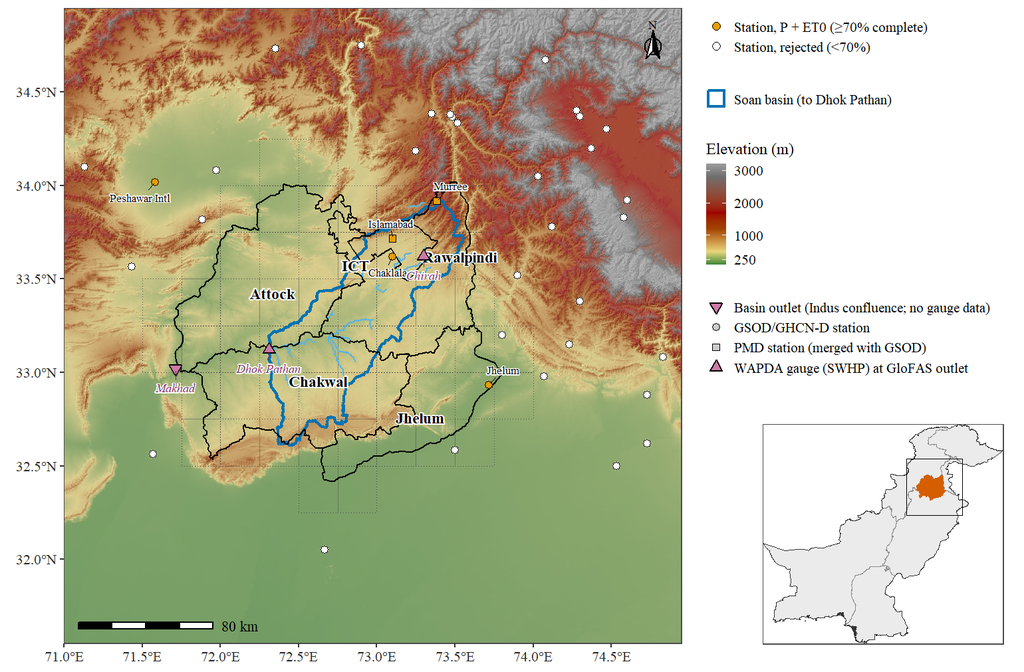

```r
gridlines <- st_cast(st_boundary(G_sf[G_sf$ana, ]), "MULTILINESTRING")
xl <- c(71.0, 74.95); yl <- c(31.55, 34.95)
dl_xy <- cbind(st_drop_geometry(dist_lab), st_coordinates(dist_lab))
p_main <- ggplot() +
  geom_spatraster(data = dem_a, maxcell = 2e6) +
  scale_fill_hypso_tint_c(palette = "dem_poster", name = "Elevation (m)", limits = c(100, 3200), oob = squish,
                          breaks = c(250, 1000, 2000, 3000), na.value = NA) +
  new_scale_fill() +
  geom_spatraster(data = hs_a, maxcell = 2e6, alpha = 0.30, show.legend = FALSE) +
  scale_fill_gradient(low = "black", high = "white", na.value = NA) +
  geom_sf(data = gridlines, colour = "grey30", linewidth = 0.12, linetype = "dotted") +
  geom_sf(data = basin, fill = NA, colour = "#0072B2", linewidth = 0.7, aes(linetype = "Soan basin (to Dhok Pathan)")) +
  geom_sf(data = riv_main, colour = "#56B4E9", linewidth = 0.35) +
  geom_sf(data = dist, fill = NA, colour = "black", linewidth = 0.45) +
  scale_linetype_manual(values = c("Soan basin (to Dhok Pathan)" = "solid"), name = NULL) +
  geom_text_repel(data = dl_xy, aes(X, Y, label = lab), family = "serif", size = 2.6, fontface = "bold", lineheight = 0.85,
                  bg.color = "white", bg.r = 0.12, seed = 3, segment.colour = NA, force = 0.3) +
  new_scale_fill() +
  geom_sf(data = st_sf_pts, aes(shape = network, fill = status), colour = "black", size = 1.6, stroke = 0.35) +
  geom_sf(data = gauges, aes(shape = ifelse(lab == "Makhad", "Basin outlet (Indus confluence; no gauge data)", "WAPDA gauge (SWHP) at GloFAS outlet")), fill = "#CC79A7", colour = "black", size = 1.8) +
  scale_fill_manual(values = c("Station, P + ET0 (≥70% complete)" = "#E69F00", "Station, P only (≥70% complete)" = "#F0E442",
                               "Station, rejected (<70%)" = "white"), name = NULL) +
  guides(fill = guide_legend(override.aes = list(shape = 21, size = 1.8)), shape = guide_legend(override.aes = list(fill = c("#CC79A7", "grey80", "grey80", "#CC79A7")))) +
  geom_text_repel(data = smeta[station %in% ST_USED_P][, lab := sub(" \\(.*", "", station)],
                  aes(lon, lat, label = lab), family = "serif", size = 2.0,
                  min.segment.length = 0, seed = 1, box.padding = 0.3, bg.color = "white", bg.r = 0.12, segment.size = 0.25, max.overlaps = 30) +
  geom_text_repel(data = cbind(st_drop_geometry(gauges), st_coordinates(gauges)), aes(X, Y, label = lab),
                  family = "serif", size = 2.1, colour = "#7a2a5c", fontface = "italic", seed = 2, nudge_y = -0.1,
                  bg.color = "white", bg.r = 0.12, segment.size = 0.25, min.segment.length = 0) +
  scale_shape_manual(values = c("GSOD/GHCN-D station" = 21, "PMD station (merged with GSOD)" = 22, "WAPDA gauge (SWHP) at GloFAS outlet" = 24, "Basin outlet (Indus confluence; no gauge data)" = 25), name = NULL) +
  annotation_scale(location = "bl", height = unit(0.12, "cm"), text_family = "serif", text_cex = 0.6) +
  annotation_north_arrow(location = "tr", height = unit(0.7, "cm"), width = unit(0.5, "cm"), style = north_arrow_fancy_orienteering(text_family = "serif", text_size = 6)) +
  coord_sf(xlim = xl, ylim = yl, expand = FALSE) + labs(x = NULL, y = NULL) +
  theme(legend.position = "right", legend.box = "vertical")
p_inset <- ggplot() + geom_sf(data = pak1, fill = "grey92", colour = "grey55", linewidth = 0.15) +
  geom_sf(data = pak0, fill = NA, colour = "grey20", linewidth = 0.3) +
  geom_sf(data = region, fill = "#D55E00", colour = NA) +
  annotate("rect", xmin = xl[1], xmax = xl[2], ymin = yl[1], ymax = yl[2], fill = NA, colour = "black", linewidth = 0.3) +
  coord_sf(expand = FALSE) + theme_void() + theme(panel.border = element_rect(fill = NA, colour = "grey30", linewidth = 0.4),
                                                  panel.background = element_rect(fill = "white", colour = NA))
p_main <- p_main + theme(legend.justification = c(0, 1), legend.position = "right")
fig1 <- ggdraw(p_main) + draw_plot(p_inset, x = 0.745, y = 0.04, width = 0.235, height = 0.33)
save_fig(fig1, "Fig01_study_area", IEEE2, 4.6); fig1
```

CHIRPS v2.0 provided precipitation. As the methodology specifies, the **Penman–Monteith inputs came from ERA5-Land** (Google Earth Engine; `01i_gee_downloads.py`). These were Tmax and Tmin (monthly means of daily extremes), dew point, surface solar radiation, and **10 m wind speed computed as the monthly mean of hourly √(u²+v²)**, because the monthly vector-mean components would underestimate speed. GEE aggregated each field onto the analysis grids by area-weighted averaging. **TerraClimate** (Tmax, Tmin, vapour pressure, R_s, wind) supplies a second, independent PM estimate used as a sensitivity run (DEVIATIONS D9, v2). TerraClimate PET and CRU TS 4.10 PET serve as independent references.

```r
nc_mat <- function(file, var, cells, lons = glon, lats = glat) {   # -> [time x cells]
  nc <- nc_open(file); on.exit(nc_close(nc))
  a <- ncvar_get(nc, var, collapse_degen = FALSE)                  # [lon, lat, time]
  lo <- round(ncvar_get(nc, "lon"), 3); la <- round(ncvar_get(nc, "lat"), 3)
  il <- match(cells$lon, lo); ia <- match(cells$lat, la)
  stopifnot(!anyNA(il), !anyNA(ia))
  tt <- ncvar_get(nc, "time"); tu <- ncatt_get(nc, "time", "units")$value
  org <- as.Date(sub(".*since ([0-9-]+).*", "\\1", tu))
  dates <- if (grepl("^days", tu)) org + tt else if (grepl("^hours", tu)) org + tt / 24 else stop(tu)
  m <- sapply(seq_len(nrow(cells)), function(i) a[il[i], ia[i], ])
  if (is.null(dim(m))) m <- matrix(m, ncol = nrow(cells))
  attr(m, "dates") <- as.Date(format(dates, "%Y-%m-15")); m
}
OBSF <- file.path(ROOT, "02_obs_preprocess")
OBS <- cached("obs_grids_025", {
  o <- list()
  o$chirps_pr <- nc_mat(file.path(OBSF, "obs_monthly_chirps.nc"), "pr", ANA)
  for (v in c("pr", "tas", "tasmax", "tasmin")) o[[paste0("e5l_", v)]] <- nc_mat(file.path(OBSF, "obs_monthly_era5land.nc"), v, ANA)
  for (v in c("tasmax", "tasmin", "vap", "rsds", "sfcWind", "pet", "pr")) o[[paste0("tc_", v)]] <- nc_mat(file.path(OBSF, "obs_monthly_terraclimate.nc"), v, ANA)
  for (v in c("pr", "tas", "tasmax", "tasmin", "pet", "vap")) o[[paste0("cru_", v)]] <- nc_mat(file.path(OBSF, "obs_monthly_cru.nc"), v, ANA)
  # ERA5-Land PM inputs (GEE, already on the 0.25 deg grid)
  ef <- file.path(RAW, "gee", "era5land_pm_inputs_025.nc")
  for (v in c("temperature_2m_max", "temperature_2m_min", "dewpoint_temperature_2m", "surface_solar_radiation_downwards_sum",
              "wind_speed_10m", "surface_pressure")) o[[paste0("e5pm_", v)]] <- nc_mat(ef, v, ANA)
  o
})
DATES_OBS <- attr(OBS$chirps_pr, "dates"); MON_OBS <- as.integer(format(DATES_OBS, "%m")); YR_OBS <- as.integer(format(DATES_OBS, "%Y"))
stopifnot(all(attr(OBS$tc_tasmax, "dates") == DATES_OBS), all(attr(OBS$e5pm_wind_speed_10m, "dates") == DATES_OBS))
days_in_month <- function(d) { f <- as.Date(format(d, "%Y-%m-01")); as.integer(format(seq(f[1], by = "month", length.out = length(f) + 1)[-1] - 1, "%d")) }
DIM <- matrix(days_in_month(DATES_OBS), length(DATES_OBS), nrow(ANA))   # consecutive months
# ---- ERA5-Land (primary) PM inputs in FAO-56 units ----
OBS$e5_tasmax <- OBS$e5pm_temperature_2m_max - 273.15; OBS$e5_tasmin <- OBS$e5pm_temperature_2m_min - 273.15
OBS$e5_vap <- e0(OBS$e5pm_dewpoint_temperature_2m - 273.15)                        # actual vapour pressure (kPa)
OBS$e5_rsds <- OBS$e5pm_surface_solar_radiation_downwards_sum / DIM / 1e6          # J m-2 month-1 -> MJ m-2 d-1
OBS$e5_sfcWind <- OBS$e5pm_wind_speed_10m                                         # m s-1 at 10 m (hourly-derived mean speed)
OBS$e5_hurs <- pmin(100 * OBS$e5_vap / ((e0(OBS$e5_tasmax) + e0(OBS$e5_tasmin)) / 2), 100)
OBS$pm_et0 <- pm_monthly(OBS$e5_tasmax, OBS$e5_tasmin, OBS$e5_rsds, OBS$e5_sfcWind, OBS$e5_vap, ANA$z, ANA$lat, MON_OBS, DIM[, 1])   # PRIMARY
OBS$hg_et0 <- hg_monthly(OBS$e5_tasmax, OBS$e5_tasmin, ANA$lat, MON_OBS, DIM[, 1])
# ---- TerraClimate (sensitivity) ----
OBS$pm_et0_tc <- pm_monthly(OBS$tc_tasmax, OBS$tc_tasmin, OBS$tc_rsds, OBS$tc_sfcWind, OBS$tc_vap, ANA$z, ANA$lat, MON_OBS, DIM[, 1])
OBS$tc_hurs <- pmin(100 * OBS$tc_vap / ((e0(OBS$tc_tasmax) + e0(OBS$tc_tasmin)) / 2), 100)   # matrix first: keeps dims
wmean <- function(M, w) as.numeric(M %*% w / sum(w))        # area-weighted regional mean of [time x cell]
W_REG <- ANA$w_region; W_BAS <- ANA$w_basin
REG <- data.table(date = DATES_OBS, year = YR_OBS, month = MON_OBS,
                  P_chirps = wmean(OBS$chirps_pr, W_REG), P_e5l = wmean(OBS$e5l_pr, W_REG), P_cru = wmean(OBS$cru_pr, W_REG),
                  P_tc = wmean(OBS$tc_pr, W_REG), ET0_pm = wmean(OBS$pm_et0, W_REG), ET0_hg = wmean(OBS$hg_et0, W_REG),
                  ET0_pm_tc = wmean(OBS$pm_et0_tc, W_REG), PET_tc = wmean(OBS$tc_pet, W_REG), PET_cru = wmean(OBS$cru_pet, W_REG),
                  Tmax = wmean(OBS$e5_tasmax, W_REG), Tmin = wmean(OBS$e5_tasmin, W_REG))
annual_clim <- REG[year >= BASE[1] & year <= BASE[2], lapply(.SD, sum), by = year, .SDcols = patterns("^P_|^ET0|^PET")][, lapply(.SD, mean), .SDcols = -"year"]
KEY$obs_annual_clim_1985_2014 <- annual_clim   # v3.1: full precision; rounded once when printed
knitr::kable(round(annual_clim), caption = "Regional (4 districts + ICT) annual climatology 1985–2014 (mm)")
```

Regional (4 districts + ICT) annual climatology 1985–2014 (mm)

| P_chirps | P_e5l | P_cru | P_tc | ET0_pm | ET0_hg | ET0_pm_tc | PET_tc | PET_cru |
| --- | --- | --- | --- | --- | --- | --- | --- | --- |
| 786 | 1025 | 888 | 594 | 1384 | 1444 | 1342 | 1338 | 1253 |

```r
monsoon_share <- REG[year >= BASE[1] & year <= BASE[2], .(m = sum(P_chirps[month %in% 6:9]) / sum(P_chirps)), by = year][, mean(m)]
KEY$monsoon_share_pct <- 100 * monsoon_share
cat("Share of annual CHIRPS rainfall in June-September (1985-2014):", KEY$monsoon_share_pct, "%\n")
```

```
## Share of annual CHIRPS rainfall in June-September (1985-2014): 64.04264 %
```

```r
# ---- v3.1 station eligibility for every station-based evaluation (GCM station KGE, ET0 skill, station vs gridded indices) ----
# (i) representativeness: |station elevation - mean elevation of its 0.25 deg cell| <= indices.station_dz_max (point-to-grid comparison);
# (ii) relative homogeneity, confirmed against two independent references: a series is "suspect" only if SNHT and Pettitt both reject
#      against CHIRPS/ERA5-Land at the station point (stations-monthly) AND against TerraClimate at the station cell (a break shared by
#      distant stations in one reference is a reference artefact, not a station inhomogeneity); suspect series are not used;
# (iii) ET0 only where >= 70% of 1985-2014 months have observed (or short-gap filled) humidity and wind, so that no reanalysis-derived
#      ET0 is compared with the reanalysis it was derived from. Stations sharing a cell are averaged into one cell value (ranking_helpers.R).
st_cells <- sapply(ST_USED, function(s) { r <- smeta[station == s]; which.min((ANA$lon - r$lon)^2 + (ANA$lat - r$lat)^2) })
st_in <- sapply(ST_USED, function(s) { r <- smeta[station == s]; min(abs(ANA$lon - r$lon)) <= 0.125 & min(abs(ANA$lat - r$lat)) <= 0.125 })
st_dz <- setNames(smeta[match(ST_USED, station), elev_m] - ANA$z[st_cells], ST_USED)
DZ_MAX <- cfg$indices$station_dz_max; KEY$station_dz_max <- DZ_MAX
# second reference: TerraClimate P, Tmax, Tmin and PM ET0 at the station cell (stations inside the analysis domain)
TCREF <- rbindlist(lapply(ST_USED[st_in], function(s) { j <- st_cells[[s]]
  data.table(station = s, year = YR_OBS, month = MON_OBS, P_tc = OBS$tc_pr[, j], ET0_tc = OBS$pm_et0_tc[, j], Tmax_tc = OBS$tc_tasmax[, j], Tmin_tc = OBS$tc_tasmin[, j]) }))
A2 <- merge(SM[station %in% ST_USED[st_in], .(station, year, month, P, ET0, Tmax, Tmin)], TCREF, by = c("station", "year", "month"))
A2 <- A2[, .(P_rel = if (sum(!is.na(P) & !is.na(P_tc)) == 12) sum(P) / sum(P_tc) else NA_real_, ET0_rel = if (sum(!is.na(ET0) & !is.na(ET0_tc)) == 12) sum(ET0) / sum(ET0_tc) else NA_real_,
             Tmax_rel = if (sum(!is.na(Tmax) & !is.na(Tmax_tc)) == 12) mean(Tmax - Tmax_tc) else NA_real_, Tmin_rel = if (sum(!is.na(Tmin) & !is.na(Tmin_tc)) == 12) mean(Tmin - Tmin_tc) else NA_real_),
         by = .(station, year)]
set.seed(SEED)
HOM_TC <- A2[, rbindlist(lapply(c("P", "Tmax", "Tmin", "ET0"), function(v) { h <- homog(get(paste0(v, "_rel"))); yrs <- year[!is.na(get(paste0(v, "_rel")))]
  data.table(variable = v, snht_p_tc = as.numeric(h[1]), pettitt_p_tc = as.numeric(h[2]), change_year_tc = if (!is.na(h[3])) as.integer(yrs[h[3]]) else NA_integer_) })), by = station]
HOM <- merge(HOM, HOM_TC, by = c("station", "variable"), all.x = TRUE)
HOM[, `:=`(class_e5 = class, class_tc = hclass(snht_p_tc, pettitt_p_tc))]
HOM[, class := fifelse(class_e5 == "suspect" & class_tc == "suspect", "suspect",
                fifelse(class_e5 == "homogeneous" & class_tc %in% c("homogeneous", "insufficient"), "homogeneous",
                fifelse(class_e5 == "insufficient" & class_tc == "insufficient", "insufficient", "doubtful")))]
HOM[is.na(class), class := class_e5]   # stations outside the domain: only the CHIRPS/ERA5-Land test exists
ST_EVAL <- ST_USED[st_in & abs(st_dz) <= DZ_MAX]
ST_ET0_OBS <- comp[base_ET0_obs >= 0.7, station]
suspect <- function(v) HOM[variable == v & class == "suspect", station]
ST_EVAL_V <- list(pr = setdiff(ST_EVAL, suspect("P")), tasmax = setdiff(ST_EVAL, suspect("Tmax")), tasmin = setdiff(ST_EVAL, suspect("Tmin")),
                  ET0 = intersect(setdiff(ST_EVAL, suspect("ET0")), ST_ET0_OBS))
KEY$station_vars_without_eligible_station <- names(ST_EVAL_V)[lengths(ST_EVAL_V) == 0]   # their station criterion is dropped from the ranking
KEY$station_eligibility <- data.table(station = ST_USED, in_domain = st_in, dz_cell_m = st_dz, representative = abs(st_dz) <= DZ_MAX,
  hum_wind_obs_pct = 100 * comp[match(ST_USED, station), base_ET0_obs],
  eval_P = ST_USED %in% ST_EVAL_V$pr, eval_Tmax = ST_USED %in% ST_EVAL_V$tasmax, eval_Tmin = ST_USED %in% ST_EVAL_V$tasmin, eval_ET0 = ST_USED %in% ST_EVAL_V$ET0,
  cell = st_cells)
KEY$homogeneity <- HOM
T1 <- merge(smeta[, .(Station = station, Role = role, `Lat (°N)` = round(lat, 3), `Lon (°E)` = round(lon, 3), `Elev. (m)` = round(elev_m))],
            comp[, .(Station = station, `P compl. 1985–2014 (%)` = round(100 * base_P), `ET0 compl. 1985–2014 (%)` = round(100 * base_ET0),
                     `Obs. humidity/wind 1985–2014 (%)` = round(100 * base_ET0_obs), `P compl. 1981–2024 (%)` = round(100 * all_P))], by = "Station")
H2 <- dcast(HOM, station ~ variable, value.var = "class"); setnames(H2, "station", "Station")
setnames(H2, c("P", "Tmax", "Tmin", "ET0"), paste0("Homog. ", c("P", "Tmax", "Tmin", "ET0")), skip_absent = TRUE)
T1 <- merge(T1, H2, by = "Station", all.x = TRUE)
T1[, Used := fifelse(Station %in% ST_USED, "P + ET0", fifelse(Station %in% ST_USED_P, "P only", "no"))]
EL <- KEY$station_eligibility
T1[, `Evaluated for` := sapply(Station, function(s) { e <- EL[station == s]; if (!nrow(e)) return("–")
  v <- c("P", "Tmax", "Tmin", "ET0")[unlist(e[, .(eval_P, eval_Tmax, eval_Tmin, eval_ET0)])]; if (length(v)) paste(v, collapse = ", ") else "none" })]
setorder(T1, -Used, Station)
fwrite(HOM, file.path(ROOT, "02_obs_preprocess", "station_homogeneity_tests.csv"))
save_table(T1, 1, "Station quality control, completeness and relative homogeneity (SNHT and Pettitt, α = 0.05)", "Table1_station_QC_homogeneity",
           note = paste0("Relative tests on station/reference ratios (P, ET0) or differences (Tmax, Tmin) against two references: CHIRPS and ERA5-Land at the station point, and TerraClimate at the station cell. ",
                         "Suspect: both tests reject against both references (not used for that variable); homogeneous: no rejection against either reference; doubtful: otherwise. ",
                         "Evaluated for: variables used in the GCM station KGE, the ET0 skill and the station vs gridded comparison (station in the domain, |elevation − cell mean| ≤ ", DZ_MAX, " m, not suspect; ET0 also needs ≥ 70% observed humidity/wind). ",
                         "Sources: NOAA GSOD and GHCN-Daily; Islamabad (PMD) and Murree (PMD): PMD daily P, Tmax and Tmin 1961–2010 (GSOD after 2010), dew point and wind from GSOD (Murree, completed by quantile-mapped ERA5-Land) and from Chaklala (Islamabad). Completeness counts months complete after short-gap filling."))
```

TABLE I STATION QUALITY CONTROL, COMPLETENESS AND RELATIVE HOMOGENEITY (SNHT AND PETTITT, Α = 0.05)

| Station | Role | Lat (°N) | Lon (°E) | Elev. (m) | P compl. 1985–2014 (%) | ET0 compl. 1985–2014 (%) | Obs. humidity/wind 1985–2014 (%) | P compl. 1981–2024 (%) | Homog. ET0 | Homog. P | Homog. Tmax | Homog. Tmin | Used | Evaluated for |
| --- | --- | --- | --- | --- | --- | --- | --- | --- | --- | --- | --- | --- | --- | --- |
| Akhnoor | 88 km outside | 32.88 | 74.73 | 331.00 | 0.00 | 0.00 | 0.00 | 0.00 | insufficient | insufficient | insufficient | insufficient | no | – |
| Arizal | 94 km outside | 33.92 | 74.60 | 1,615.00 | 0.00 | 0.00 | 0.00 | 0.00 | insufficient | insufficient | insufficient | insufficient | no | – |
| Badgam | 92 km outside | 33.83 | 74.58 | 1,587.00 | 0.00 | 0.00 | 0.00 | 0.00 | insufficient | insufficient | insufficient | insufficient | no | – |
| Balakot | 42 km outside | 34.38 | 73.35 | 981.00 | 29.00 | 29.00 | 29.00 | 42.00 | insufficient | insufficient | insufficient | insufficient | no | – |
| Baramulla | 80 km outside | 34.20 | 74.37 | 1,572.00 | 0.00 | 0.00 | 0.00 | 0.00 | insufficient | insufficient | insufficient | insufficient | no | – |
| Bhimber | 25 km outside | 32.98 | 74.07 | 326.00 | 0.00 | 0.00 | 0.00 | 0.00 | insufficient | insufficient | insufficient | insufficient | no | – |
| Cherat | 16 km outside | 33.82 | 71.88 | 1,372.00 | 0.00 | 0.00 | 0.00 | 0.00 | insufficient | insufficient | insufficient | insufficient | no | – |
| Handwara | 82 km outside | 34.40 | 74.28 | 1,585.00 | 0.00 | 0.00 | 0.00 | 0.00 | insufficient | insufficient | insufficient | insufficient | no | – |
| Kakul | 27 km outside | 34.18 | 73.25 | 1,309.00 | 30.00 | 30.00 | 30.00 | 43.00 | insufficient | insufficient | insufficient | insufficient | no | – |
| Karnah | 89 km outside | 34.67 | 74.08 | 2,799.00 | 0.00 | 0.00 | 0.00 | 0.00 | insufficient | insufficient | insufficient | insufficient | no | – |
| Kohat | 36 km outside | 33.57 | 71.43 | 513.00 | 0.00 | 0.00 | 0.00 | 0.00 | insufficient | insufficient | insufficient | insufficient | no | – |
| Kotli | 25 km outside | 33.52 | 73.90 | 595.00 | 0.00 | 0.00 | 0.00 | 0.00 | insufficient | insufficient | insufficient | insufficient | no | – |
| Landikotal | 92 km outside | 34.10 | 71.13 | 1,068.00 | 0.00 | 7.00 | 7.00 | 0.00 | insufficient | insufficient | insufficient | insufficient | no | – |
| Langet | 82 km outside | 34.37 | 74.30 | 1,588.00 | 0.00 | 0.00 | 0.00 | 0.00 | insufficient | insufficient | insufficient | insufficient | no | – |
| Malam Jabba | 89 km outside | 34.75 | 72.90 | 2,691.00 | 0.00 | 0.00 | 0.00 | 0.00 | insufficient | insufficient | insufficient | insufficient | no | – |
| Mandi Bahauddin | 9 km outside | 32.58 | 73.50 | 253.00 | 0.00 | 0.00 | 0.00 | 0.00 | insufficient | insufficient | insufficient | insufficient | no | – |
| Mianwali | 32 km outside | 32.56 | 71.57 | 210.00 | 0.00 | 0.00 | 0.00 | 0.00 | insufficient | insufficient | insufficient | insufficient | no | – |
| Mirpur | 12 km outside | 33.20 | 73.80 | 336.00 | 0.00 | 0.00 | 0.00 | 0.00 | insufficient | insufficient | insufficient | insufficient | no | – |
| Muzaffar Abad | 39 km outside | 34.37 | 73.48 | 702.00 | 0.00 | 0.00 | 0.00 | 0.00 | insufficient | insufficient | insufficient | insufficient | no | – |
| Muzaffarabad | 35 km outside | 34.33 | 73.52 | 831.00 | 0.00 | 0.00 | 0.00 | 0.00 | insufficient | insufficient | insufficient | insufficient | no | – |
| Muzaffarbad | 40 km outside | 34.38 | 73.47 | 684.00 | 0.00 | 0.00 | 0.00 | 0.00 | insufficient | insufficient | insufficient | insufficient | no | – |
| Nowshera | 43 km outside | 33.15 | 74.23 | 599.00 | 0.00 | 0.00 | 0.00 | 0.00 | insufficient | insufficient | insufficient | insufficient | no | – |
| Poonch | 49 km outside | 33.78 | 74.12 | 1,067.00 | 0.00 | 0.00 | 0.00 | 0.00 | insufficient | insufficient | insufficient | insufficient | no | – |
| Rajpuri(Rampur) | 62 km outside | 33.38 | 74.30 | 924.00 | 0.00 | 0.00 | 0.00 | 0.00 | insufficient | insufficient | insufficient | insufficient | no | – |
| Reasi | 96 km outside | 33.08 | 74.83 | 585.00 | 0.00 | 0.00 | 0.00 | 0.00 | insufficient | insufficient | insufficient | insufficient | no | – |
| Risalpur | 31 km outside | 34.08 | 71.97 | 320.00 | 0.00 | 0.00 | 0.00 | 0.00 | insufficient | insufficient | insufficient | insufficient | no | – |
| Saidu Sharif | 81 km outside | 34.73 | 72.35 | 951.00 | 30.00 | 34.00 | 34.00 | 43.00 | insufficient | insufficient | insufficient | insufficient | no | – |
| Sargodha (WMO41593) | 41 km outside | 32.05 | 72.67 | 187.00 | 0.00 | 0.00 | 0.00 | 0.00 | insufficient | insufficient | insufficient | insufficient | no | – |
| Sargodha (WMO41594) | 41 km outside | 32.05 | 72.67 | 188.00 | 63.00 | 79.00 | 79.00 | 57.00 | doubtful | insufficient | doubtful | doubtful | no | – |
| Sialkot (WMO41599) | 88 km outside | 32.50 | 74.53 | 255.00 | 0.00 | 18.00 | 18.00 | 0.00 | insufficient | insufficient | insufficient | insufficient | no | – |
| Sialkot (WMO41600) | 88 km outside | 32.50 | 74.53 | 250.00 | 35.00 | 42.00 | 42.00 | 46.00 | insufficient | insufficient | insufficient | insufficient | no | – |
| Sialkot (WMO69287) | 88 km outside | 32.50 | 74.53 | 255.00 | 0.00 | 0.00 | 0.00 | 0.00 | insufficient | insufficient | insufficient | insufficient | no | – |
| Sopore | 93 km outside | 34.30 | 74.47 | 1,574.00 | 0.00 | 0.00 | 0.00 | 0.00 | insufficient | insufficient | insufficient | insufficient | no | – |
| Sri Ranbirsingh | 96 km outside | 32.62 | 74.73 | 288.00 | 0.00 | 0.00 | 0.00 | 0.00 | insufficient | insufficient | insufficient | insufficient | no | – |
| Uri | 45 km outside | 34.05 | 74.03 | 1,628.00 | 0.00 | 0.00 | 0.00 | 0.00 | insufficient | insufficient | insufficient | insufficient | no | – |
| Chaklala | inside plateau | 33.62 | 73.10 | 508.00 | 86.00 | 98.00 | 98.00 | 84.00 | suspect | doubtful | suspect | doubtful | P + ET0 | P, Tmin |
| Islamabad (PMD) | inside plateau | 33.72 | 73.10 | 525.00 | 87.00 | 86.00 | 86.00 | 68.00 | suspect | doubtful | suspect | doubtful | P + ET0 | P, Tmin |
| Jhelum | inside plateau | 32.93 | 73.72 | 234.00 | 86.00 | 92.00 | 92.00 | 90.00 | doubtful | suspect | suspect | doubtful | P + ET0 | Tmin, ET0 |
| Murree (PMD) | inside plateau | 33.92 | 73.38 | 2,127.00 | 99.00 | 100.00 | 29.00 | 98.00 | suspect | doubtful | suspect | doubtful | P + ET0 | none |
| Peshawar Intl | 51 km outside | 34.02 | 71.58 | 360.00 | 80.00 | 90.00 | 90.00 | 85.00 | doubtful | suspect | suspect | suspect | P + ET0 | ET0 |

Relative tests on station/reference ratios (P, ET0) or differences (Tmax, Tmin) against two references: CHIRPS and ERA5-Land at the station point, and TerraClimate at the station cell. Suspect: both tests reject against both references (not used for that variable); homogeneous: no rejection against either reference; doubtful: otherwise. Evaluated for: variables used in the GCM station KGE, the ET0 skill and the station vs gridded comparison (station in the domain, |elevation − cell mean| ≤ 500 m, not suspect; ET0 also needs ≥ 70% observed humidity/wind). Sources: NOAA GSOD and GHCN-Daily; Islamabad (PMD) and Murree (PMD): PMD daily P, Tmax and Tmin 1961–2010 (GSOD after 2010), dew point and wind from GSOD (Murree, completed by quantile-mapped ERA5-Land) and from Chaklala (Islamabad). Completeness counts months complete after short-gap filling.

```r
knitr::kable(HOM[station %in% ST_USED, .(station, variable, change_year, class_e5, change_year_tc, class_tc, class)], caption = "Relative homogeneity against two references")
```

Relative homogeneity against two references

| station | variable | change_year | class_e5 | change_year_tc | class_tc | class |
| --- | --- | --- | --- | --- | --- | --- |
| Chaklala | ET0 | 1998 | suspect | 1998 | suspect | suspect |
| Chaklala | P | 2011 | homogeneous | 1997 | suspect | doubtful |
| Chaklala | Tmax | 2002 | suspect | 2002 | suspect | suspect |
| Chaklala | Tmin | 2010 | suspect | 2013 | homogeneous | doubtful |
| Islamabad (PMD) | ET0 | 1995 | suspect | 1995 | suspect | suspect |
| Islamabad (PMD) | P | 1998 | suspect | 1993 | homogeneous | doubtful |
| Islamabad (PMD) | Tmax | 2002 | suspect | 1996 | suspect | suspect |
| Islamabad (PMD) | Tmin | 2006 | doubtful | 2002 | suspect | doubtful |
| Jhelum | ET0 | 2008 | homogeneous | 2012 | suspect | doubtful |
| Jhelum | P | 2012 | suspect | 1996 | suspect | suspect |
| Jhelum | Tmax | 2012 | suspect | 2012 | suspect | suspect |
| Jhelum | Tmin | 2012 | homogeneous | 2005 | suspect | doubtful |
| Murree (PMD) | ET0 | 1990 | suspect | 2008 | suspect | suspect |
| Murree (PMD) | P | 1998 | doubtful | 2012 | doubtful | doubtful |
| Murree (PMD) | Tmax | 1990 | suspect | 1989 | suspect | suspect |
| Murree (PMD) | Tmin | 2008 | homogeneous | 1995 | suspect | doubtful |
| Peshawar Intl | ET0 | 2018 | doubtful | 2018 | doubtful | doubtful |
| Peshawar Intl | P | 1993 | suspect | 1993 | suspect | suspect |
| Peshawar Intl | Tmax | 1998 | suspect | 1998 | suspect | suspect |
| Peshawar Intl | Tmin | 2006 | suspect | 2005 | suspect | suspect |

# 2 Drought indices (III-C)

SPI used a gamma distribution with the probability of zero precipitation *q* (Eq. 2). SPEI used a three-parameter log-logistic distribution on *W* = P − ET₀ (Eq. 3). Both were fitted with unbiased probability-weighted moments (SPEI package; Beguería et al.). RDIst standardised ln(ΣP/ΣET₀) per calendar month (Eq. 4). **Every index was calibrated on the common 1985–2014 baseline**, for the observed series and for each model’s own simulated series. SRI and SDI were computed from WAPDA gauge discharge (calibrated on 1985–2003, the part of the baseline covered by the gauges; v3) and from GloFAS-ERA5 discharge (1985–2014). Values beyond ±3 (outside the fitted support) were capped at ±3.

```r
IDXCAP <- 3
fix_inf <- function(m) { m[is.infinite(m) & m > 0] <- IDXCAP; m[is.infinite(m) & m < 0] <- -IDXCAP
  m[!is.na(m)] <- pmin(pmax(m[!is.na(m)], -IDXCAP), IDXCAP); m }
std_index <- function(X, k, type, start = c(1981, 1), ref = BASE) {
  X <- as.matrix(X); tsx <- ts(X, start = start, frequency = 12)
  f <- if (type == "spi") SPEI::spi else SPEI::spei
  r <- logw(f(tsx, k, distribution = if (type == "spi") "Gamma" else "log-Logistic",
                          ref.start = c(ref[1], 1), ref.end = c(ref[2], 12), na.rm = TRUE, verbose = FALSE), paste("std_index", type, k))
  out <- matrix(as.numeric(r$fitted), nrow = nrow(X)); fix_inf(out)
}
roll_sum <- function(X, k) apply(as.matrix(X), 2, function(v) as.numeric(stats::filter(v, rep(1, k), sides = 1)))
std_by_month <- function(Y, months, years, ref = BASE) {
  out <- Y
  for (m in 1:12) { i <- months == m; r <- i & years >= ref[1] & years <= ref[2]
    mu <- colMeans(Y[r, , drop = FALSE], na.rm = TRUE); sdv <- apply(Y[r, , drop = FALSE], 2, sd, na.rm = TRUE)
    out[i, ] <- sweep(sweep(Y[i, , drop = FALSE], 2, mu), 2, sdv, "/") }
  fix_inf(out)
}
rdi_st <- function(P, PET, k, months, years, ref = BASE) {   # Eq. (4)
  a <- roll_sum(P, k) / roll_sum(PET, k)
  std_by_month(log(pmax(a, 0.01)), months, years, ref)       # alpha floored at 0.01 (k-month totals with zero rain)
}
sdi <- function(Q, k, months, years, ref = BASE) std_by_month(log(pmax(roll_sum(Q, k), 1e-3)), months, years, ref)
all_indices <- function(P, PET, months, years, start = c(1981, 1), ref = BASE, scales = SCALES) {
  out <- list()
  for (k in scales) {
    out[[paste0("SPI", k)]]  <- std_index(P, k, "spi", start, ref)
    out[[paste0("SPEI", k)]] <- std_index(as.matrix(P) - as.matrix(PET), k, "spei", start, ref)
    out[[paste0("RDI", k)]]  <- rdi_st(P, PET, k, months, years, ref)
  }
  out
}
```

```r
# (a) regional series, (b) every 0.25 cell, (c) stations, (d) ERA5-Land/CRU alternatives
IDX_REG <- cached("idx_obs_regional", {
  R <- REG
  list(grid = all_indices(R$P_chirps, R$ET0_pm, R$month, R$year),                 # CHIRPS + ERA5-Land PM (primary)
       grid_tc = all_indices(R$P_chirps, R$ET0_pm_tc, R$month, R$year),           # CHIRPS + TerraClimate PM (sensitivity)
       grid_hg = all_indices(R$P_chirps, R$ET0_hg, R$month, R$year),
       grid_altbase = all_indices(R$P_chirps, R$ET0_pm, R$month, R$year, ref = BASE_ALT),
       e5l = all_indices(R$P_e5l, R$ET0_pm, R$month, R$year),
       cru = all_indices(R$P_cru, R$PET_cru, R$month, R$year))
})
IDX_CELL <- cached("idx_obs_cells", all_indices(OBS$chirps_pr, OBS$pm_et0, MON_OBS, YR_OBS))
IDX_BAS <- cached("idx_obs_basin", all_indices(wmean(OBS$chirps_pr, W_BAS), wmean(OBS$pm_et0, W_BAS), MON_OBS, YR_OBS, scales = 1:12))
IDX_DIST <- cached("idx_obs_district", lapply(setNames(DCOLS, DCOLS), function(d)
  all_indices(wmean(OBS$chirps_pr, ANA[[d]]), wmean(OBS$pm_et0, ANA[[d]]), MON_OBS, YR_OBS)))
# stations (used stations only)
STX <- cached("idx_stations", {
  lapply(setNames(ST_USED, ST_USED), function(s) {
    x <- SM[station == s][order(year, month)][year >= 1981 & year <= 2024]
    full <- CJ(year = 1981:2024, month = 1:12); x <- merge(full, x, by = c("year", "month"), all.x = TRUE)
    list(data = x, idx = all_indices(x$P, x$ET0, x$month, x$year), idx_hg = all_indices(x$P, x$ET0_HG, x$month, x$year))
  })
})
# concurrent drought (SPI <= -1.5 and SPEI <= -1.5)
CONC <- rbindlist(lapply(SCALES, function(k) {
  spi <- IDX_REG$grid[[paste0("SPI", k)]][, 1]; spe <- IDX_REG$grid[[paste0("SPEI", k)]][, 1]
  data.table(scale = k, months_conc = sum(spi <= -1.5 & spe <= -1.5, na.rm = TRUE),
             pct = round(100 * mean(spi <= -1.5 & spe <= -1.5, na.rm = TRUE), 2),
             spei_only = sum(spe <= -1.5 & !(spi <= -1.5), na.rm = TRUE))
}))
KEY$concurrent_obs <- CONC
fwrite(CONC, file.path(ROOT, "04_indices_obs", "concurrent_drought_obs.csv"))
# write regional observed indices
OUTIDX <- data.table(date = DATES_OBS)
for (nm in names(IDX_REG$grid)) OUTIDX[[nm]] <- round(IDX_REG$grid[[nm]][, 1], 3)
fwrite(OUTIDX, file.path(ROOT, "04_indices_obs", "regional_indices_obs_CHIRPS_PM.csv"))
knitr::kable(CONC, caption = "Concurrent drought months (SPI ≤ −1.5 and SPEI ≤ −1.5), regional series 1981–2024")
```

Concurrent drought months (SPI ≤ −1.5 and SPEI ≤ −1.5), regional series 1981–2024

| scale | months_conc | pct | spei_only |
| --- | --- | --- | --- |
| 1 | 22 | 4.17 | 7 |
| 3 | 16 | 3.04 | 11 |
| 6 | 16 | 3.06 | 4 |
| 12 | 8 | 1.55 | 6 |

```r
# v2.1 (audit m10): gridded products archived as CF-1.8 NetCDF on the 0.25° analysis grid (cells outside the domain = missing)
write_cf <- function(file, vars, title) {
  lo <- sort(unique(ANA$lon)); la <- sort(unique(ANA$lat)); il <- match(ANA$lon, lo); ia <- match(ANA$lat, la)
  tdays <- as.numeric(DATES_OBS - as.Date("1981-01-01"))
  dx <- ncdim_def("lon", "degrees_east", lo, longname = "longitude"); dy <- ncdim_def("lat", "degrees_north", la, longname = "latitude")
  dt <- ncdim_def("time", "days since 1981-01-01 00:00:00", tdays, unlim = FALSE, calendar = "standard", longname = "time")
  defs <- lapply(names(vars), function(v) ncvar_def(v, vars[[v]]$units, list(dx, dy, dt), missval = -9999, longname = vars[[v]]$long_name, prec = "float", compression = 4))
  if (file.exists(file)) file.remove(file)
  nc <- nc_create(file, defs, force_v4 = TRUE)
  for (k in seq_along(vars)) { M <- vars[[k]]$data; A3 <- array(NA_real_, c(length(lo), length(la), nrow(M)))
    for (j in seq_len(ncol(M))) A3[il[j], ia[j], ] <- M[, j]
    ncvar_put(nc, defs[[k]], A3)
    for (a in setdiff(names(vars[[k]]), c("data", "units", "long_name"))) ncatt_put(nc, defs[[k]], a, vars[[k]][[a]]) }
  ncatt_put(nc, "lon", "standard_name", "longitude"); ncatt_put(nc, "lat", "standard_name", "latitude"); ncatt_put(nc, "time", "standard_name", "time")
  ncatt_put(nc, "lon", "axis", "X"); ncatt_put(nc, "lat", "axis", "Y"); ncatt_put(nc, "time", "axis", "T")
  for (g in list(c("Conventions", "CF-1.8"), c("title", title), c("institution", "Paper 6 (Potohar Plateau CMIP6 drought), analysis pipeline v2.1"),
                 c("source", "Potohar_Drought_Analysis.Rmd; CHIRPS v2.0 precipitation; ERA5-Land (GEE MONTHLY_AGGR/HOURLY/DAILY_AGGR) Penman-Monteith inputs"),
                 c("history", paste(format(Sys.time(), "%Y-%m-%dT%H:%M:%S"), "written by Potohar_Drought_Analysis.Rmd")),
                 c("references", "Allen et al. (1998) FAO-56; McKee et al. (1993); Vicente-Serrano et al. (2010); Tsakiris et al. (2007)"),
                 c("grid", "NEX-GDDP-CMIP6 native 0.25-degree grid; cells intersecting the four districts, ICT or the Soan basin")))
    ncatt_put(nc, 0, g[1], g[2])
  nc_close(nc); invisible(file)
}
write_cf(file.path(ROOT, "03_et0", "et0_monthly_0p25_1981_2024.nc"),
         list(et0_pm = list(data = OBS$pm_et0, units = "mm month-1", long_name = "FAO-56 Penman-Monteith reference evapotranspiration (ERA5-Land inputs)",
                            standard_name = "water_potential_evaporation_amount", cell_methods = "time: sum"),
              et0_pm_terraclimate = list(data = OBS$pm_et0_tc, units = "mm month-1", long_name = "FAO-56 Penman-Monteith ET0 (TerraClimate inputs; sensitivity)",
                                         standard_name = "water_potential_evaporation_amount", cell_methods = "time: sum"),
              et0_hargreaves = list(data = OBS$hg_et0, units = "mm month-1", long_name = "Hargreaves ET0 (FAO-56 Eq. 52; sensitivity)",
                                    standard_name = "water_potential_evaporation_amount", cell_methods = "time: sum"),
              pr = list(data = OBS$chirps_pr, units = "mm month-1", long_name = "CHIRPS v2.0 precipitation (conservatively remapped)",
                        standard_name = "precipitation_amount", cell_methods = "time: sum")),
         "Monthly reference evapotranspiration and precipitation, Potohar Plateau, 1981-2024")
idx_vars <- lapply(names(IDX_CELL), function(nm) list(data = IDX_CELL[[nm]], units = "1",
  long_name = paste0(sub("[0-9]+$", "", nm), "-", sub("^[A-Z]+", "", nm), " (", c(SPI = "standardized precipitation index, gamma", SPEI = "standardized precipitation-evapotranspiration index, log-logistic",
                     RDI = "standardized reconnaissance drought index")[sub("[0-9]+$", "", nm)], ")"),
  calibration_period = "1985-2014", accumulation_months = as.integer(sub("^[A-Z]+", "", nm)), valid_range_note = "values capped at -3 and +3"))
names(idx_vars) <- names(IDX_CELL)
write_cf(file.path(ROOT, "04_indices_obs", "drought_indices_obs_monthly_0p25_1981_2024.nc"), idx_vars,
         "Observed monthly drought indices (SPI, SPEI, RDIst; 1, 3, 6, 12 months), Potohar Plateau, 1981-2024")
KEY$netcdf_outputs <- c("03_et0/et0_monthly_0p25_1981_2024.nc", "04_indices_obs/drought_indices_obs_monthly_0p25_1981_2024.nc")
```

## 2.1 Hydrological drought: SRI and SDI from WAPDA gauges and GloFAS-ERA5

```r
EWDS <- file.path(OBSF, "glofas_ewds_discharge_daily.csv")    # v2: GloFAS-ERA5 v4.0 historical 1979-2024 from CEMS EWDS
GQ <- fread(if (file.exists(EWDS)) EWDS else file.path(OBSF, "glofas_discharge_daily.csv"))
GLOFAS_SRC <- if (file.exists(EWDS)) "GloFAS-ERA5 v4.0 consolidated (CEMS EWDS), 1979–2024" else "GloFAS v4 via Open-Meteo (from 1997)"
GQ[, date := as.IDate(date)]
QM <- GQ[, .(Q_dp = mean(`Dhok Pathan`, na.rm = TRUE), Q_ch = mean(Chirah, na.rm = TRUE)), by = .(year = year(date), month = month(date))]
Q0 <- max(1981, QM[!is.na(Q_dp), min(year)]); QREF <- if (Q0 <= BASE[1]) BASE else c(1997, 2024)
QREF_ALT <- c(1997, 2024)                                       # v2 item 7b: shorter baseline used in v1
QM <- QM[year >= Q0 & year <= 2024][order(year, month)]
SRI <- list(); SDI <- list(); SRI_ALT <- list(); SDI_ALT <- list()
for (k in 1:12) {
  SRI[[k]] <- std_index(cbind(QM$Q_dp, QM$Q_ch), k, "spi", start = c(Q0, 1), ref = QREF)
  SDI[[k]] <- sdi(cbind(QM$Q_dp, QM$Q_ch), k, QM$month, QM$year, ref = QREF)
  SRI_ALT[[k]] <- std_index(cbind(QM$Q_dp, QM$Q_ch), k, "spi", start = c(Q0, 1), ref = QREF_ALT)
  SDI_ALT[[k]] <- sdi(cbind(QM$Q_dp, QM$Q_ch), k, QM$month, QM$year, ref = QREF_ALT)
}
QM[, date := as.Date(sprintf("%d-%02d-15", year, month))]
KEY$glofas <- list(source = GLOFAS_SRC, start = Q0, ref = QREF)
KEY$glofas_mean_q <- QM[year >= QREF[1] & year <= QREF[2], .(dhok_pathan = mean(Q_dp), chirah = mean(Q_ch))]
if (file.exists(EWDS)) { om <- fread(file.path(OBSF, "glofas_discharge_daily.csv"))[, date := as.IDate(date)]
  j <- merge(GQ, om, by = "date", suffixes = c("_ewds", "_om"))
  KEY$glofas_ewds_vs_openmeteo <- j[, .(r_dp = cor(`Dhok Pathan_ewds`, `Dhok Pathan_om`, use = "complete.obs"), r_ch = cor(Chirah_ewds, Chirah_om, use = "complete.obs"), n_days = .N)] }
# 7b: SDI/SRI drought months with the 1985-2014 vs 1997-2024 calibration (common period 1997-2024)
cp <- QM$year >= 1997
KEY$sdi_baseline_sens <- rbindlist(lapply(c(1, 3, 12), function(k) data.table(k = k,
  r_SRI = cor(SRI[[k]][cp, 1], SRI_ALT[[k]][cp, 1], use = "complete.obs"), r_SDI = cor(SDI[[k]][cp, 1], SDI_ALT[[k]][cp, 1], use = "complete.obs"),
  SRI_drought_pct_main = 100 * mean(SRI[[k]][cp, 1] <= THR, na.rm = TRUE), SRI_drought_pct_alt = 100 * mean(SRI_ALT[[k]][cp, 1] <= THR, na.rm = TRUE))))
KEY$glofas_cells <- fread(file.path(OBSF, "glofas_cell_choice.csv"))[chosen == TRUE]
cat("GloFAS source:", GLOFAS_SRC, "| calibration", QREF, "| mean discharge (m3/s): Dhok Pathan", KEY$glofas_mean_q$dhok_pathan, "; Chirah", KEY$glofas_mean_q$chirah, "\n")
```

```
## GloFAS source: GloFAS-ERA5 v4.0 consolidated (CEMS EWDS), 1979–2024 | calibration 1985 2014 | mean discharge (m3/s): Dhok Pathan 40.95626 ; Chirah 5.368458
```

```r
cat("Correlation SRI-3 vs SDI-3 (Dhok Pathan):", round(cor(SRI[[3]][, 1], SDI[[3]][, 1], use = "complete.obs"), 3), "\n")
```

```
## Correlation SRI-3 vs SDI-3 (Dhok Pathan): 0.994
```

```r
# ---------------- v3: WAPDA gauge discharge (primary observed SRI/SDI) ----------------
WQ <- fread(file.path(ROOT, "data", "wapda", "wapda_discharge_daily.csv"))[, date := as.IDate(date)]
GAUGES <- c(dp = "Dhok Pathan", ch = "Chirah", sil = "Sil (Chahan)")
WM <- dcast(WQ[, .(q = if (sum(!is.na(q_m3s)) >= 0.9 * .N) mean(q_m3s, na.rm = TRUE) else NA_real_), by = .(gauge, year = year(date), month = month(date))],
            year + month ~ gauge, value.var = "q")
setnames(WM, GAUGES, names(GAUGES)); WM <- WM[year >= 1964][order(year, month)]      # 1964: first year of the Dhok Pathan record
QREF_G <- c(1985, 2003); QREF_G_ALT <- c(1974, 2003)
QG <- as.matrix(WM[, names(GAUGES), with = FALSE])
SRI_G <- list(); SDI_G <- list(); SRI_G_ALT <- list()
for (k in 1:12) {
  SRI_G[[k]] <- std_index(QG, k, "spi", start = c(1964, 1), ref = QREF_G)
  SDI_G[[k]] <- sdi(QG, k, WM$month, WM$year, ref = QREF_G)
  SRI_G_ALT[[k]] <- std_index(QG, k, "spi", start = c(1964, 1), ref = QREF_G_ALT)
}
WM[, ym := year * 12L + month]; QM[, ym := year * 12L + month]
KEY$wapda <- list(gauges = unname(GAUGES), records = fread(file.path(ROOT, "data", "wapda", "wapda_qc_log.csv"))[, .(gauge, first = as.character(first), last = as.character(last), n_missing)],
                  ref = QREF_G, ref_alt = QREF_G_ALT,
                  mean_q_ref = WM[year %between% QREF_G, lapply(.SD, function(v) mean(v, na.rm = TRUE)), .SDcols = names(GAUGES)])
# homogeneity of annual mean flow (Pettitt), 1964-2003
WA <- WM[, lapply(.SD, function(v) if (sum(!is.na(v)) == 12) mean(v) else NA_real_), by = year, .SDcols = names(GAUGES)]
KEY$wapda_pettitt <- rbindlist(lapply(names(GAUGES), function(g) { v <- WA[[g]]; ok <- !is.na(v); p <- trend::pettitt.test(v[ok])
  data.table(gauge = GAUGES[[g]], n_years = sum(ok), p = as.numeric(p$p.value), change_year = WA$year[ok][as.integer(p$estimate)],
             mean_before = mean(v[ok][seq_len(as.integer(p$estimate))]), mean_after = mean(v[ok][-seq_len(as.integer(p$estimate))])) }))
# SRI-3 drought share and SRI-3 / SDI-3 agreement at the gauges
KEY$wapda_sri3 <- rbindlist(lapply(seq_along(GAUGES), function(j) { i <- WM$year %between% QREF_G
  data.table(gauge = GAUGES[[j]], drought_pct_ref = 100 * mean(SRI_G[[3]][i, j] <= THR, na.rm = TRUE),
             drought_pct_1981_2003_altref = 100 * mean(SRI_G_ALT[[3]][WM$year >= 1981, j] <= THR, na.rm = TRUE),
             drought_pct_1981_2003 = 100 * mean(SRI_G[[3]][WM$year >= 1981, j] <= THR, na.rm = TRUE),
             r_SRI3_SDI3 = cor(SRI_G[[3]][, j], SDI_G[[3]][, j], use = "complete.obs"), r_SRI3_main_vs_alt = cor(SRI_G[[3]][, j], SRI_G_ALT[[3]][, j], use = "complete.obs")) }))
# GloFAS-ERA5 vs gauge: monthly discharge (1979-2003) and SRI-3 (1985-2003; each with its own calibration)
kge1 <- function(s, o) { r <- cor(s, o); c(r = r, KGE = 1 - sqrt((r - 1)^2 + (sd(s) / sd(o) - 1)^2 + (mean(s) / mean(o) - 1)^2)) }
GVAL <- rbindlist(lapply(c(dp = "Q_dp", ch = "Q_ch"), function(gc) {
  g <- names(which(c(dp = "Q_dp", ch = "Q_ch") == gc)); j <- merge(QM[, .(ym, year, s = get(gc))], WM[, .(ym, o = get(g))], by = "ym")[!is.na(o) & !is.na(s)]
  sj <- merge(data.table(ym = QM$ym, s = SRI[[3]][, match(g, c("dp", "ch"))]), data.table(ym = WM$ym, o = SRI_G[[3]][, match(g, names(GAUGES))]), by = "ym")[
    (ym - 1) %/% 12 >= QREF_G[1] & (ym - 1) %/% 12 <= QREF_G[2] & !is.na(s) & !is.na(o)]
  A <- sj$s <= THR; B <- sj$o <= THR
  data.table(gauge = GAUGES[[g]], period_Q = paste(range(j$year), collapse = "–"), n_months = nrow(j), mean_gauge = mean(j$o), mean_GloFAS = mean(j$s),
             bias_pct = 100 * (mean(j$s) / mean(j$o) - 1), r_Q = kge1(j$s, j$o)[["r"]], r_logQ = cor(log(j$s), log(pmax(j$o, 1e-3))), KGE = kge1(j$s, j$o)[["KGE"]],
             r_SRI3 = cor(sj$s, sj$o), POD_SRI3 = sum(A & B) / sum(B), CSI_SRI3 = sum(A & B) / sum(A | B))
}))
KEY$glofas_vs_wapda <- GVAL
fwrite(GVAL, file.path(ROOT, "11_validation_uncertainty", "glofas_vs_wapda_gauges.csv"))
fwrite(cbind(WM[, .(year, month)], setnames(as.data.table(round(SRI_G[[3]], 3)), paste0("SRI3_", names(GAUGES))), setnames(as.data.table(round(SDI_G[[3]], 3)), paste0("SDI3_", names(GAUGES)))),
       file.path(ROOT, "05_characteristics", "wapda_SRI3_SDI3_monthly.csv"))
save_table(GVAL[, .(Gauge = gauge, Period = period_Q, `Gauge mean (m³/s)` = mean_gauge, `GloFAS mean (m³/s)` = mean_GloFAS, `Bias (%)` = bias_pct, `r (Q)` = r_Q,
                    `r (log Q)` = r_logQ, KGE, `r (SRI-3)` = r_SRI3, `POD (SRI-3 ≤ −1)` = POD_SRI3, `CSI (SRI-3 ≤ −1)` = CSI_SRI3)],
           "S7", "GloFAS-ERA5 v4.0 discharge against WAPDA gauges (monthly)", "TableS7_glofas_vs_wapda",
           note = paste0("Gauge SRI-3 calibrated on ", paste(QREF_G, collapse = "–"), ", GloFAS SRI-3 on ", paste(QREF, collapse = "–"), "; SRI-3 scores over ", paste(QREF_G, collapse = "–"), ". Source: SWHP, WAPDA."))
```

TABLE S7 GLOFAS-ERA5 V4.0 DISCHARGE AGAINST WAPDA GAUGES (MONTHLY)

| Gauge | Period | Gauge mean (m³/s) | GloFAS mean (m³/s) | Bias (%) | r (Q) | r (log Q) | KGE | r (SRI-3) | POD (SRI-3 ≤ −1) | CSI (SRI-3 ≤ −1) |
| --- | --- | --- | --- | --- | --- | --- | --- | --- | --- | --- |
| Dhok Pathan | 1981–2003 | 44.09 | 48.59 | 10.21 | 0.69 | 0.77 | 0.59 | 0.70 | 0.33 | 0.29 |
| Chirah | 1981–2003 | 5.07 | 6.77 | 33.67 | 0.59 | 0.69 | 0.23 | 0.64 | 0.33 | 0.16 |

Gauge SRI-3 calibrated on 1985–2003, GloFAS SRI-3 on 1985–2014; SRI-3 scores over 1985–2003. Source: SWHP, WAPDA.

```r
knitr::kable(GVAL, digits = 2, caption = "GloFAS-ERA5 vs WAPDA gauges")
```

GloFAS-ERA5 vs WAPDA gauges

| gauge | period_Q | n_months | mean_gauge | mean_GloFAS | bias_pct | r_Q | r_logQ | KGE | r_SRI3 | POD_SRI3 | CSI_SRI3 |
| --- | --- | --- | --- | --- | --- | --- | --- | --- | --- | --- | --- |
| Dhok Pathan | 1981–2003 | 276 | 44.09 | 48.59 | 10.21 | 0.69 | 0.77 | 0.59 | 0.70 | 0.33 | 0.29 |
| Chirah | 1981–2003 | 276 | 5.07 | 6.77 | 33.67 | 0.59 | 0.69 | 0.23 | 0.64 | 0.33 | 0.16 |

```r
knitr::kable(KEY$wapda_pettitt, digits = 3, caption = "Pettitt test on annual mean discharge at the WAPDA gauges")
```

Pettitt test on annual mean discharge at the WAPDA gauges

| gauge | n_years | p | change_year | mean_before | mean_after |
| --- | --- | --- | --- | --- | --- |
| Dhok Pathan | 40 | 0.397 | 1998 | 47.860 | 25.405 |
| Chirah | 40 | 0.044 | 1995 | 6.193 | 2.158 |
| Sil (Chahan) | 40 | 0.134 | 1995 | 1.882 | 1.021 |

## 2.2 Agricultural drought: Vegetation Health Index (MODIS)

VCI = (NDVI − NDVI_min)/(NDVI_max − NDVI_min) and TCI = (LST_max − LST)/(LST_max − LST_min) were computed per pixel and calendar month, with VHI = 0.5·VCI + 0.5·TCI (×100) [37]. The extremes come from the full MODIS record (2000–2024), because the 1985–2014 baseline pre-dates MODIS (DEVIATIONS D10). Regional VHI is the cropland-weighted mean, with weights from the ESA WorldCover 2021 cropland fraction. VHI < 40 marks agricultural drought.

```r
HAS_VHI <- file.exists(file.path(OBSF, "modis_monthly_0p01.nc"))
VHI <- if (!HAS_VHI) list(series = data.table(date = as.Date(character()), VHI = numeric(), VCI = numeric(), TCI = numeric())) else cached("vhi", {
  md <- file.path(OBSF, "modis_monthly_0p01.nc")
  nd <- rast(md, subds = "ndvi"); ls <- rast(md, subds = "lst")
  tm <- as.Date(time(nd)); mo <- as.integer(format(tm, "%m"))
  vci <- nd; tci <- ls
  for (m in 1:12) {
    i <- which(mo == m)
    mn <- min(nd[[i]], na.rm = TRUE); mx <- max(nd[[i]], na.rm = TRUE)
    vci[[i]] <- (nd[[i]] - mn) / (mx - mn)
    ln <- min(ls[[i]], na.rm = TRUE); lx <- max(ls[[i]], na.rm = TRUE)
    tci[[i]] <- (lx - ls[[i]]) / (lx - ln)
  }
  vhi <- 100 * (0.5 * vci + 0.5 * tci)
  crop <- rast(file.path(ROOT, "10_exposure", "worldcover_fractions_0p01.tif"))[["cropland"]]
  crop <- resample(crop, vhi[[1]], method = "near")
  regm <- rasterize(vect(region), crop, touches = FALSE) * crop
  w <- values(regm)[, 1]; w[is.na(w)] <- 0
  V <- values(vhi)
  reg <- apply(V, 2, function(v) { ok <- !is.na(v) & w > 0; sum(v[ok] * w[ok]) / sum(w[ok]) })
  list(series = data.table(date = as.Date(format(tm, "%Y-%m-15")), VHI = reg,
                           VCI = apply(values(vci), 2, function(v) { ok <- !is.na(v) & w > 0; 100 * sum(v[ok] * w[ok]) / sum(w[ok]) }),
                           TCI = apply(values(tci), 2, function(v) { ok <- !is.na(v) & w > 0; 100 * sum(v[ok] * w[ok]) / sum(w[ok]) })),
       mean_map = wrap(app(vhi, mean, na.rm = TRUE)), crop = wrap(crop))
})
VH <- VHI$series[date >= as.Date("2000-02-01")]
if (!HAS_VHI) cat("MODIS monthly file not available: VHI skipped.\n")
vhi_spei <- if (!HAS_VHI) data.table() else rbindlist(lapply(SCALES, function(k) {
  s <- data.table(date = DATES_OBS, spei = IDX_REG$grid[[paste0("SPEI", k)]][, 1], spi = IDX_REG$grid[[paste0("SPI", k)]][, 1])
  m <- merge(VH, s, by = "date")
  data.table(scale = k, r_SPEI = cor(m$VHI, m$spei, use = "complete.obs"), r_SPI = cor(m$VHI, m$spi, use = "complete.obs"))
}))
KEY$vhi_drought_months_pct <- 100 * mean(VH$VHI < 40, na.rm = TRUE)
KEY$vhi_spei_cor <- vhi_spei
knitr::kable(vhi_spei, digits = 3, caption = "Correlation of regional cropland VHI with SPEI-k and SPI-k (2000–2024)")
```

Correlation of regional cropland VHI with SPEI-k and SPI-k (2000–2024)

| scale | r_SPEI | r_SPI |
| --- | --- | --- |
| 1 | 0.602 | 0.513 |
| 3 | 0.620 | 0.572 |
| 6 | 0.546 | 0.542 |
| 12 | 0.512 | 0.528 |

## 2.3 Benchmark of the computed SPEI against SPEIbase

SPEIbase v2.10 [27] was obtained from Google Earth Engine (`CSIC/SPEI/2_10`, 1981–2023). It replaces the v1 CRU-based reproduction (DEVIATIONS D12, v2). SPEIbase is calibrated on its full 1901–2023 record and uses CRU TS precipitation and PET at 0.5°, so it is not expected to match the local CHIRPS/ERA5-Land SPEI exactly; the comparison tests the timing and amplitude of the anomalies.

```r
SBF <- file.path(RAW, "gee", "speibase_v2_10_box.nc")     # SPEIbase v2.10 (CSIC/SPEI/2_10, GEE), 0.5 deg
sb_lon <- ncvar_get(nc_open(SBF), "lon"); sb_lat <- ncvar_get(nc_open(SBF), "lat")
sb_grid <- make_grid(sort(sb_lon), sort(sb_lat), 0.5); sb_grid$id <- seq_len(nrow(sb_grid)); sb_grid$w <- frac_in(sb_grid, region)
speibase_reg <- function(k) {          # area-weighted regional mean of SPEIbase over the 4 districts + ICT, matched to DATES_OBS
  m <- nc_mat(SBF, sprintf("spei_%02d", k), st_drop_geometry(sb_grid)[, c("lon", "lat")], lons = round(sb_lon, 3), lats = round(sb_lat, 3))
  w <- sb_grid$w; ok <- w > 0
  v <- as.numeric(m[, ok, drop = FALSE] %*% w[ok] / sum(w[ok]))
  v[match(DATES_OBS, attr(m, "dates"))]
}
BENCH <- rbindlist(lapply(SCALES, function(k) {
  a <- IDX_REG$grid[[paste0("SPEI", k)]][, 1]; b <- speibase_reg(k); ok <- !is.na(a) & !is.na(b)
  data.table(scale = k, reference = "SPEIbase v2.10 (CSIC/SPEI/2_10)", period = paste(range(YR_OBS[ok]), collapse = "–"), n = sum(ok),
             r = cor(a[ok], b[ok]), rmse = sqrt(mean((a[ok] - b[ok])^2)), agree_drought = mean((a[ok] <= -1) == (b[ok] <= -1)),
             r_vs_CRU_reproduction = cor(IDX_REG$cru[[paste0("SPEI", k)]][ok, 1], b[ok], use = "complete.obs"))
}))
KEY$speibase_benchmark <- BENCH
knitr::kable(BENCH, digits = 3, caption = "Computed SPEI (CHIRPS − ERA5-Land PM ET0) vs SPEIbase v2.10 (CSIC/SPEI/2_10), regional; last column: CRU TS 4.10 reproduction vs SPEIbase")
```

Computed SPEI (CHIRPS − ERA5-Land PM ET0) vs SPEIbase v2.10 (CSIC/SPEI/2_10), regional; last column: CRU TS 4.10 reproduction vs SPEIbase

| scale | reference | period | n | r | rmse | agree_drought | r_vs_CRU_reproduction |
| --- | --- | --- | --- | --- | --- | --- | --- |
| 1 | SPEIbase v2.10 (CSIC/SPEI/2_10) | 1981–2023 | 516 | 0.795 | 0.648 | 0.888 | 0.969 |
| 3 | SPEIbase v2.10 (CSIC/SPEI/2_10) | 1981–2023 | 514 | 0.823 | 0.599 | 0.901 | 0.973 |
| 6 | SPEIbase v2.10 (CSIC/SPEI/2_10) | 1981–2023 | 511 | 0.820 | 0.612 | 0.881 | 0.979 |
| 12 | SPEIbase v2.10 (CSIC/SPEI/2_10) | 1981–2023 | 505 | 0.792 | 0.669 | 0.873 | 0.986 |

# 3 Drought characteristics, index selection and propagation (III-D)

## 3.1 Index and time scale most related to wheat losses

v2: **official district wheat yields** were digitised (`scripts/04_digitise_yields.R` → `data/yields/district_wheat.csv`). Sources are PBS *Crops Area and Production by Districts* (1984-85 to 2008-09), Bureau of Statistics Punjab (2007-08 to 2019-20) and *Punjab Development Statistics 2024* (2020-21 to 2022-23). The 2023-24 to 2025-26 seasons come from the Crop Reporting Service (CRS) Punjab district-wise historical data and *Final Rabi Estimates* books; for these seasons Murree and Talagang were added back to Rawalpindi and Chakwal (1985 boundaries). The combined series agrees with the CRS district-wise historical series (1990-91 to 2024-25) to within 0.13% (median; r = 0.998). Harvests within the observed period (1985–2024) are used. These Crop Reporting Service figures are the methodology’s primary yield source, so they drive the index selection. GDHY (Table II alternative; 0.5°, 1982–2016, area-weighted per district) is reported alongside. Yields were detrended linearly (relative anomaly) and correlated with every index (SPI, SPEI, RDI), scale (1, 3, 6, 12) and Rabi month (December–April); significance is from the correlation test (p < 0.05).

```r
gy <- rast(file.path(ROOT, "10_exposure", "gdhy_wheat_potohar.nc"))
yrs_y <- 1981:2016
gcells <- as.data.table(xyFromCell(gy, 1:ncell(gy))); setnames(gcells, c("lon", "lat"))
gpoly <- make_grid(sort(unique(gcells$lon)), sort(unique(gcells$lat)), 0.5); gpoly$id <- seq_len(nrow(gpoly))
YD <- rbindlist(lapply(dist$district, function(d) {
  w <- frac_in(gpoly, dist[dist$district == d, ])
  vals <- terra::extract(gy, as.matrix(st_drop_geometry(gpoly)[, c("lon", "lat")]))
  vals <- as.matrix(vals)
  yv <- apply(vals, 2, function(v) { ok <- !is.na(v) & w > 0; if (!any(ok)) NA else sum(v[ok] * w[ok]) / sum(w[ok]) })
  data.table(district = d, year = yrs_y[seq_along(yv)], yield = yv)
}))
YD <- YD[!is.na(yield)]
YD_GDHY <- YD
OFF <- fread(file.path(ROOT, "data", "yields", "district_wheat.csv"))[flag == "" & !is.na(yield_t_ha) & harvest_year <= max(YR_OBS)]
OFF[, district := fifelse(district == "Islamabad", "Islamabad (ICT)", district)]
YD_OFF <- OFF[, .(district, year = harvest_year, yield = yield_t_ha)]
detr <- function(Y) { Y <- copy(Y); Y[, anom := { f <- fitted(lm(yield ~ year)); (yield - f) / f }, by = district]; Y }
YD_GDHY <- detr(YD_GDHY); YD_OFF <- detr(YD_OFF)
dmap <- setNames(DCOLS, dist$district[match(sub("^w_", "", DCOLS), make.names(dist$district))])
yield_cor <- function(Y) rbindlist(lapply(names(IDX_DIST[[1]]), function(ix) rbindlist(lapply(c(12, 1:4), function(mo) {
  rp <- sapply(dist$district, function(d) {
    v <- IDX_DIST[[dmap[d]]][[ix]][, 1]; s <- data.table(year = YR_OBS, month = MON_OBS, v = v)[month == mo]
    s[, year := if (mo == 12) year + 1L else year]
    m <- merge(Y[district == d], s, by = "year"); if (nrow(m) < 15) return(c(NA, NA))
    ct <- cor.test(m$anom, m$v); c(ct$estimate, ct$p.value)
  })
  data.table(index = ix, month = month.abb[mo], mean_r = mean(rp[1, ], na.rm = TRUE), min_r = min(rp[1, ], na.rm = TRUE),
             n_sig = sum(rp[2, ] < 0.05 & rp[1, ] > 0, na.rm = TRUE))
}))))
YC_OFF <- setorder(yield_cor(YD_OFF), -mean_r); YC_GDHY <- setorder(yield_cor(YD_GDHY), -mean_r)
YC <- YC_OFF                                             # primary: official Crop Reporting Service statistics
SEL <- YC[1]; SEL_TYPE <- sub("[0-9]+$", "", SEL$index); SEL_K <- as.integer(sub("^[A-Z]+", "", SEL$index))
SEL_NAME <- paste0(SEL_TYPE, "-", SEL_K)
KEY$selected_index <- list(index = SEL_NAME, month = SEL$month, mean_r = SEL$mean_r, n_sig = SEL$n_sig,
                           source = paste0("official district yields ", paste(range(OFF$harvest_year), collapse = "–")))
KEY$yield_top5 <- YC[1:5]; KEY$yield_top5_gdhy <- YC_GDHY[1:5]
KEY$yield_sel_in_gdhy <- YC_GDHY[index == SEL$index & month == SEL$month]
KEY$yield_off_vs_gdhy_r <- merge(YD_OFF, YD_GDHY, by = c("district", "year"))[, .(r = cor(anom.x, anom.y), n = .N), by = district]
fwrite(YC_OFF, file.path(ROOT, "05_characteristics", "yield_index_correlations_official.csv"))
fwrite(YC_GDHY, file.path(ROOT, "05_characteristics", "yield_index_correlations_gdhy.csv"))
cat("Selected index (official yields):", SEL_NAME, "ending in", SEL$month, "; mean r =", round(SEL$mean_r, 3),
    "| GDHY best:", YC_GDHY$index[1], YC_GDHY$month[1], round(YC_GDHY$mean_r[1], 3), "\n")
```

```
## Selected index (official yields): SPEI-3 ending in Dec ; mean r = 0.604 | GDHY best: SPEI3 Dec 0.695
```

```r
knitr::kable(cbind(YC_OFF[1:10, .(official = paste(index, month), r_official = mean_r, sig_official = n_sig)],
                   YC_GDHY[1:10, .(GDHY = paste(index, month), r_GDHY = mean_r, sig_GDHY = n_sig)]), digits = 3,
             caption = paste0("Top correlations of detrended wheat yields with drought indices: official district statistics (",
                              paste(range(OFF$harvest_year), collapse = "–"), ") vs GDHY (1982–2016)"))
```

Top correlations of detrended wheat yields with drought indices: official district statistics (1985–2024) vs GDHY (1982–2016)

| official | r_official | sig_official | GDHY | r_GDHY | sig_GDHY |
| --- | --- | --- | --- | --- | --- |
| SPEI3 Dec | 0.604 | 5 | SPEI3 Dec | 0.695 | 5 |
| SPEI6 Mar | 0.564 | 5 | SPEI6 Mar | 0.642 | 5 |
| RDI6 Mar | 0.558 | 5 | RDI6 Mar | 0.627 | 5 |
| SPEI6 Feb | 0.558 | 5 | RDI3 Dec | 0.613 | 5 |
| RDI6 Feb | 0.527 | 5 | SPEI6 Apr | 0.597 | 5 |
| RDI3 Dec | 0.520 | 5 | SPI3 Dec | 0.585 | 5 |
| SPI6 Mar | 0.503 | 5 | SPI6 Mar | 0.585 | 5 |
| RDI3 Mar | 0.495 | 5 | RDI6 Apr | 0.583 | 5 |
| SPEI6 Apr | 0.492 | 5 | SPEI6 Feb | 0.551 | 5 |
| RDI6 Apr | 0.487 | 5 | RDI3 Mar | 0.547 | 5 |

Groundnut, the main Kharif oilseed of the plateau, was checked against the same indices using the Crop Reporting Service *Final Kharif Estimates* books (district area and production, 2017-18 onwards; `data/yields/district_groundnut.csv`). Only eight seasons fall inside the observed period, so this is a consistency check rather than a selection criterion. Yields of Attock, Chakwal, Jhelum and Rawalpindi (the districts with > 0.5 × 10³ ha) were expressed as relative anomalies from each district’s mean and pooled. They were then correlated with each index ending in August–October of the sowing year. SPEI-3 ending in September (July–September monsoon) was fixed in advance as the reference.

```r
GN <- fread(file.path(ROOT, "data", "yields", "district_groundnut.csv"))[!is.na(yield_t_ha) & area_000ha > 0.5]
GN[, sow_year := harvest_year - 1L][, district := fifelse(district == "Islamabad", "Islamabad (ICT)", district)]
GN <- GN[sow_year <= max(YR_OBS)][, anom := yield_t_ha / mean(yield_t_ha) - 1, by = district]
GC <- rbindlist(lapply(c("SPI3", "SPEI1", "SPEI3", "SPEI6", "RDI3"), function(ix) rbindlist(lapply(8:10, function(mo) {
  m <- rbindlist(lapply(unique(GN$district), function(d) {
    s <- data.table(sow_year = YR_OBS, month = MON_OBS, v = IDX_DIST[[dmap[d]]][[ix]][, 1])[month == mo]
    merge(GN[district == d, .(district, sow_year, anom)], s, by = "sow_year") }))
  ct <- cor.test(m$anom, m$v); data.table(index = ix, month = month.abb[mo], r = unname(ct$estimate), p = ct$p.value, n = nrow(m))
}))))
setorder(GC, -r)
KEY$groundnut_check <- list(seasons = paste(range(GN$sow_year), collapse = "–"), n = GC$n[1], districts = sort(unique(GN$district)),
                            reference = GC[index == "SPEI3" & month == "Sep"], best = GC[1])
fwrite(GC, file.path(ROOT, "05_characteristics", "groundnut_index_correlations_crs.csv"))
knitr::kable(GC[1:8], digits = 3, caption = "Pooled correlation of groundnut yield anomalies (CRS Punjab) with drought indices ending in August–October of the sowing year")
```

Pooled correlation of groundnut yield anomalies (CRS Punjab) with drought indices ending in August–October of the sowing year

| index | month | r | p | n |
| --- | --- | --- | --- | --- |
| SPI3 | Aug | 0.592 | 0.001 | 27 |
| SPI3 | Sep | 0.497 | 0.008 | 27 |
| SPEI6 | Oct | 0.449 | 0.019 | 27 |
| RDI3 | Aug | 0.445 | 0.020 | 27 |
| SPEI3 | Sep | 0.443 | 0.021 | 27 |
| SPEI3 | Aug | 0.429 | 0.026 | 27 |
| RDI3 | Sep | 0.390 | 0.045 | 27 |
| SPEI6 | Sep | 0.371 | 0.057 | 27 |

## 3.2 Run theory (Eq. 5) and trends (TFPW–Mann–Kendall, Sen’s slope)

```r
runs_events <- function(x, dates, thr = THR) {
  b <- !is.na(x) & x <= thr; r <- rle(b); e <- cumsum(r$lengths); s <- e - r$lengths + 1
  k <- which(r$values)
  if (!length(k)) return(data.table(start = as.Date(character()), end = as.Date(character()), D = integer(), S = numeric(), I = numeric(), peak = numeric()))
  data.table(start = dates[s[k]], end = dates[e[k]], D = r$lengths[k],
             S = sapply(k, function(i) sum(abs(x[s[i]:e[i]]))), peak = sapply(k, function(i) min(x[s[i]:e[i]])))[, I := S / D][]
}
char_summary <- function(x, dates, years, per, thr = THR) {
  i <- years >= per[1] & years <= per[2]; ev <- runs_events(x[i], dates[i], thr); ny <- per[2] - per[1] + 1
  data.table(n_events = nrow(ev), events_per_decade = 10 * nrow(ev) / ny, freq_pct = 100 * mean(x[i] <= thr, na.rm = TRUE),
             D_mean = if (nrow(ev)) mean(ev$D) else 0, S_mean = if (nrow(ev)) mean(ev$S) else 0,
             I_mean = if (nrow(ev)) mean(ev$I) else NA_real_, D_max = if (nrow(ev)) max(ev$D) else 0, S_max = if (nrow(ev)) max(ev$S) else 0)
}
EV_OBS <- runs_events(IDX_REG$grid[[paste0(SEL_TYPE, SEL_K)]][, 1], DATES_OBS)
fwrite(EV_OBS, file.path(ROOT, "05_characteristics", paste0("events_obs_", SEL_NAME, ".csv")))
CH_OBS <- rbindlist(lapply(names(IDX_REG$grid), function(ix) cbind(index = ix,
  char_summary(IDX_REG$grid[[ix]][, 1], DATES_OBS, YR_OBS, c(1981, 2024)))))
KEY$obs_char <- CH_OBS
KEY$obs_events_sel <- EV_OBS[order(-S)][1:min(5, .N)]
knitr::kable(CH_OBS, digits = 2, caption = "Observed drought characteristics 1981–2024 (run theory, threshold −1)")
```

Observed drought characteristics 1981–2024 (run theory, threshold −1)

| index | n_events | events_per_decade | freq_pct | D_mean | S_mean | I_mean | D_max | S_max |
| --- | --- | --- | --- | --- | --- | --- | --- | --- |
| SPI1 | 63 | 14.32 | 14.20 | 1.19 | 1.71 | 1.44 | 3 | 5.10 |
| SPEI1 | 68 | 15.45 | 15.72 | 1.22 | 1.73 | 1.40 | 3 | 4.86 |
| RDI1 | 67 | 15.23 | 14.39 | 1.13 | 1.77 | 1.56 | 3 | 5.36 |
| SPI3 | 42 | 9.55 | 15.02 | 1.88 | 2.73 | 1.39 | 6 | 8.43 |
| SPEI3 | 35 | 7.95 | 15.02 | 2.26 | 3.22 | 1.37 | 7 | 10.79 |
| RDI3 | 43 | 9.77 | 15.78 | 1.93 | 2.91 | 1.44 | 7 | 10.72 |
| SPI6 | 22 | 5.00 | 13.58 | 3.23 | 4.85 | 1.36 | 8 | 14.46 |
| SPEI6 | 21 | 4.77 | 15.87 | 3.95 | 5.32 | 1.26 | 9 | 13.34 |
| RDI6 | 19 | 4.32 | 14.15 | 3.89 | 5.91 | 1.40 | 8 | 14.08 |
| SPI12 | 10 | 2.27 | 14.70 | 7.60 | 10.82 | 1.36 | 12 | 22.22 |
| SPEI12 | 13 | 2.95 | 15.86 | 6.31 | 8.46 | 1.25 | 19 | 24.94 |
| RDI12 | 9 | 2.05 | 14.70 | 8.44 | 12.32 | 1.41 | 18 | 23.68 |

```r
tfpw <- function(y) {
  y <- as.numeric(y); ok <- !is.na(y); if (sum(ok) < 10) return(c(Z = NA, p = NA, slope = NA))
  r <- tryCatch(modifiedmk::tfpwmk(y[ok]), error = function(e) NULL)
  if (is.null(r)) return(c(Z = NA, p = NA, slope = NA))
  c(Z = unname(r["Z-Value"]), p = unname(r["P-value"]), slope = unname(r["Sen's Slope"]))
}
ann <- REG[, .(P = sum(P_chirps), ET0 = sum(ET0_pm), Tmax = mean(Tmax), Tmin = mean(Tmin), WB = sum(P_chirps - ET0_pm)), by = year]
selx <- IDX_REG$grid[[paste0(SEL_TYPE, SEL_K)]][, 1]
ann2 <- data.table(year = YR_OBS, month = MON_OBS, sel = selx, spei12 = IDX_REG$grid$SPEI12[, 1], spi12 = IDX_REG$grid$SPI12[, 1],
                   rdi12 = IDX_REG$grid$RDI12[, 1])[, .(SEL_mean = mean(sel, na.rm = TRUE), drought_months = sum(sel <= THR, na.rm = TRUE),
                                                        severity = sum(abs(sel[sel <= THR]), na.rm = TRUE),
                                                        SPEI12_Dec = spei12[month == 12], SPI12_Dec = spi12[month == 12], RDI12_Dec = rdi12[month == 12]), by = year]
ann <- merge(ann, ann2, by = "year")
vars_tr <- c(P = "Annual precipitation (mm/decade)", ET0 = "Annual PM ET0 (mm/decade)", Tmax = "Mean Tmax (°C/decade)",
             Tmin = "Mean Tmin (°C/decade)", WB = "Annual P − ET0 (mm/decade)", SPI12_Dec = "SPI-12, December (per decade)",
             SPEI12_Dec = "SPEI-12, December (per decade)", RDI12_Dec = "RDIst-12, December (per decade)",
             SEL_mean = paste0("Annual mean ", SEL_NAME, " (per decade)"), drought_months = paste0("Drought months, ", SEL_NAME, " ≤ −1 (months/decade)"),
             severity = paste0("Annual severity, ", SEL_NAME, " (per decade)"))
TR <- rbindlist(lapply(names(vars_tr), function(v) { t <- tfpw(ann[[v]]); data.table(Series = "Potohar (gridded, 1981–2024)", Variable = vars_tr[[v]],
                 Z = t["Z"], p = t["p"], `Sen slope` = 10 * t["slope"]) }))
if (HAS_VHI) {
  VHA <- VH[, .(VHI = mean(VHI, na.rm = TRUE)), by = .(year = year(date))][year >= 2001]
  t <- tfpw(VHA$VHI); TR <- rbind(TR, data.table(Series = "Potohar cropland (MODIS, 2001–2024)", Variable = "Annual mean VHI (per decade)", Z = t["Z"], p = t["p"], `Sen slope` = 10 * t["slope"]))
}
for (s in ST_USED) {
  a <- STX[[s]]$data[, .(P = if (all(!is.na(P))) sum(P) else NA_real_, ET0 = if (all(!is.na(ET0))) sum(ET0) else NA_real_), by = year]
  for (v in c("P", "ET0")) { t <- tfpw(a[[v]]); hc <- HOM[station == s & variable == v, class]
    TR <- rbind(TR, data.table(Series = paste0(s, " station"), Variable = vars_tr[[v]], Z = t["Z"], p = t["p"], `Sen slope` = 10 * t["slope"],
                               Homogeneity = if (length(hc)) hc else NA_character_), fill = TRUE) }
}
# v2.1 (FDR fix): district-mean trends are the primary trend result; Benjamini-Hochberg across the five units per variable
dname <- setNames(dist$district[match(sub("^w_", "", DCOLS), make.names(dist$district))], DCOLS)
vars_d <- c(P = "Annual precipitation (mm/decade)", ET0 = "Annual PM ET0 (mm/decade)", WB = "Annual P − ET0 (mm/decade)",
            SPEI12_Dec = "SPEI-12, December (per decade)", drought_months = paste0("Drought months, ", SEL_NAME, " ≤ −1 (months/decade)"))
DMEAN <- list()
DTR <- rbindlist(lapply(DCOLS, function(d) {
  a <- data.table(year = YR_OBS, P = wmean(OBS$chirps_pr, ANA[[d]]), E = wmean(OBS$pm_et0, ANA[[d]]), s12 = IDX_DIST[[d]]$SPEI12[, 1],
                  sel = IDX_DIST[[d]][[paste0(SEL_TYPE, SEL_K)]][, 1], mo = MON_OBS)[, .(P = sum(P), ET0 = sum(E), WB = sum(P - E), SPEI12_Dec = s12[mo == 12],
                                                                                 drought_months = sum(sel <= THR, na.rm = TRUE)), by = year]
  DMEAN[[d]] <<- a[, lapply(.SD, mean, na.rm = TRUE), .SDcols = names(vars_d)]
  rbindlist(lapply(names(vars_d), function(v) { t <- tfpw(a[[v]]); data.table(Series = paste0(dname[[d]], " (district mean)"), Variable = vars_d[[v]], var_key = v, unit_key = d,
                                                                            Z = t["Z"], p = t["p"], `Sen slope` = 10 * t["slope"]) })) }))
DTR[, p_BH := p.adjust(p, "BH"), by = Variable]
KEY$district_trends <- DTR
KEY$district_means_1981_2024 <- lapply(setNames(names(vars_d), names(vars_d)), function(v) sapply(DMEAN, function(x) x[[v]]))
TR <- rbind(DTR, TR, fill = TRUE)
TR[is.na(Homogeneity), Homogeneity := "—"]
TR[, Signif := fifelse(!is.na(p_BH), fifelse(p_BH < 0.05, "*", ""), fifelse(p < 0.05, "*", ""))]
TR[Homogeneity %in% c("suspect", "doubtful"), Signif := paste0(Signif, " (not interpreted: inhomogeneous)")]
KEY$trends <- TR
# v2 item 1b: trend audit (TFPW-MK p-values and the arithmetic behind "ET0 offsets x% of the rainfall increase")
tP <- tfpw(ann$P); tE <- tfpw(ann$ET0); tW <- tfpw(ann$WB)
KEY$trend_audit <- list(P_slope_mm_dec = 10 * tP[["slope"]], P_p = tP[["p"]], ET0_slope_mm_dec = 10 * tE[["slope"]], ET0_p = tE[["p"]],
                        WB_slope_mm_dec = 10 * tW[["slope"]], WB_p = tW[["p"]],
                        offset_pct = 100 * tE[["slope"]] / tP[["slope"]],
                        P_minus_ET0_slopes = 10 * (tP[["slope"]] - tE[["slope"]]),
                        note = "offset = Sen slope(ET0) / Sen slope(P); Sen slopes are not additive, so P - ET0 slopes differs slightly from the WB slope")
save_table(TR, 2, "Trend results (TFPW–Mann–Kendall test and Sen's slope)", "Table2_trends",
           note = "District means (primary): * significant after Benjamini–Hochberg control across the five units for each variable (p_BH < 0.05). Regional and station series: * p < 0.05. Slopes are per decade. Gridded series: CHIRPS precipitation and FAO-56 PM ET0 from ERA5-Land inputs, area-weighted (exact polygon fractions).", digits = 3)
```

TABLE II TREND RESULTS (TFPW–MANN–KENDALL TEST AND SEN'S SLOPE)

| Series | Variable | var_key | unit_key | Z | p | Sen slope | p_BH | Homogeneity | Signif |
| --- | --- | --- | --- | --- | --- | --- | --- | --- | --- |
| Islamabad (ICT) (district mean) | Annual precipitation (mm/decade) | P | w_Islamabad..ICT. | 3.077 | 0.002 | 77.240 | 0.003 | — |  |
| Islamabad (ICT) (district mean) | Annual PM ET0 (mm/decade) | ET0 | w_Islamabad..ICT. | 2.742 | 0.006 | 22.879 | 0.015 | — |  |
| Islamabad (ICT) (district mean) | Annual P − ET0 (mm/decade) | WB | w_Islamabad..ICT. | 1.654 | 0.098 | 53.919 | 0.178 | — |  |
| Islamabad (ICT) (district mean) | SPEI-12, December (per decade) | SPEI12_Dec | w_Islamabad..ICT. | 1.654 | 0.098 | 0.247 | 0.171 | — |  |
| Islamabad (ICT) (district mean) | Drought months, SPEI-3 ≤ −1 (months/decade) | drought_months | w_Islamabad..ICT. | -0.168 | 0.867 | 0.000 | 0.983 | — |  |
| Attock (district mean) | Annual precipitation (mm/decade) | P | w_Attock | 2.951 | 0.003 | 45.474 | 0.004 | — |  |
| Attock (district mean) | Annual PM ET0 (mm/decade) | ET0 | w_Attock | 2.868 | 0.004 | 25.514 | 0.015 | — |  |
| Attock (district mean) | Annual P − ET0 (mm/decade) | WB | w_Attock | 0.963 | 0.336 | 19.618 | 0.336 | — |  |
| Attock (district mean) | SPEI-12, December (per decade) | SPEI12_Dec | w_Attock | 0.963 | 0.336 | 0.136 | 0.336 | — |  |
| Attock (district mean) | Drought months, SPEI-3 ≤ −1 (months/decade) | drought_months | w_Attock | -0.021 | 0.983 | 0.000 | 0.983 | — |  |
| Chakwal (district mean) | Annual precipitation (mm/decade) | P | w_Chakwal | 3.579 | 0.000 | 52.312 | 0.002 | — |  |
| Chakwal (district mean) | Annual PM ET0 (mm/decade) | ET0 | w_Chakwal | 2.407 | 0.016 | 22.096 | 0.020 | — |  |
| Chakwal (district mean) | Annual P − ET0 (mm/decade) | WB | w_Chakwal | 1.612 | 0.107 | 37.464 | 0.178 | — |  |
| Chakwal (district mean) | SPEI-12, December (per decade) | SPEI12_Dec | w_Chakwal | 1.633 | 0.103 | 0.243 | 0.171 | — |  |
| Chakwal (district mean) | Drought months, SPEI-3 ≤ −1 (months/decade) | drought_months | w_Chakwal | -1.008 | 0.313 | -0.004 | 0.750 | — |  |
| Jhelum (district mean) | Annual precipitation (mm/decade) | P | w_Jhelum | 3.077 | 0.002 | 57.290 | 0.003 | — |  |
| Jhelum (district mean) | Annual PM ET0 (mm/decade) | ET0 | w_Jhelum | 1.758 | 0.079 | 15.662 | 0.079 | — |  |
| Jhelum (district mean) | Annual P − ET0 (mm/decade) | WB | w_Jhelum | 1.654 | 0.098 | 37.647 | 0.178 | — |  |
| Jhelum (district mean) | SPEI-12, December (per decade) | SPEI12_Dec | w_Jhelum | 1.674 | 0.094 | 0.221 | 0.171 | — |  |
| Jhelum (district mean) | Drought months, SPEI-3 ≤ −1 (months/decade) | drought_months | w_Jhelum | -2.045 | 0.041 | -0.171 | 0.204 | — |  |
| Rawalpindi (district mean) | Annual precipitation (mm/decade) | P | w_Rawalpindi | 2.868 | 0.004 | 66.250 | 0.004 | — |  |
| Rawalpindi (district mean) | Annual PM ET0 (mm/decade) | ET0 | w_Rawalpindi | 2.512 | 0.012 | 20.962 | 0.020 | — |  |
| Rawalpindi (district mean) | Annual P − ET0 (mm/decade) | WB | w_Rawalpindi | 1.444 | 0.149 | 45.608 | 0.186 | — |  |
| Rawalpindi (district mean) | SPEI-12, December (per decade) | SPEI12_Dec | w_Rawalpindi | 1.465 | 0.143 | 0.216 | 0.179 | — |  |
| Rawalpindi (district mean) | Drought months, SPEI-3 ≤ −1 (months/decade) | drought_months | w_Rawalpindi | -0.755 | 0.450 | -0.057 | 0.750 | — |  |
| Potohar (gridded, 1981–2024) | Annual precipitation (mm/decade) |  |  | 3.307 | 0.001 | 56.430 |  | — |  |
| Potohar (gridded, 1981–2024) | Annual PM ET0 (mm/decade) |  |  | 2.407 | 0.016 | 21.734 |  | — |  |
| Potohar (gridded, 1981–2024) | Mean Tmax (°C/decade) |  |  | 3.475 | 0.001 | 0.375 |  | — |  |
| Potohar (gridded, 1981–2024) | Mean Tmin (°C/decade) |  |  | 4.626 | 0.000 | 0.340 |  | — |  |
| Potohar (gridded, 1981–2024) | Annual P − ET0 (mm/decade) |  |  | 1.507 | 0.132 | 35.175 |  | — |  |
| Potohar (gridded, 1981–2024) | SPI-12, December (per decade) |  |  | 3.328 | 0.001 | 0.401 |  | — |  |
| Potohar (gridded, 1981–2024) | SPEI-12, December (per decade) |  |  | 1.444 | 0.149 | 0.211 |  | — |  |
| Potohar (gridded, 1981–2024) | RDIst-12, December (per decade) |  |  | 2.198 | 0.028 | 0.277 |  | — |  |
| Potohar (gridded, 1981–2024) | Annual mean SPEI-3 (per decade) |  |  | 1.423 | 0.155 | 0.105 |  | — |  |
| Potohar (gridded, 1981–2024) | Drought months, SPEI-3 ≤ −1 (months/decade) |  |  | -1.007 | 0.314 | -0.144 |  | — |  |
| Potohar (gridded, 1981–2024) | Annual severity, SPEI-3 (per decade) |  |  | -1.152 | 0.249 | -0.043 |  | — |  |
| Potohar cropland (MODIS, 2001–2024) | Annual mean VHI (per decade) |  |  | 3.803 | 0.000 | 13.364 |  | — |  |
| Chaklala station | Annual precipitation (mm/decade) |  |  | 0.158 | 0.874 | 17.396 |  | doubtful | (not interpreted: inhomogeneous) |
| Chaklala station | Annual PM ET0 (mm/decade) |  |  | 4.853 | 0.000 | 103.013 |  | suspect | * (not interpreted: inhomogeneous) |
| Islamabad (PMD) station | Annual precipitation (mm/decade) |  |  | -1.144 | 0.253 | -84.893 |  | doubtful | (not interpreted: inhomogeneous) |
| Islamabad (PMD) station | Annual PM ET0 (mm/decade) |  |  | 4.253 | 0.000 | 146.312 |  | suspect | * (not interpreted: inhomogeneous) |
| Jhelum station | Annual precipitation (mm/decade) |  |  | 4.567 | 0.000 | 407.590 |  | suspect | * (not interpreted: inhomogeneous) |
| Jhelum station | Annual PM ET0 (mm/decade) |  |  | -0.019 | 0.985 | -0.533 |  | doubtful | (not interpreted: inhomogeneous) |
| Murree (PMD) station | Annual precipitation (mm/decade) |  |  | -0.226 | 0.821 | -18.341 |  | doubtful | (not interpreted: inhomogeneous) |
| Murree (PMD) station | Annual PM ET0 (mm/decade) |  |  | 1.130 | 0.258 | 7.280 |  | suspect | (not interpreted: inhomogeneous) |
| Peshawar Intl station | Annual precipitation (mm/decade) |  |  | 4.012 | 0.000 | 246.622 |  | suspect | * (not interpreted: inhomogeneous) |
| Peshawar Intl station | Annual PM ET0 (mm/decade) |  |  | 1.067 | 0.286 | 16.437 |  | doubtful | (not interpreted: inhomogeneous) |

District means (primary): * significant after Benjamini–Hochberg control across the five units for each variable (p_BH < 0.05). Regional and station series: * p < 0.05. Slopes are per decade. Gridded series: CHIRPS precipitation and FAO-56 PM ET0 from ERA5-Land inputs, area-weighted (exact polygon fractions).

```r
FINE <- cached("fine_trends", {
  f <- file.path(OBSF, "obs_monthly_fine005.nc")
  nc <- nc_open(f); lo <- ncvar_get(nc, "lon"); la <- ncvar_get(nc, "lat"); nc_close(nc)
  FG <- CJ(lat = round(la, 3), lon = round(lo, 3))
  M <- list(pr = nc_mat(f, "pr", FG, lons = round(lo, 3), lats = round(la, 3)))
  ef <- file.path(RAW, "gee", "era5land_pm_inputs_005.nc")                       # ERA5-Land PM inputs (primary)
  e5 <- lapply(c(tx = "temperature_2m_max", tn = "temperature_2m_min", td = "dewpoint_temperature_2m",
                 rs = "surface_solar_radiation_downwards_sum", ws = "wind_speed_10m"), function(v) nc_mat(ef, v, FG, lons = round(lo, 3), lats = round(la, 3)))
  M$tasmax <- e5$tx - 273.15; M$tasmin <- e5$tn - 273.15; M$vap <- e0(e5$td - 273.15)
  M$rsds <- e5$rs / matrix(days_in_month(DATES_OBS), length(DATES_OBS), ncol(e5$rs)) / 1e6; M$sfcWind <- e5$ws
  zf <- terra::extract(dem90, cbind(FG$lon, FG$lat))[, 1]
  ok <- colSums(!is.na(M$pr)) > 400 & colSums(!is.na(M$tasmax)) > 400
  FG <- FG[ok]; M <- lapply(M, function(m) m[, ok]); zf <- zf[ok]
  et <- pm_monthly(M$tasmax, M$tasmin, M$rsds, M$sfcWind, M$vap, zf, FG$lat, MON_OBS, days_in_month(DATES_OBS))
  sp12 <- std_index(M$pr - et, 12, "spei")
  yrs <- unique(YR_OBS)
  aP <- rowsum(M$pr, YR_OBS); aE <- rowsum(et, YR_OBS); aS <- sp12[MON_OBS == 12, ]
  trm <- function(A) t(apply(A, 2, tfpw))
  list(grid = FG, P = trm(aP), ET0 = trm(aE), SPEI12 = trm(aS), meanP = colMeans(aP), meanE = colMeans(aE))
})
```

```r
dts <- data.table(date = DATES_OBS, SPEI3 = IDX_REG$grid$SPEI3[, 1], SPEI12 = IDX_REG$grid$SPEI12[, 1],
                  SPI12 = IDX_REG$grid$SPI12[, 1], RDI12 = IDX_REG$grid$RDI12[, 1], SEL = selx)
ev_sh <- EV_OBS[S >= quantile(EV_OBS$S, 0.75)]
pa <- ggplot(dts, aes(date, SEL)) +
  geom_rect(data = ev_sh, aes(xmin = start, xmax = end + 30, ymin = -Inf, ymax = Inf), inherit.aes = FALSE, fill = "#E69F00", alpha = 0.25) +
  geom_col(aes(fill = SEL > 0), width = 31, show.legend = FALSE) +
  scale_fill_manual(values = c(`TRUE` = DIV_BRBG[9], `FALSE` = DIV_BRBG[3])) +
  geom_hline(yintercept = c(THR, -1.5), linetype = c("dashed", "dotted"), linewidth = 0.3) +
  scale_x_date(date_breaks = "4 years", date_labels = "%Y", expand = c(0.005, 0)) +
  labs(x = NULL, y = SEL_NAME, tag = "(a)",
       subtitle = paste0("Regional ", SEL_NAME, " (selected by wheat-yield correlation); shading: top-quartile severity events")) +
  theme(plot.subtitle = element_text(size = 7, margin = margin(0, 0, 1, 0)))
long <- melt(dts[, .(date, `SPI-12` = SPI12, `SPEI-12` = SPEI12, `RDIst-12` = RDI12)], id.vars = "date")
pb <- ggplot(long, aes(date, value, colour = variable)) + geom_hline(yintercept = 0, linewidth = 0.2) +
  geom_line(linewidth = 0.35) + scale_colour_manual(values = OKABE[c(6, 7, 4)], name = NULL) +
  geom_hline(yintercept = THR, linetype = "dashed", linewidth = 0.3) +
  scale_x_date(date_breaks = "4 years", date_labels = "%Y", expand = c(0.005, 0)) + labs(x = NULL, y = "Index", tag = "(b)") +
  theme(legend.position = "top", legend.justification = c(1, 0), legend.direction = "horizontal", legend.margin = margin(0, 0, -6, 0))
trend_map <- function(TRM, lab, tag, unit, lim = NULL) {
  d <- data.table(FINE$grid, slope = 10 * TRM[, "slope"], p = p.adjust(TRM[, "p"], "BH"))   # v2.1: Benjamini-Hochberg FDR (Wilks 2016)
  lim <- if (is.null(lim)) max(abs(quantile(d$slope, c(0.02, 0.98), na.rm = TRUE))) else lim
  ggplot() + geom_tile(data = d, aes(lon, lat, fill = slope)) +
    scale_fill_gradientn(colours = if (grepl("ET", lab)) rev(DIV_BRBG) else DIV_BRBG, limits = c(-lim, lim), oob = squish, name = unit) +
    geom_point(data = d[p < 0.05], aes(lon, lat), size = 0.12, colour = "grey10", shape = 16) +
    geom_sf(data = dist, fill = NA, colour = "black", linewidth = 0.3) +
    geom_sf(data = basin, fill = NA, colour = "#0072B2", linewidth = 0.4, linetype = "longdash") +
    coord_sf(xlim = c(71.6, 73.9), ylim = c(32.35, 34.15), expand = FALSE) +
    scale_x_continuous(breaks = c(72, 72.5, 73, 73.5)) +
    annotation_scale(location = "bl", height = unit(0.08, "cm"), text_family = "serif", text_cex = 0.45, line_width = 0.4) +
    annotation_north_arrow(location = "tr", height = unit(0.45, "cm"), width = unit(0.32, "cm"), style = north_arrow_orienteering(text_family = "serif", text_size = 4)) +
    labs(x = NULL, y = NULL, tag = tag, title = lab) +
    guides(fill = guide_colourbar(title.position = "top", title.hjust = 0.5, barwidth = unit(3.6, "cm"), barheight = unit(0.18, "cm"))) +
    theme(legend.position = "bottom", legend.text = element_text(size = 6), legend.title = element_text(size = 7),
          plot.title = element_text(size = 8, hjust = 0.5), axis.text = element_text(size = 6), legend.margin = margin(-4, 0, 0, 0))
}
pc <- trend_map(FINE$P, "Annual P trend", "(c)", "mm/decade")
pd <- trend_map(FINE$ET0, "Annual PM ET0 trend", "(d)", "mm/decade")
pe <- trend_map(FINE$SPEI12, "SPEI-12 (Dec) trend", "(e)", "per decade")
fig2 <- (pa / pb / (pc | pd | pe)) + plot_layout(heights = c(1, 0.9, 1.9))
save_fig(fig2, "Fig02_observed_indices_trends", IEEE2, 6.4); fig2
```

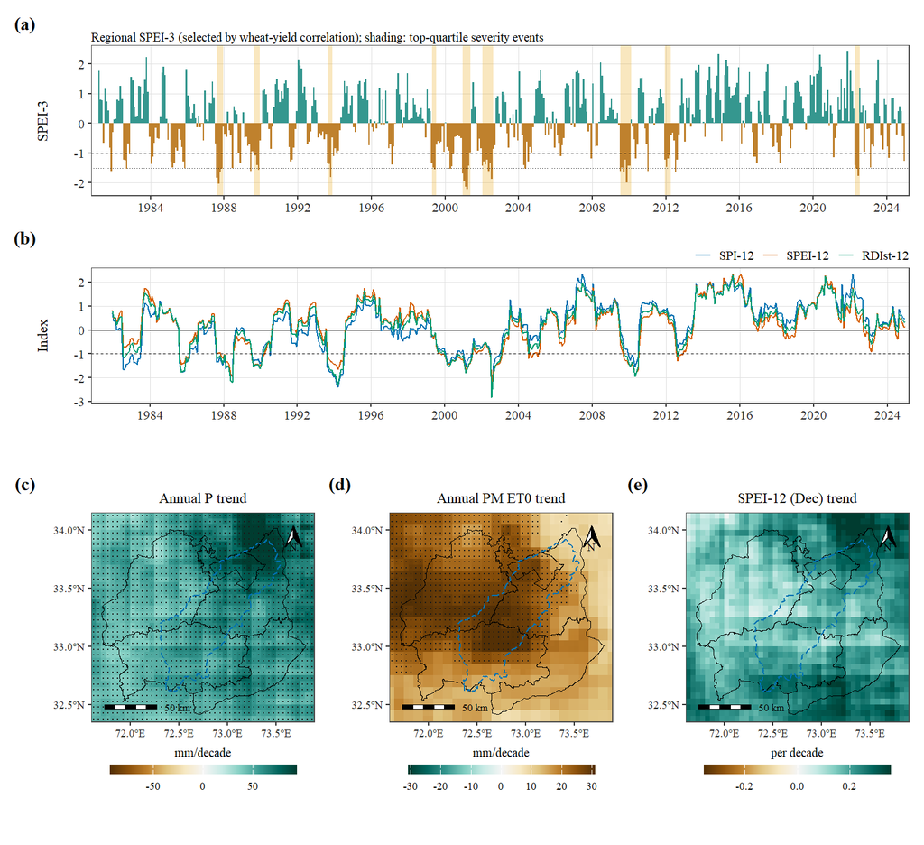

```r
fdr_pct <- function(TRM) round(100 * mean(p.adjust(TRM[, "p"], "BH") < 0.05, na.rm = TRUE), 1)
KEY$fine_trend_sig_pct <- list(P = fdr_pct(FINE$P), ET0 = fdr_pct(FINE$ET0), SPEI12 = fdr_pct(FINE$SPEI12),
                               note = "share of 0.05-deg cells significant after Benjamini-Hochberg FDR control at q = 0.05")
```

## 3.15 Propagation from meteorological to hydrological drought

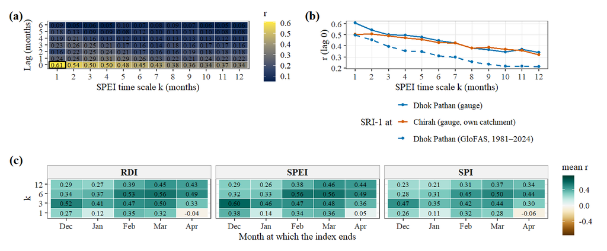

```r
source(file.path(ROOT, "scripts", "R", "propagation_helpers.R"))   # v3.1: prop_tab, prop_best (each gauge with its own catchment SPEI)
IDX_CH <- all_indices(wmean(OBS$chirps_pr, ANA$w_basin_chirah), wmean(OBS$pm_et0, ANA$w_basin_chirah), MON_OBS, YR_OBS, scales = 1:12)
SPEI_CATCH <- list(dp = IDX_BAS, ch = IDX_CH)   # Sil: location and catchment unknown, so not used for propagation (SRI/SDI only)
PR <- prop_tab(WM$ym, list(dp = SRI_G[[1]][, 1], ch = SRI_G[[1]][, 2]), SPEI_CATCH, YR_OBS, MON_OBS)              # primary: WAPDA gauges, 1981-2003
PR_GLOFAS <- prop_tab(QM$ym, list(dp = SRI[[1]][, 1], ch = SRI[[1]][, 2]), SPEI_CATCH, YR_OBS, MON_OBS)           # GloFAS, full record
PR_GLOFAS_0103 <- prop_tab(QM$ym, list(dp = SRI[[1]][, 1], ch = SRI[[1]][, 2]), SPEI_CATCH, YR_OBS, MON_OBS, to = 2003)   # GloFAS, gauge years
best_of <- function(P) { b <- prop_best(P, "dp"); c0 <- prop_best(P, "ch"); c(b, chirah_best_k = c0$best_k_lag0, chirah_r = c0$r_lag0) }
KEY$propagation_glofas <- c(best_of(PR_GLOFAS), period = paste(min(QM$year), 2024, sep = "–"))
KEY$propagation_glofas_1981_2003 <- c(best_of(PR_GLOFAS_0103), period = paste(min(QM$year), 2003, sep = "–"))
best <- PR[which.max(r_dp)]
# 7b: propagation with SRI calibrated on 1997-2024 and evaluated on 1997-2024 only (v1 setting)
sri1a <- data.table(ym = QM$year * 12L + QM$month, sri1 = SRI_ALT[[1]][, 1])[ym >= 1997 * 12 + 1]
PR_ALT <- rbindlist(lapply(1:12, function(k) rbindlist(lapply(0:6, function(L) {
  m <- merge(data.table(ym = YR_OBS * 12L + MON_OBS + L, spei = IDX_BAS[[paste0("SPEI", k)]][, 1]), sri1a, by = "ym")
  data.table(k = k, lag = L, r = cor(m$spei, m$sri1, use = "complete.obs")) }))))
KEY$propagation_alt_1997_2024 <- PR_ALT[which.max(r)]
KEY$propagation <- c(best_of(PR), source = "WAPDA gauges (SWHP)", period = paste(max(1981, min(WM$year)), max(WM$year), sep = "–"), n_months = best$n_dp,
                     chirah_catchment_km2 = basin_tab[grepl("Chirah", name), area_km2])
fwrite(PR, file.path(ROOT, "05_characteristics", "propagation_correlations.csv"))
fwrite(PR_GLOFAS, file.path(ROOT, "05_characteristics", "propagation_correlations_glofas.csv"))
p3a <- ggplot(PR, aes(factor(k), factor(lag), fill = r_dp)) + geom_tile(colour = "white", linewidth = 0.3) +
  geom_text(aes(label = sprintf("%.2f", r_dp)), family = "serif", size = 1.9) +
  geom_tile(data = best, colour = "black", fill = NA, linewidth = 0.6) +
  scale_fill_viridis_c(option = "cividis", name = "r") + labs(x = "SPEI time scale k (months)", y = "Lag (months)", tag = "(a)")
p3b_dat <- rbind(melt(PR[lag == 0, .(k, `Dhok Pathan (gauge)` = r_dp, `Chirah (gauge, own catchment)` = r_ch)], id.vars = "k"),
                 melt(PR_GLOFAS[lag == 0, .(k, `Dhok Pathan (GloFAS, 1981–2024)` = r_dp)], id.vars = "k"))
p3b <- ggplot(p3b_dat, aes(k, value, colour = variable, linetype = variable)) + geom_line(linewidth = 0.5) + geom_point(size = 1) +
  scale_colour_manual(values = OKABE[c(6, 7, 6)], name = "SRI-1 at") +
  scale_linetype_manual(values = c("solid", "solid", "dashed"), name = "SRI-1 at") +
  scale_x_continuous(breaks = 1:12) + labs(x = "SPEI time scale k (months)", y = "r (lag 0)", tag = "(b)") +
  guides(colour = guide_legend(ncol = 1), linetype = guide_legend(ncol = 1)) + theme(legend.position = "bottom", legend.margin = margin(-2, 0, 0, 0))
yc_plot <- YC[grepl("^(SPI|SPEI|RDI)(1|3|6|12)$", index)]
yc_plot[, `:=`(type = sub("[0-9]+$", "", index), k = as.integer(sub("^[A-Z]+", "", index)))]
yc_plot[, month := factor(month, levels = month.abb[c(12, 1:4)])]
p3c <- ggplot(yc_plot, aes(month, factor(k), fill = mean_r)) + geom_tile(colour = "white", linewidth = 0.3) + facet_wrap(~type, nrow = 1) +
  scale_fill_gradientn(colours = DIV_BRBG, limits = c(-0.75, 0.75), oob = squish, name = "mean r") +
  geom_text(aes(label = sprintf("%.2f", mean_r)), family = "serif", size = 1.9) +
  labs(x = "Month at which the index ends", y = "k", tag = "(c)")
fig3 <- (p3a | p3b) / p3c + plot_layout(heights = c(1.2, 1))
save_fig(fig3, "Fig03_propagation_lag", IEEE2, 4.8); fig3
```

# 4 GCM evaluation and bias correction (III-E)

## 4.1 Evaluation of the 27 NEX-GDDP-CMIP6 models, 1985–2014 (Eq. 6)

Each model’s raw NEX-GDDP-CMIP6 output was evaluated against the gridded observations: CHIRPS for P, and ERA5-Land for Tmax, Tmin and PM ET₀ (the dataset that also provides the QDM targets). It was also evaluated against the station climatologies. The metrics were: - Kling–Gupta efficiency (KGE = 1 − √[(r−1)² + (α−1)² + (β−1)²]) on the space–time monthly climatology; - the spatial pattern correlation of the annual-mean field; - the RMSD normalised by the observed standard deviation; - the station KGE of the annual cycle at the station cells.

Models were ranked by **compromise programming** (v2.2 Item 4, PREREGISTRATION.md). Every criterion is normalised as d = (x − best)/(worst − best), and the distance from the ideal point is L = √(Σ w d² / Σ w), with **entropy weights** w (CRITIC and equal weights are sensitivities). A model with negative KGE for any variable (no skill relative to the observed mean) was ranked last and kept out of the normalisation, so that a single failed model cannot compress the range of a criterion. Rank stability was assessed with a **moving-block bootstrap** over 1985–2014: 1000 replicates of six 5-year blocks, with the same years for observations, stations and models, and every metric, weight and rank recomputed. The ten models with the highest probability of a top-10 rank, P(top 10), were retained (ties by mean rank), with weights ∝ 1/L. The selection was frozen (06_gcm_eval/selection_frozen.csv) before any projection was computed.

```r
MODELS <- names(cfg$models)
GCMF <- file.path(ROOT, "06_gcm_eval", "gcm_monthly")
VARS6 <- c("pr", "tasmax", "tasmin", "hurs", "rsds", "sfcWind")
fill_missing_years <- function(M, months) {   # isolated missing values: mean of the same month in adjacent years
  for (j in seq_len(ncol(M))) { bad <- which(is.na(M[, j]))
    for (i in bad) { nb <- c(i - 12, i + 12, i - 24, i + 24); nb <- nb[nb >= 1 & nb <= nrow(M)]
      M[i, j] <- mean(M[nb, j], na.rm = TRUE) } }
  M
}
read_gcm_exp <- function(m, e) {
    f <- file.path(GCMF, paste0(m, "_", e, ".nc")); if (!file.exists(f)) return(NULL)
    x <- setNames(lapply(VARS6, function(v) nc_mat(f, v, ANA)), VARS6)
    d <- attr(x$pr, "dates"); mo <- as.integer(format(d, "%m"))
    nmiss <- sapply(x, function(a) sum(is.na(a)))
    x <- lapply(x, function(a) { if (anyNA(a)) a <- fill_missing_years(a, mo); attr(a, "dates") <- d; a })
    attr(x, "n_filled") <- nmiss; x
}
GCM_AVAIL <- MODELS[file.exists(file.path(GCMF, paste0(MODELS, "_historical.nc")))]
if (length(GCM_AVAIL) < length(MODELS)) cat("Historical files missing for:", setdiff(MODELS, GCM_AVAIL), "\n")
GCM <- cached(paste0("gcm_hist_", length(GCM_AVAIL)), sapply(GCM_AVAIL, function(m) list(historical = read_gcm_exp(m, "historical")), simplify = FALSE))
MODELS <- GCM_AVAIL
D_H <- attr(GCM[[1]]$historical$pr, "dates")
MON_H <- as.integer(format(D_H, "%m")); YR_H <- as.integer(format(D_H, "%Y"))
D_F <- seq(as.Date("2015-01-15"), as.Date("2100-12-15"), by = "month")
MON_F <- as.integer(format(D_F, "%m")); YR_F <- as.integer(format(D_F, "%Y"))
ea_from_hurs <- function(h, tx, tn) h / 100 * (e0(tx) + e0(tn)) / 2
gcm_et0 <- function(x, months, method = "pm", ndays = std_days(months)) {
  if (method == "pm") pm_monthly(x$tasmax, x$tasmin, x$rsds, x$sfcWind, ea_from_hurs(x$hurs, x$tasmax, x$tasmin), ANA$z, ANA$lat, months, ndays)
  else hg_monthly(x$tasmax, x$tasmin, ANA$lat, months, ndays)
}
```

## 4.2 Audit of wind, radiation and ET₀ against stations (v2 item 1a)

Unit and height checks were made in the code. GSOD WDSP is converted from knots to m s⁻¹ (×0.514444). NEX-GDDP `sfcWind`, ERA5-Land and TerraClimate winds are all **10 m** speeds, so like is compared with like. Every PM calculation converts 10 m wind to 2 m with FAO-56 Eq. 47 (u₂ = 0.748·u₁₀) inside `pm_monthly()`/`fao56_pm()`. NEX-GDDP `rsds` is converted from W m⁻² to MJ m⁻² d⁻¹ (×0.0864) and ERA5-Land from J m⁻² month⁻¹ (÷days÷10⁶).

```r
# grid cell of each station on the full 0.25 deg download grid (stations outside the box are skipped)
GALL <- CJ(lat = glat, lon = glon)
st_cell <- smeta[, .(station, lon, lat)][, `:=`(clon = glon[which.min(abs(glon - lon))], clat = glat[which.min(abs(glat - lat))]), by = station]
st_cell <- st_cell[abs(clon - lon) <= 0.125 & abs(clat - lat) <= 0.125]
SC <- unique(st_cell[, .(lon = clon, lat = clat)])
grab <- function(f, v) { m <- nc_mat(f, v, SC); colnames(m) <- paste(SC$lon, SC$lat); m }
AUD <- cached("audit_wind_rad", {
  e5f <- file.path(RAW, "gee", "era5land_pm_inputs_025.nc"); tcf <- file.path(OBSF, "obs_monthly_terraclimate.nc")
  d_o <- attr(grab(tcf, "sfcWind"), "dates")
  list(e5_wind = grab(e5f, "wind_speed_10m"), e5_rs = grab(e5f, "surface_solar_radiation_downwards_sum") / matrix(days_in_month(d_o), length(d_o), nrow(SC)) / 1e6,
       tc_wind = grab(tcf, "sfcWind"), tc_rs = grab(tcf, "rsds"),
       nex_wind = Reduce(`+`, lapply(MODELS, function(m) grab(file.path(GCMF, paste0(m, "_historical.nc")), "sfcWind"))) / length(MODELS),
       nex_rs = Reduce(`+`, lapply(MODELS, function(m) grab(file.path(GCMF, paste0(m, "_historical.nc")), "rsds"))) / length(MODELS))
})
ib <- YR_OBS >= BASE[1] & YR_OBS <= BASE[2]; ih <- YR_H >= BASE[1] & YR_H <= BASE[2]
WSK <- rbindlist(lapply(seq_len(nrow(st_cell)), function(i) { s <- st_cell[i]; key <- paste(s$clon, s$clat)
  sw <- SD[station == s$station & year(date) %between% BASE, .(w = mean(wind10, na.rm = TRUE), n = sum(!is.na(wind10))), by = .(year(date), month(date))]
  if (sum(sw$n > 20) < 60) return(NULL)
  sw <- sw[n > 20]; ix <- match(paste(sw$year, sw$month), paste(YR_OBS, MON_OBS))
  data.table(station = s$station, wind_station = mean(sw$w), wind_ERA5L = mean(AUD$e5_wind[ib, key]), wind_TerraClimate = mean(AUD$tc_wind[ib, key]),
             wind_NEX_raw = mean(AUD$nex_wind[ih, key]), r_ERA5L = cor(sw$w, AUD$e5_wind[ix, key]), r_TC = cor(sw$w, AUD$tc_wind[ix, key]),
             rs_ERA5L = mean(AUD$e5_rs[ib, key]), rs_TerraClimate = mean(AUD$tc_rs[ib, key]), rs_NEX_raw = mean(AUD$nex_rs[ih, key])) }))
WSK[, `:=`(ratio_NEX_station = wind_NEX_raw / wind_station, ratio_NEX_ERA5L = wind_NEX_raw / wind_ERA5L, ratio_ERA5L_station = wind_ERA5L / wind_station,
           ratio_TC_station = wind_TerraClimate / wind_station, rs_ratio_NEX_ERA5L = rs_NEX_raw / rs_ERA5L)]
KEY$audit_wind <- WSK
KEY$audit_wind_summary <- WSK[, .(n_stations = .N, median_ratio_NEX_station = median(ratio_NEX_station), median_ratio_NEX_ERA5L = median(ratio_NEX_ERA5L),
                                  median_ratio_ERA5L_station = median(ratio_ERA5L_station), median_ratio_TC_station = median(ratio_TC_station),
                                  median_rs_ratio_NEX_ERA5L = median(rs_ratio_NEX_ERA5L), median_r_ERA5L = median(r_ERA5L), median_r_TC = median(r_TC))]
fwrite(WSK, file.path(ROOT, "11_validation_uncertainty", "audit_wind_radiation.csv"))
knitr::kable(WSK, digits = 2, caption = "10 m wind (m/s) and Rs (MJ m-2 d-1), 1985–2014, at station cells")
```

10 m wind (m/s) and Rs (MJ m-2 d-1), 1985–2014, at station cells

| station | wind_station | wind_ERA5L | wind_TerraClimate | wind_NEX_raw | r_ERA5L | r_TC | rs_ERA5L | rs_TerraClimate | rs_NEX_raw | ratio_NEX_station | ratio_NEX_ERA5L | ratio_ERA5L_station | ratio_TC_station | rs_ratio_NEX_ERA5L |
| --- | --- | --- | --- | --- | --- | --- | --- | --- | --- | --- | --- | --- | --- | --- |
| Saidu Sharif | 0.22 | 1.16 | 1.14 | 3.39 | 0.07 | 0.57 | 17.70 | 16.71 | 22.58 | 15.32 | 2.92 | 5.24 | 5.14 | 1.28 |
| Peshawar Intl | 1.41 | 1.57 | 1.45 | 3.50 | 0.39 | 0.56 | 17.98 | 17.74 | 21.97 | 2.49 | 2.22 | 1.12 | 1.03 | 1.22 |
| Kakul | 0.27 | 1.27 | 1.10 | 3.57 | 0.17 | 0.44 | 17.81 | 16.71 | 22.02 | 13.06 | 2.81 | 4.65 | 4.03 | 1.24 |
| Balakot | 0.56 | 1.13 | 1.03 | 3.51 | 0.06 | 0.54 | 17.70 | 16.39 | 22.52 | 6.30 | 3.11 | 2.03 | 1.84 | 1.27 |
| Chaklala | 2.53 | 1.92 | 1.21 | 3.67 | 0.19 | 0.61 | 18.09 | 17.05 | 21.33 | 1.45 | 1.91 | 0.76 | 0.48 | 1.18 |
| Murree (PMD) | 1.11 | 1.44 | 1.07 | 3.49 | 0.77 | 0.51 | 17.69 | 16.51 | 21.85 | 3.14 | 2.42 | 1.30 | 0.96 | 1.24 |
| Sargodha (WMO41594) | 1.87 | 1.79 | 1.26 | 3.09 | 0.57 | 0.64 | 18.56 | 18.02 | 21.24 | 1.65 | 1.72 | 0.96 | 0.67 | 1.14 |
| Jhelum | 0.64 | 1.90 | 1.16 | 3.27 | 0.51 | 0.71 | 18.12 | 17.09 | 21.38 | 5.14 | 1.72 | 2.98 | 1.82 | 1.18 |

```r
knitr::kable(KEY$audit_wind_summary, digits = 2, caption = "Audit summary (medians over stations)")
```

Audit summary (medians over stations)

| n_stations | median_ratio_NEX_station | median_ratio_NEX_ERA5L | median_ratio_ERA5L_station | median_ratio_TC_station | median_rs_ratio_NEX_ERA5L | median_r_ERA5L | median_r_TC |
| --- | --- | --- | --- | --- | --- | --- | --- |
| 8 | 4.14 | 2.32 | 1.66 | 1.43 | 1.23 | 0.29 | 0.57 |

```r
# ET0 skill of the two gridded PM estimates against station PM ET0 (monthly, station cells inside the analysis domain)
# v3.1: representative, homogeneous stations with observed humidity/wind only
ESK <- rbindlist(lapply(intersect(ST_EVAL_V$ET0, st_cell$station), function(s) { c0 <- st_cell[station == s]
  j <- which(ANA$lon == c0$clon & ANA$lat == c0$clat); if (!length(j)) return(NULL)
  x <- SM[station == s & !is.na(ET0)][, ix := match(paste(year, month), paste(YR_OBS, MON_OBS))]
  rbindlist(lapply(c(ERA5L = "pm_et0", TerraClimate = "pm_et0_tc"), function(v) { g <- OBS[[v]][x$ix, j]
    data.table(station = s, n_months = nrow(x), r = cor(x$ET0, g), bias_pct = 100 * (sum(g) / sum(x$ET0) - 1), rmse_mm = sqrt(mean((g - x$ET0)^2))) }), idcol = "grid") }))
KEY$et0_skill <- ESK
knitr::kable(ESK, digits = 2, caption = "Monthly PM ET0: gridded (ERA5-Land, TerraClimate) vs station PM ET0")
```

Monthly PM ET0: gridded (ERA5-Land, TerraClimate) vs station PM ET0

| grid | station | n_months | r | bias_pct | rmse_mm |
| --- | --- | --- | --- | --- | --- |
| ERA5L | Jhelum | 499 | 0.98 | 20.82 | 23.48 |
| TerraClimate | Jhelum | 499 | 0.97 | 13.08 | 17.81 |

```r
clim12 <- function(M, months, years, per = BASE) { i <- years >= per[1] & years <= per[2]
  t(sapply(1:12, function(m) colMeans(M[i & months == m, , drop = FALSE], na.rm = TRUE))) }
REGC <- ANA$w_region > 0
kge <- function(s, o) { r <- cor(s, o); a <- sd(s) / sd(o); b <- mean(s) / mean(o)
  c(KGE = 1 - sqrt((r - 1)^2 + (a - 1)^2 + (b - 1)^2), r = r, alpha = a, beta = b) }
OBS_CLIM <- list(pr = clim12(OBS$chirps_pr, MON_OBS, YR_OBS), tasmax = clim12(OBS$e5_tasmax, MON_OBS, YR_OBS),   # v2.1: ERA5-Land (Table I; QDM target)
                 tasmin = clim12(OBS$e5_tasmin, MON_OBS, YR_OBS), ET0 = clim12(OBS$pm_et0, MON_OBS, YR_OBS))
source(file.path(ROOT, "scripts", "R", "ranking_helpers.R"))   # station_kge (v3.1), crit_weights, cp_rank, eval_from_counts
# station climatologies (annual cycle); st_cells, ST_EVAL and ST_EVAL_V (eligible stations per variable) are set in stations-monthly
st_clim <- lapply(setNames(ST_EVAL, ST_EVAL), function(s) STX[[s]]$data[year >= BASE[1] & year <= BASE[2],
  .(pr = mean(P, na.rm = TRUE), tasmax = mean(Tmax, na.rm = TRUE), tasmin = mean(Tmin, na.rm = TRUE), ET0 = mean(ET0, na.rm = TRUE)), by = month][order(month)])
EVAL <- cached("gcm_eval_v2_1", rbindlist(lapply(MODELS, function(m) {
  x <- GCM[[m]]$historical; et <- gcm_et0(x, MON_H, ndays = days_in_month(D_H))
  sim <- list(pr = clim12(x$pr, MON_H, YR_H), tasmax = clim12(x$tasmax, MON_H, YR_H), tasmin = clim12(x$tasmin, MON_H, YR_H), ET0 = clim12(et, MON_H, YR_H))
  rbindlist(lapply(names(sim), function(v) {
    s <- sim[[v]][, REGC]; o <- OBS_CLIM[[v]][, REGC]
    k <- kge(as.numeric(s), as.numeric(o))
    pcc <- cor(colMeans(s), colMeans(o))
    nrmsd <- sqrt(mean((s - o)^2)) / sd(as.numeric(o))
    kst <- station_kge(sim[[v]], function(st) st_clim[[st]][[v]], ST_EVAL_V[[v]], st_cells)   # one value per cell (v3.1)
    data.table(model = m, variable = v, KGE = k["KGE"], r = k["r"], alpha = k["alpha"], beta = k["beta"], PCC = pcc, nRMSD = nrmsd, KGE_station = kst)
  }))
})))
# ---- v2.2 Item 4 (PREREGISTRATION.md): entropy-weighted compromise programming and block-bootstrap rank stability ----
# d = (x - best)/(worst - best) per criterion (16 criteria), best/worst over models that pass the KGE >= 0 screen (D17).
# Criterion weights: entropy (primary), CRITIC and equal (sensitivities). L = sqrt(sum w d^2 / sum w). No-skill models rank last.
source(file.path(ROOT, "scripts", "R", "ranking_helpers.R"))   # crit_weights, cp_rank, eval_from_counts
crit <- cp_criteria(EVAL)
NOSKILL <- EVAL[KGE < 0, unique(model)]
KEY$no_skill_models <- NOSKILL
FULL <- lapply(c(entropy = "entropy", critic = "critic", equal = "equal"), function(w) cp_rank(EVAL, w))
KEY$criterion_weights <- rbindlist(lapply(names(FULL), function(w) data.table(weighting = w, criterion = names(FULL[[w]]$weights), weight = FULL[[w]]$weights)))
# moving-block bootstrap over 1985-2014: 6 blocks of 5 years (starts uniform on 1985-2010), same years for obs, stations and models
BYRS <- BASE[1]:BASE[2]; NBOOT <- 1000L; KEY$n_boot <- NBOOT
set.seed(SEED); BOOT_YEARS <- replicate(NBOOT, { st <- sample(BASE[1]:(BASE[2] - 4), 6, replace = TRUE); as.vector(sapply(st, function(a) a:(a + 4))) })
BOOT_COUNTS <- apply(BOOT_YEARS, 2, function(y) tabulate(match(y, BYRS), length(BYRS)))          # [30 years x NBOOT]
EVSTACK <- cached("gcm_eval_stacks", eval_stacks())                                               # per-year monthly fields (obs, stations, models)
chk <- eval_from_counts(EVSTACK, rep(1, length(BYRS)))                                             # all years once = full sample
stopifnot(isTRUE(all.equal(as.matrix(chk[order(model, variable), .(KGE, PCC, nRMSD, KGE_station)]), as.matrix(EVAL[order(model, variable), .(KGE, PCC, nRMSD, KGE_station)]), tolerance = 1e-8, check.attributes = FALSE)))
BOOT <- cached("gcm_rank_bootstrap", rbindlist(lapply(seq_len(NBOOT), function(b) { ev <- eval_from_counts(EVSTACK, BOOT_COUNTS[, b])
  rbindlist(lapply(c("entropy", "critic", "equal"), function(w) cbind(rep = b, weighting = w, cp_rank(ev, w)$rank[, .(model, L, rank)]))) })))
NKEEP <- min(cfg$ensemble$keep_top, length(MODELS))
STAB <- BOOT[, .(mean_rank = mean(rank), rank_q05 = quantile(rank, 0.05, type = 7), rank_q95 = quantile(rank, 0.95, type = 7), p_top10 = mean(rank <= NKEEP)), by = .(weighting, model)]
STAB <- merge(STAB, rbindlist(lapply(names(FULL), function(w) cbind(weighting = w, FULL[[w]]$rank[, .(model, L_full = L, rank_full = rank)]))), by = c("weighting", "model"))
setorder(STAB, weighting, -p_top10, mean_rank); STAB[, sel_order := seq_len(.N), by = weighting][, selected := sel_order <= NKEEP]
KEY$rank_stability <- STAB
fwrite(STAB, file.path(ROOT, "06_gcm_eval", "gcm_rank_bootstrap_stability.csv"))
# selection rule (fixed): 10 highest P(top 10), ties by lower mean rank; entropy weighting is primary
CP <- STAB[weighting == "entropy", .(model, L = L_full, rank_full, mean_rank, rank_q05, rank_q95, p_top10, rank = sel_order)]
CP <- merge(CP, FULL$equal$rank[, .(model, L2 = L)], by = "model")[order(rank)]                    # L2: equal weights (v2.1 definition)
TOP <- CP[rank <= NKEEP, model]
CP[, weight := fifelse(rank <= NKEEP, (1 / L) / sum((1 / L)[rank <= NKEEP]), 0)]
FROZEN <- file.path(ROOT, "06_gcm_eval", "selection_frozen.csv")
if (file.exists(FROZEN) && !DEV) { fz <- fread(FROZEN)                                             # frozen at tag frozen-bc-rank
  if (!setequal(fz[selected == TRUE, model], TOP)) stop("GCM selection differs from the frozen selection (06_gcm_eval/selection_frozen.csv)")
} else if (!DEV) fwrite(CP[, .(model, selected = rank <= NKEEP, sel_order = rank, p_top10, mean_rank, rank_q05, rank_q95, L_entropy = L, weight)], FROZEN)
V21_SET <- unlist(cfg$ensemble$v21_primary_set)
KEY$selection_overlap <- data.table(comparison = c("v2.1 primary set", "v2 TerraClimate-referenced set", "CRITIC-weighted selection", "equal-weight selection"),
  n_common = c(length(intersect(TOP, V21_SET)), length(intersect(TOP, unlist(cfg$ensemble$sensitivity_set_old))),
               length(intersect(TOP, STAB[weighting == "critic" & selected == TRUE, model])), length(intersect(TOP, STAB[weighting == "equal" & selected == TRUE, model]))),
  dropped = c(paste(setdiff(V21_SET, TOP), collapse = ", "), paste(setdiff(unlist(cfg$ensemble$sensitivity_set_old), TOP), collapse = ", "),
              paste(setdiff(STAB[weighting == "critic" & selected == TRUE, model], TOP), collapse = ", "), paste(setdiff(STAB[weighting == "equal" & selected == TRUE, model], TOP), collapse = ", ")),
  added = c(paste(setdiff(TOP, V21_SET), collapse = ", "), paste(setdiff(TOP, unlist(cfg$ensemble$sensitivity_set_old)), collapse = ", "),
            paste(setdiff(TOP, STAB[weighting == "critic" & selected == TRUE, model]), collapse = ", "), paste(setdiff(TOP, STAB[weighting == "equal" & selected == TRUE, model]), collapse = ", ")))
for (w in c("entropy", "critic", "equal")) for (m in STAB[weighting == w, model]) { x <- STAB[weighting == w & model == m]
  rl <- if (w == "entropy") "primary" else "sensitivity"
  add_variant("4", paste0(w, " weights: ", m), rl, "P(top 10)", x$p_top10); add_variant("4", paste0(w, " weights: ", m), rl, "mean rank", x$mean_rank) }
TSR <- STAB[weighting == "entropy", .(`Selection order` = sel_order, Model = model, `L (entropy, full sample)` = round(L_full, 3), `Full-sample rank` = rank_full,
  `Mean rank` = round(mean_rank, 1), `90% rank interval` = sprintf("%g–%g", rank_q05, rank_q95), `P(top 10)` = round(p_top10, 3), Selected = selected,
  `P(top 10), CRITIC` = round(STAB[weighting == "critic"][match(model, STAB[weighting == "critic", model]), p_top10], 3),
  `P(top 10), equal` = round(STAB[weighting == "equal"][match(model, STAB[weighting == "equal", model]), p_top10], 3))]
save_table(TSR, "S2b", "GCM rank stability: moving-block bootstrap over 1985–2014 (1000 replicates, 5-year blocks)", "TableS2b_GCM_rank_stability",
           note = "Entropy-weighted compromise programming (primary); in each replicate the climatologies, 16 metrics, normalisation, weights and ranks are recomputed. Selection: the ten highest P(top 10), ties by mean rank (pre-registered).", digits = 3)
```

TABLE S2b GCM RANK STABILITY: MOVING-BLOCK BOOTSTRAP OVER 1985–2014 (1000 REPLICATES, 5-YEAR BLOCKS)

| Selection order | Model | L (entropy, full sample) | Full-sample rank | Mean rank | 90% rank interval | P(top 10) | Selected | P(top 10), CRITIC | P(top 10), equal |
| --- | --- | --- | --- | --- | --- | --- | --- | --- | --- |
| 1 | MIROC6 | 0.303 | 3 | 4.300 | 1–12 | 0.927 | true | 0.908 | 0.914 |
| 2 | GISS-E2-1-G | 0.378 | 6 | 7.300 | 3–13 | 0.886 | true | 0.905 | 0.903 |
| 3 | NorESM2-MM | 0.232 | 1 | 4.900 | 1–13 | 0.878 | true | 0.832 | 0.899 |
| 4 | CNRM-CM6-1 | 0.276 | 2 | 5.500 | 1–16 | 0.841 | true | 0.797 | 0.812 |
| 5 | ACCESS-ESM1-5 | 0.346 | 4 | 7.400 | 2–16 | 0.747 | true | 0.744 | 0.749 |
| 6 | CMCC-ESM2 | 0.479 | 10 | 8.300 | 1–21 | 0.681 | true | 0.676 | 0.692 |
| 7 | CNRM-ESM2-1 | 0.352 | 5 | 9.500 | 2–19 | 0.607 | true | 0.633 | 0.625 |
| 8 | INM-CM4-8 | 0.470 | 9 | 9.600 | 2–19 | 0.594 | true | 0.571 | 0.571 |
| 9 | NorESM2-LM | 0.385 | 7 | 9.400 | 2–19 | 0.586 | true | 0.558 | 0.563 |
| 10 | GFDL-CM4 | 0.389 | 8 | 10.200 | 4–18 | 0.563 | true | 0.545 | 0.554 |
| 11 | TaiESM1 | 0.519 | 14 | 10.900 | 3–20 | 0.478 | false | 0.414 | 0.458 |
| 12 | EC-Earth3 | 0.515 | 12 | 12.200 | 2–24 | 0.437 | false | 0.414 | 0.409 |
| 13 | MPI-ESM1-2-HR | 0.534 | 15 | 13.200 | 2–25 | 0.396 | false | 0.369 | 0.401 |
| 14 | GFDL-ESM4 | 0.518 | 13 | 13.800 | 5–24 | 0.291 | false | 0.365 | 0.354 |
| 15 | EC-Earth3-Veg-LR | 0.548 | 17 | 14.800 | 5–24 | 0.234 | false | 0.280 | 0.255 |
| 16 | MIROC-ES2L | 0.706 | 23 | 17.900 | 5–26 | 0.188 | false | 0.223 | 0.200 |
| 17 | IPSL-CM6A-LR | 0.511 | 11 | 16.200 | 7–25 | 0.160 | false | 0.164 | 0.126 |
| 18 | UKESM1-0-LL | 0.541 | 16 | 16.300 | 8–23 | 0.134 | false | 0.125 | 0.113 |
| 19 | MPI-ESM1-2-LR | 0.618 | 20 | 18.200 | 8–26 | 0.104 | false | 0.113 | 0.104 |
| 20 | MRI-ESM2-0 | 0.600 | 19 | 19.300 | 8–27 | 0.100 | false | 0.113 | 0.098 |
| 21 | FGOALS-g3 | 0.581 | 18 | 17.100 | 9–24 | 0.081 | false | 0.105 | 0.072 |
| 22 | HadGEM3-GC31-LL | 0.668 | 22 | 18.700 | 11–24 | 0.047 | false | 0.074 | 0.065 |
| 23 | INM-CM5-0 | 0.625 | 21 | 19.900 | 11.95–26 | 0.035 | false | 0.067 | 0.059 |
| 24 | ACCESS-CM2 | 0.746 | 26 | 21.500 | 15–26 | 0.005 | false | 0.005 | 0.004 |
| 25 | KACE-1-0-G | 0.721 | 25 | 22.400 | 16–26 | 0.000 | false | 0.000 | 0.000 |
| 26 | KIOST-ESM | 0.717 | 24 | 22.700 | 17–27 | 0.000 | false | 0.000 | 0.000 |
| 27 | CanESM5 | 0.923 | 27 | 26.400 | 24–27 | 0.000 | false | 0.000 | 0.000 |

Entropy-weighted compromise programming (primary); in each replicate the climatologies, 16 metrics, normalisation, weights and ranks are recomputed. Selection: the ten highest P(top 10), ties by mean rank (pre-registered).

```r
WTS <- setNames(CP[model %in% TOP]$weight, CP[model %in% TOP]$model)[TOP]
if (!DEV) writeLines(union(TOP, intersect(c("GFDL-ESM4", "IPSL-CM6A-LR", "MPI-ESM1-2-HR", "MRI-ESM2-0", "UKESM1-0-LL"), MODELS)),
           file.path(ROOT, "06_gcm_eval", "phaseB_models.txt"))   # models whose scenario runs are needed (QDM + ISIMIP comparison)
if (DEV) { avail <- MODELS[sapply(MODELS, function(m) all(file.exists(file.path(GCMF, paste0(m, "_", SCEN, ".nc")))))]
  TOP <- intersect(TOP, avail); WTS <- WTS[TOP] / sum(WTS[TOP]); NKEEP <- length(TOP); cat("DEV MODE: models", TOP, "\n") }
KEY$gcm_rank <- CP; KEY$top_models <- TOP; KEY$top_weights <- WTS
fwrite(EVAL, file.path(ROOT, "06_gcm_eval", "gcm_metrics.csv")); fwrite(CP, file.path(ROOT, "06_gcm_eval", "gcm_ranking_compromise_programming.csv"))
T2 <- dcast(EVAL, model ~ variable, value.var = c("KGE", "PCC", "nRMSD", "KGE_station"))
T2 <- merge(T2, CP[, .(model, rank, L, p_top10, weight)], by = "model")[order(rank)]
setcolorder(T2, c("rank", "model", "L", "p_top10", "weight"))
save_table(T2[, c("rank", "model", "L", "p_top10", "weight", grep("_(pr|ET0)$", names(T2), value = TRUE), "KGE_tasmax", "KGE_tasmin"), with = FALSE], 3,
           "GCM evaluation metrics (1985–2014) and compromise-programming ranks", "Table3_GCM_metrics_ranks",
           note = "KGE on the space–time monthly climatology; PCC: spatial pattern correlation of the annual mean; nRMSD: RMSD/σ_obs; KGE_station: annual-cycle KGE at station cells. L: compromise-programming distance (p = 2, entropy weights over 16 criteria); rank: selection order by bootstrap P(top 10) (Table S2b). Weights are given to the ten retained models. Full metrics: 06_gcm_eval/gcm_metrics.csv.", digits = 3)
```

TABLE III GCM EVALUATION METRICS (1985–2014) AND COMPROMISE-PROGRAMMING RANKS

| rank | model | L | p_top10 | weight | KGE_ET0 | KGE_pr | PCC_ET0 | PCC_pr | nRMSD_ET0 | nRMSD_pr | KGE_station_ET0 | KGE_station_pr | KGE_tasmax | KGE_tasmin |
| --- | --- | --- | --- | --- | --- | --- | --- | --- | --- | --- | --- | --- | --- | --- |
| 1 | MIROC6 | 0.303 | 0.927 | 0.114 | 0.550 | 0.845 | 0.864 | 0.856 | 0.668 | 0.404 | 0.578 | 0.810 | 0.929 | 0.970 |
| 2 | GISS-E2-1-G | 0.378 | 0.886 | 0.091 | 0.551 | 0.845 | 0.858 | 0.901 | 0.665 | 0.340 | 0.577 | 0.845 | 0.927 | 0.978 |
| 3 | NorESM2-MM | 0.232 | 0.878 | 0.149 | 0.583 | 0.775 | 0.864 | 0.895 | 0.632 | 0.424 | 0.598 | 0.954 | 0.923 | 0.971 |
| 4 | CNRM-CM6-1 | 0.276 | 0.841 | 0.125 | 0.553 | 0.829 | 0.869 | 0.869 | 0.654 | 0.423 | 0.582 | 0.765 | 0.933 | 0.973 |
| 5 | ACCESS-ESM1-5 | 0.346 | 0.747 | 0.100 | 0.554 | 0.893 | 0.860 | 0.892 | 0.652 | 0.303 | 0.579 | 0.803 | 0.928 | 0.961 |
| 6 | CMCC-ESM2 | 0.479 | 0.681 | 0.072 | 0.554 | 0.878 | 0.855 | 0.905 | 0.678 | 0.302 | 0.571 | 0.765 | 0.918 | 0.970 |
| 7 | CNRM-ESM2-1 | 0.352 | 0.607 | 0.098 | 0.538 | 0.798 | 0.864 | 0.814 | 0.659 | 0.473 | 0.571 | 0.901 | 0.934 | 0.977 |
| 8 | INM-CM4-8 | 0.470 | 0.594 | 0.073 | 0.525 | 0.886 | 0.862 | 0.910 | 0.704 | 0.369 | 0.554 | 0.809 | 0.927 | 0.969 |
| 9 | NorESM2-LM | 0.385 | 0.586 | 0.090 | 0.570 | 0.826 | 0.854 | 0.899 | 0.658 | 0.386 | 0.590 | 0.876 | 0.923 | 0.968 |
| 10 | GFDL-CM4 | 0.389 | 0.563 | 0.089 | 0.548 | 0.869 | 0.862 | 0.905 | 0.670 | 0.343 | 0.574 | 0.861 | 0.925 | 0.970 |
| 11 | TaiESM1 | 0.519 | 0.478 | 0.000 | 0.531 | 0.920 | 0.855 | 0.908 | 0.695 | 0.287 | 0.554 | 0.811 | 0.922 | 0.969 |
| 12 | EC-Earth3 | 0.515 | 0.437 | 0.000 | 0.535 | 0.858 | 0.864 | 0.895 | 0.689 | 0.339 | 0.560 | 0.792 | 0.923 | 0.960 |
| 13 | MPI-ESM1-2-HR | 0.534 | 0.396 | 0.000 | 0.529 | 0.816 | 0.864 | 0.876 | 0.708 | 0.362 | 0.551 | 0.672 | 0.924 | 0.959 |
| 14 | GFDL-ESM4 | 0.518 | 0.291 | 0.000 | 0.525 | 0.926 | 0.860 | 0.903 | 0.699 | 0.306 | 0.552 | 0.834 | 0.923 | 0.965 |
| 15 | EC-Earth3-Veg-LR | 0.548 | 0.234 | 0.000 | 0.519 | 0.822 | 0.863 | 0.912 | 0.712 | 0.339 | 0.548 | 0.693 | 0.922 | 0.970 |
| 16 | MIROC-ES2L | 0.706 | 0.188 | 0.000 | 0.508 | 0.914 | 0.862 | 0.912 | 0.727 | 0.330 | 0.538 | 0.817 | 0.917 | 0.961 |
| 17 | IPSL-CM6A-LR | 0.511 | 0.160 | 0.000 | 0.548 | 0.741 | 0.856 | 0.888 | 0.674 | 0.392 | 0.572 | 0.543 | 0.923 | 0.961 |
| 18 | UKESM1-0-LL | 0.541 | 0.134 | 0.000 | 0.548 | 0.869 | 0.861 | 0.907 | 0.693 | 0.320 | 0.567 | 0.794 | 0.917 | 0.955 |
| 19 | MPI-ESM1-2-LR | 0.618 | 0.104 | 0.000 | 0.516 | 0.888 | 0.852 | 0.893 | 0.704 | 0.336 | 0.546 | 0.802 | 0.924 | 0.963 |
| 20 | MRI-ESM2-0 | 0.600 | 0.100 | 0.000 | 0.516 | 0.864 | 0.863 | 0.899 | 0.707 | 0.319 | 0.553 | 0.779 | 0.929 | 0.960 |
| 21 | FGOALS-g3 | 0.581 | 0.081 | 0.000 | 0.527 | 0.877 | 0.860 | 0.913 | 0.701 | 0.320 | 0.557 | 0.785 | 0.922 | 0.956 |
| 22 | HadGEM3-GC31-LL | 0.668 | 0.047 | 0.000 | 0.528 | 0.908 | 0.865 | 0.908 | 0.714 | 0.283 | 0.544 | 0.846 | 0.915 | 0.951 |
| 23 | INM-CM5-0 | 0.625 | 0.035 | 0.000 | 0.515 | 0.866 | 0.862 | 0.916 | 0.727 | 0.318 | 0.543 | 0.789 | 0.921 | 0.961 |
| 24 | ACCESS-CM2 | 0.746 | 0.005 | 0.000 | 0.525 | 0.877 | 0.862 | 0.813 | 0.717 | 0.400 | 0.545 | 0.795 | 0.912 | 0.956 |
| 25 | KACE-1-0-G | 0.721 | 0.000 | 0.000 | 0.549 | 0.691 | 0.855 | 0.913 | 0.699 | 0.712 | 0.566 | 0.731 | 0.911 | 0.947 |
| 26 | KIOST-ESM | 0.717 | 0.000 | 0.000 | 0.524 | 0.762 | 0.851 | 0.774 | 0.699 | 0.517 | 0.548 | 0.958 | 0.921 | 0.959 |
| 27 | CanESM5 | 0.923 | 0.000 | 0.000 | 0.506 | 0.474 | 0.855 | 0.924 | 0.734 | 0.610 | 0.535 | 0.331 | 0.912 | 0.948 |

KGE on the space–time monthly climatology; PCC: spatial pattern correlation of the annual mean; nRMSD: RMSD/σ_obs; KGE_station: annual-cycle KGE at station cells. L: compromise-programming distance (p = 2, entropy weights over 16 criteria); rank: selection order by bootstrap P(top 10) (Table S2b). Weights are given to the ten retained models. Full metrics: 06_gcm_eval/gcm_metrics.csv.

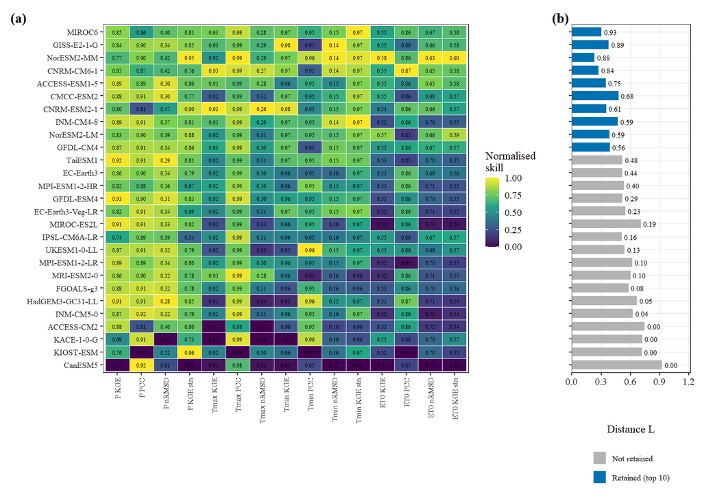

```r
hm <- copy(crit); hm[, score := 1 - d]
hm[, model := factor(model, levels = rev(CP$model))]
hm[, metric_lab := factor(paste0(c(pr = "P", tasmax = "Tmax", tasmin = "Tmin", ET0 = "ET0")[variable], " ", sub("KGE_station", "KGE stn", metric)),
                          levels = unique(paste0(rep(c("P", "Tmax", "Tmin", "ET0"), each = 4), " ", rep(c("KGE", "PCC", "nRMSD", "KGE stn"), 4))))]
p4a <- ggplot(hm, aes(metric_lab, model, fill = score)) + geom_tile(colour = "white", linewidth = 0.25) +
  geom_text(aes(label = sprintf("%.2f", value)), family = "serif", size = 1.55) +
  scale_fill_viridis_c(option = "viridis", name = "Normalised\nskill", limits = c(0, 1)) +
  labs(x = NULL, y = NULL, tag = "(a)") + theme(axis.text.x = element_text(size = 5.5, angle = 90, vjust = 0.5, hjust = 1, lineheight = 0.8),
                                               axis.text.y = element_text(size = 6))
cpp <- copy(CP); cpp[, model := factor(model, levels = rev(CP$model))]; cpp[, kept := rank <= NKEEP]
p4b <- ggplot(cpp, aes(L, model, fill = kept)) + geom_col(width = 0.7) +
  geom_text(aes(label = sprintf("%.2f", p_top10)), hjust = -0.2, family = "serif", size = 1.8) +
  scale_fill_manual(values = c(`TRUE` = "#0072B2", `FALSE` = "grey70"), labels = c(`TRUE` = "Retained (top 10)", `FALSE` = "Not retained"), name = NULL) +
  scale_x_continuous(expand = expansion(mult = c(0, 0.32))) + labs(x = "Distance L", y = NULL, tag = "(b)") +
  guides(fill = guide_legend(ncol = 1)) +
  theme(axis.text.y = element_blank(), legend.position = "bottom", legend.text = element_text(size = 6))
fig4 <- p4a + p4b + plot_layout(widths = c(4, 1.3))
save_fig(fig4, "Fig04_GCM_skill_ranking", IEEE2, 5); fig4
```

## 4.3 Quantile delta mapping and split-sample validation (Eq. 7)

NEX-GDDP-CMIP6 is already bias-adjusted (BCSD against GMFD), so QDM [41] targets the residual local bias relative to the station-informed gridded observations used here. QDM (MBC package, Cannon et al. 2015) was applied to each model **per variable, per grid cell and per calendar month**, as the methodology specifies: the quantile functions of each calendar month are estimated from that month’s 30 calibration values only (v2.2 Item 3, PREREGISTRATION.md). Trace handling for precipitation: trace 0.05 mm month⁻¹, jitter factor 0.01, ratio.max 2, all quantiles. The transforms are: - pr, rsds and sfcWind: multiplicative; - tasmax, tasmin and hurs: additive.

Two pooled-window variants are **sensitivities only**: (S1) the month and its two neighbours pooled after each month has been standardised by its own climatology, and (S2) the unstandardised ±1-month pooled window used in v2.1.

The calibration window is 1985–2014, and the future was corrected in three blocks (2015–2040, 2041–2070, 2071–2100). The targets are CHIRPS for P and ERA5-Land for the five Penman–Monteith variables; TerraClimate targets are a sensitivity run. Validation used a **plain split sample per calendar month** (calibration 1985–1999, validation 2000–2014 and the reverse; all 27 GCMs; regional series formed after cell-level correction) with the pre-registered acceptance criteria — (A) the mean over months of |median monthly bias| after correction is below raw for every variable, and (B) no calendar month has a precipitation |median bias| above 25 % — and, in addition, three schemes: 1. A **detrended split sample**: the linear trend was removed from observations and model, QDM was calibrated on 1985–1999 and applied to 2000–2014 (and the reverse), and the model trend was added back. This avoids penalising the correction for the observed warming between the two halves. 2. **Odd/even-year cross-validation.** 3. A **pseudo-reality test**: each retained GCM serves in turn as “truth” for the others, which tests the corrected 2071–2100 SSP5-8.5 distribution.

The reported metrics are quantile bias, Kolmogorov–Smirnov distance, wet-month frequency bias and drought-frequency bias.

```r
ISI_MODELS <- c("GFDL-ESM4", "IPSL-CM6A-LR", "MPI-ESM1-2-HR", "MRI-ESM2-0", "UKESM1-0-LL")
# v2.1 (Phase B): QDM/projections for the primary top 10, the old (TerraClimate-referenced) top 10, the ISIMIP3b GCMs and
# every model with scenario data ("all models" sensitivity)
TOP_OLD <- intersect(unlist(cfg$ensemble$sensitivity_set_old), MODELS)
SCEN_AVAIL <- MODELS[sapply(MODELS, function(m) all(file.exists(file.path(GCMF, paste0(m, "_", SCEN, ".nc")))))]
QDM_MODELS <- sort(union(union(TOP, TOP_OLD), union(intersect(ISI_MODELS, MODELS), SCEN_AVAIL)))   # sorted: independent of the ranking
if (DEV) QDM_MODELS <- TOP
GCMS <- cached("gcm_scen", sapply(QDM_MODELS, function(m) setNames(lapply(SCEN, function(s) read_gcm_exp(m, s)), SCEN), simplify = FALSE))
miss_scen <- names(which(sapply(GCMS, function(z) any(sapply(z, is.null)))))
if (length(miss_scen)) stop("Scenario files missing for: ", paste(miss_scen, collapse = ", "), " (run 01a phase B and 02b first)")
for (m in QDM_MODELS) GCM[[m]][SCEN] <- GCMS[[m]]
# v2.1 (Phase B) source-data fix: NEX-GDDP-CMIP6 v2.0 files with a step between the historical (to 2014) and scenario (from
# 2015) series (scripts/03_check_scenario_discontinuity.R: |robust z| > 5 across models; CNRM-CM6-1 and CNRM-ESM2-1 sfcWind,
# -31 to -34% in one year at NASA). The scenario series is rescaled per cell and calendar month so that its 2015-2034 mean equals
# the model's 1995-2014 mean; changes after 2015-2034 are kept. Sensitivity: Table S6 set without these models.
source(file.path(ROOT, "scripts", "03_check_scenario_discontinuity.R"), local = new.env())   # writes the check table
```

```
##               model variable    change         z   flag
##              <char>   <char>     <num>     <num> <lgcl>
## 1:       CNRM-CM6-1  sfcWind -33.59658 -10.91634   TRUE
## 2:      CNRM-ESM2-1  sfcWind -30.94994 -10.03880   TRUE
## 3: EC-Earth3-Veg-LR  sfcWind -33.84609 -10.99906   TRUE
## models checked: 27
##    variable median_change   mad
##      <char>         <num> <num>
## 1:       pr          1.72 11.08
## 2:   tasmax          0.50  0.60
## 3:   tasmin          0.46  0.35
## 4:     hurs         -0.23  1.43
## 5:     rsds         -0.32  0.67
## 6:  sfcWind         -0.67  2.03
```

```r
DISC <- fread(file.path(ROOT, "06_gcm_eval", "scenario_discontinuity_check.csv"))[flag == TRUE & model %in% QDM_MODELS]
for (k in seq_len(nrow(DISC))) { m <- DISC$model[k]; v <- DISC$variable[k]
  h <- GCM[[m]]$historical[[v]]; ih <- YR_H >= 1995 & YR_H <= 2014; i0 <- YR_F >= 2015 & YR_F <= 2034
  FAC <- sapply(1:12, function(mo) colMeans(h[ih & MON_H == mo, , drop = FALSE]) / colMeans(GCM[[m]]$ssp245[[v]][i0 & MON_F == mo, , drop = FALSE]))   # [cell x month], from SSP2-4.5, same for both SSPs
  for (s in SCEN) { x <- GCM[[m]][[s]][[v]]
    for (mo in 1:12) x[MON_F == mo, ] <- sweep(x[MON_F == mo, , drop = FALSE], 2, FAC[, mo], "*")
    GCM[[m]][[s]][[v]] <- x } }
KEY$discontinuity_factor_mean <- if (nrow(DISC)) DISC[, .(model, variable, change_pct = change)] else NULL
KEY$discontinuity_fix <- DISC
FILLED <- rbindlist(lapply(QDM_MODELS, function(m) rbindlist(lapply(names(GCM[[m]]), function(e)
  data.table(model = m, exp = e, t(attr(GCM[[m]][[e]], "n_filled")))))))[pr + tasmax + tasmin + hurs + rsds + sfcWind > 0]
KEY$gcm_filled_values <- FILLED
if (nrow(FILLED)) knitr::kable(FILLED, caption = "Model values filled from adjacent years (missing at the source)")
```

Model values filled from adjacent years (missing at the source)

| model | exp | pr | tasmax | tasmin | hurs | rsds | sfcWind |
| --- | --- | --- | --- | --- | --- | --- | --- |
| KIOST-ESM | ssp245 | 0 | 0 | 0 | 684 | 0 | 0 |

```r
TARGET <- list(pr = OBS$chirps_pr, tasmax = OBS$e5_tasmax, tasmin = OBS$e5_tasmin, hurs = OBS$e5_hurs, rsds = OBS$e5_rsds, sfcWind = OBS$e5_sfcWind)
TARGET_TC <- list(pr = OBS$chirps_pr, tasmax = OBS$tc_tasmax, tasmin = OBS$tc_tasmin, hurs = OBS$tc_hurs, rsds = OBS$tc_rsds, sfcWind = OBS$tc_sfcWind)
RATIO <- c(pr = TRUE, tasmax = FALSE, tasmin = FALSE, hurs = FALSE, rsds = TRUE, sfcWind = TRUE)
source(file.path(ROOT, "scripts", "R", "qdm_helpers.R"))   # qdm1, NB3, QDM_METHODS, mclim, qdm_cell (v2.2 Item 3)
BLOCKS <- list(c(2015, 2040), c(2041, 2070), c(2071, 2100))
run_qdm <- function(models, target, method = "permonth", tag = "") {
  ob <- YR_OBS >= BASE[1] & YR_OBS <= BASE[2]; hb <- YR_H >= BASE[1] & YR_H <= BASE[2]
  sapply(models, function(mdl) {
    logp("QDM", tag, method, mdl); set.seed(model_seed(mdl))
    out <- list(historical = list(), ssp245 = list(), ssp585 = list())
    for (v in VARS6) {
      H <- GCM[[mdl]]$historical[[v]]; Hc <- H
      Fc <- lapply(SCEN, function(s) GCM[[mdl]][[s]][[v]]); names(Fc) <- SCEN
      for (j in seq_len(ncol(H))) {
        cq <- function(x, xm) qdm_cell(target[[v]][ob, j], MON_OBS[ob], H[hb, j], MON_H[hb], x, xm, RATIO[[v]], method)
        Hc[, j] <- cq(H[, j], MON_H)
        for (s in SCEN) for (b in BLOCKS) { ib <- YR_F >= b[1] & YR_F <= b[2]; Fc[[s]][ib, j] <- cq(GCM[[mdl]][[s]][[v]][ib, j], MON_F[ib]) }
      }
      out$historical[[v]] <- Hc; for (s in SCEN) out[[s]][[v]] <- Fc[[s]]
    }
    for (e in names(out)) { out[[e]]$hurs <- pmin(pmax(out[[e]]$hurs, 1), 100)
      bad <- out[[e]]$tasmin > out[[e]]$tasmax - 0.1; out[[e]]$tasmin[bad] <- out[[e]]$tasmax[bad] - 0.1 }
    out
  }, simplify = FALSE)
}
# all runs cover every model with scenario data, so that none depends on the Item 4 selection
model_seed <- function(mdl) SEED + match(mdl, sort(MODELS))                                   # per-model RNG stream
QDMX    <- cached("qdm_corrected_permonth", run_qdm(QDM_MODELS, TARGET, "permonth", "main"))          # PRIMARY: per calendar month
QDMX_S1 <- cached("qdm_corrected_pooled_std", run_qdm(QDM_MODELS, TARGET, "pooled_std", "S1"))       # sensitivity S1: standardised ±1-month window
QDMX_S2 <- cached("qdm_corrected_pooled", run_qdm(QDM_MODELS, TARGET, "pooled", "S2"))               # sensitivity S2: v2.1 ±1-month window
QDMX_TC <- cached("qdm_corrected_tc_permonth", run_qdm(QDM_MODELS, TARGET_TC, "permonth", "terraclimate"))   # sensitivity: TerraClimate PM targets
TOPH <- substr(digest::digest(sort(TOP)), 1, 8)                                                     # cache-key suffix of results that depend on TOP

# ---- QDM validation (v2 item 6): (i) detrended split sample, (ii) odd/even-year cross-validation, (iii) pseudo-reality ----
# Metrics on validation-period values, per cell (every 3rd analysis cell) and calendar month, then averaged:
#   quantile bias (Q10, Q50, Q90; % for multiplicative variables, absolute otherwise), Kolmogorov-Smirnov distance,
#   and for precipitation the wet-month frequency bias (P >= 5 mm month-1; monthly data, so wet MONTHS replace wet days)
#   and the drought-frequency bias (3-month totals within a year below the validation-truth 15.87th percentile of the
#   same end-month, i.e. SPI-3 <= -1; truth frequency is 15.87%).
VCELLS <- seq(1, nrow(ANA), by = 3)
qdm_vec <- function(o, Oy, Om, h, Hy, Hm, x, Xm, cal, ratio, method = QDM_METHODS[["primary"]], ...)   # QDM of x calibrated on cal years
  qdm_cell(o[Oy %in% cal], Om[Oy %in% cal], h[Hy %in% cal], Hm[Hy %in% cal], x, Xm, ratio, method, ...)
detrend <- function(x, y, m, ratio, yrs, t0 = yrs[1]) {                    # trend and climatology fitted on yrs ONLY (calibration
  i <- y %in% yrs; t <- (y + (m - 0.5) / 12) - t0                           # half), so nothing of the validation half leaks in
  cl <- tapply(x[i], m[i], mean)[as.character(m)]
  a <- if (ratio) x / pmax(cl, 1e-6) else x - cl                           # relative (ratio vars) or absolute anomaly
  b <- coef(lm(a[i] ~ t[i]))[2]
  tr <- if (ratio) (1 + b * t) else b * t
  list(x = if (ratio) x / pmax(tr, 0.2) else x - tr, tr = tr)
}
ks_stat2 <- function(a, b) { a <- a[!is.na(a)]; b <- b[!is.na(b)]; z <- sort(unique(c(a, b))); max(abs(ecdf(a)(z) - ecdf(b)(z))) }   # = ks.test()$statistic
vmetrics <- function(tru, sim, m, v) {
  rel <- RATIO[[v]]; qs <- c(0.1, 0.5, 0.9)
  qb <- sapply(qs, function(p) mean(sapply(1:12, function(k) { a <- quantile(tru[m == k], p, na.rm = TRUE); b <- quantile(sim[m == k], p, na.rm = TRUE)
    if (rel) 100 * (b - a) / max(a, 0.1) else b - a })))
  ks <- mean(sapply(1:12, function(k) ks_stat2(tru[m == k], sim[m == k])))
  out <- c(q10_bias = qb[1], q50_bias = qb[2], q90_bias = qb[3], KS = ks, wet_bias = NA_real_, drought_bias = NA_real_)
  if (v == "pr") {
    out["wet_bias"] <- 100 * (mean(sim >= 5) - mean(tru >= 5))
    yy <- rep(seq_len(length(tru) / 12), each = 12)
    s3 <- function(z) ave(z, yy, FUN = function(w) as.numeric(stats::filter(w, rep(1, 3), sides = 1)))
    T3 <- s3(tru); S3 <- s3(sim)
    out["drought_bias"] <- 100 * mean(sapply(3:12, function(k) { q <- quantile(T3[m == k], 0.1587, na.rm = TRUE); mean(S3[m == k] < q, na.rm = TRUE) })) - 15.87
  }
  out
}
VAL <- cached(paste0("qdm_validation_v2_2_", TOPH), { set.seed(SEED)   # v2.2: primary per-month QDM
  res <- list(); yb <- BASE[1]:BASE[2]; ob <- YR_OBS %in% yb; hb <- YR_H %in% yb
  for (mdl in TOP) for (v in VARS6) for (j in VCELLS) {
    o <- TARGET[[v]][ob, j]; Oy <- YR_OBS[ob]; Om <- MON_OBS[ob]; h <- GCM[[mdl]]$historical[[v]][hb, j]; Hy <- YR_H[hb]; Hm <- MON_H[hb]
    # (i) detrended split sample, both directions
    for (sp in list(list(cal = 1985:1999, val = 2000:2014, lab = "detrended split (cal 1985–99)"), list(cal = 2000:2014, val = 1985:1999, lab = "detrended split (cal 2000–14)"))) {
      od <- detrend(o, Oy, Om, RATIO[[v]], sp$cal, yb[1]); hd <- detrend(h, Hy, Hm, RATIO[[v]], sp$cal, yb[1])   # v2.1: no leakage
      iv <- Hy %in% sp$val; ov <- Oy %in% sp$val
      cv <- qdm_vec(od$x, Oy, Om, hd$x, Hy, Hm, hd$x[iv], Hm[iv], sp$cal, RATIO[[v]])
      cv <- if (RATIO[[v]]) cv * pmax(hd$tr[iv], 0.2) else cv + hd$tr[iv]                     # add the model trend back
      res[[length(res) + 1]] <- data.table(scheme = sp$lab, model = mdl, variable = v, cell = j, stage = c("raw", "QDM"),
                                           rbind(vmetrics(o[ov], h[iv], Hm[iv], v), vmetrics(o[ov], cv, Hm[iv], v)))
    }
    # (ii) odd / even years
    for (sp in list(list(cal = yb[yb %% 2 == 1], val = yb[yb %% 2 == 0], lab = "odd/even (cal odd)"), list(cal = yb[yb %% 2 == 0], val = yb[yb %% 2 == 1], lab = "odd/even (cal even)"))) {
      iv <- Hy %in% sp$val; ov <- Oy %in% sp$val
      cv <- qdm_vec(o, Oy, Om, h, Hy, Hm, h[iv], Hm[iv], sp$cal, RATIO[[v]])
      res[[length(res) + 1]] <- data.table(scheme = sp$lab, model = mdl, variable = v, cell = j, stage = c("raw", "QDM"),
                                           rbind(vmetrics(o[ov], h[iv], Hm[iv], v), vmetrics(o[ov], cv, Hm[iv], v)))
    }
  }
  # (iii) pseudo-reality: model T is "truth"; model M (raw) is corrected to T over 1985-2014; corrected 2071-2100 SSP5-8.5 vs T's own 2071-2100
  ff <- YR_F >= 2071 & YR_F <= 2100
  for (tm in TOP) for (mdl in setdiff(TOP, tm)) for (v in VARS6) for (j in VCELLS) {
    o <- GCM[[tm]]$historical[[v]][hb, j]; tru <- GCM[[tm]]$ssp585[[v]][ff, j]
    h <- GCM[[mdl]]$historical[[v]][hb, j]; x <- GCM[[mdl]]$ssp585[[v]][ff, j]
    cv <- qdm_vec(o, YR_H[hb], MON_H[hb], h, YR_H[hb], MON_H[hb], x, MON_F[ff], yb, RATIO[[v]])
    res[[length(res) + 1]] <- data.table(scheme = "pseudo-reality (2071–2100, SSP5-8.5)", model = paste(mdl, "→", tm), variable = v, cell = j,
                                         stage = c("raw", "QDM"), rbind(vmetrics(tru, x, MON_F[ff], v), vmetrics(tru, cv, MON_F[ff], v)))
  }
  rbindlist(res)
})
VAL[, scheme_group := sub(" \\(.*", "", scheme)]
fwrite(VAL, file.path(ROOT, "07_bias_correction", "qdm_validation_v2_cells.csv"))
VS <- VAL[, .(q10_abs = mean(abs(q10_bias)), q50_abs = mean(abs(q50_bias)), q90_abs = mean(abs(q90_bias)), KS = mean(KS),
              wet_bias = mean(wet_bias), drought_bias = mean(drought_bias)), by = .(scheme_group, variable, stage)]
KEY$qdm_validation_v2 <- VS
fwrite(VS, file.path(ROOT, "07_bias_correction", "qdm_validation_v2_summary.csv"))
TS1 <- dcast(VS, scheme_group + variable ~ stage, value.var = c("q50_abs", "q90_abs", "KS", "drought_bias"))
save_table(TS1, "S1", "QDM validation: detrended split sample, odd/even-year cross-validation and pseudo-reality (raw vs QDM)",
           "TableS1_QDM_validation_v2", note = "Mean absolute quantile bias (% for P, Rs, wind; °C or %-points otherwise), mean Kolmogorov–Smirnov distance and P drought-frequency bias (%-points; SPI-3 ≤ −1 equivalent), averaged over the retained models, every third 0.25° cell and calendar months.", digits = 2)
```

TABLE S1 QDM VALIDATION: DETRENDED SPLIT SAMPLE, ODD/EVEN-YEAR CROSS-VALIDATION AND PSEUDO-REALITY (RAW VS QDM)

| scheme_group | variable | q50_abs_QDM | q50_abs_raw | q90_abs_QDM | q90_abs_raw | KS_QDM | KS_raw | drought_bias_QDM | drought_bias_raw |
| --- | --- | --- | --- | --- | --- | --- | --- | --- | --- |
| detrended split | hurs | 6.51 | 16.96 | 5.22 | 16.26 | 0.53 | 0.83 |  |  |
| detrended split | pr | 27.67 | 24.23 | 28.81 | 75.03 | 0.47 | 0.36 | 23.64 | 6.59 |
| detrended split | rsds | 5.33 | 16.53 | 3.95 | 13.76 | 0.46 | 0.82 |  |  |
| detrended split | sfcWind | 4.10 | 107.53 | 4.60 | 106.92 | 0.41 | 1.00 |  |  |
| detrended split | tasmax | 1.30 | 2.00 | 1.35 | 1.91 | 0.51 | 0.60 |  |  |
| detrended split | tasmin | 0.58 | 0.62 | 0.63 | 0.59 | 0.44 | 0.45 |  |  |
| odd/even | hurs | 0.82 | 17.14 | 1.00 | 15.70 | 0.34 | 0.83 |  |  |
| odd/even | pr | 23.12 | 23.55 | 25.52 | 80.89 | 0.43 | 0.37 | 5.42 | 6.85 |
| odd/even | rsds | 1.22 | 16.59 | 0.94 | 13.52 | 0.34 | 0.82 |  |  |
| odd/even | sfcWind | 1.01 | 107.59 | 1.19 | 106.72 | 0.33 | 1.00 |  |  |
| odd/even | tasmax | 0.22 | 1.96 | 0.44 | 1.78 | 0.36 | 0.59 |  |  |
| odd/even | tasmin | 0.19 | 0.61 | 0.43 | 0.60 | 0.36 | 0.44 |  |  |
| pseudo-reality | hurs | 2.20 | 2.10 | 2.03 | 2.09 | 0.36 | 0.33 |  |  |
| pseudo-reality | pr | 190.51 | 114.20 | 26.06 | 20.77 | 0.33 | 0.30 | 5.78 | 6.46 |
| pseudo-reality | rsds | 0.69 | 0.64 | 0.49 | 0.83 | 0.34 | 0.31 |  |  |
| pseudo-reality | sfcWind | 6.09 | 5.65 | 7.15 | 7.93 | 0.43 | 0.42 |  |  |
| pseudo-reality | tasmax | 1.05 | 1.08 | 1.06 | 1.11 | 0.38 | 0.37 |  |  |
| pseudo-reality | tasmin | 0.87 | 0.87 | 1.03 | 1.03 | 0.43 | 0.42 |  |  |

Mean absolute quantile bias (% for P, Rs, wind; °C or %-points otherwise), mean Kolmogorov–Smirnov distance and P drought-frequency bias (%-points; SPI-3 ≤ −1 equivalent), averaged over the retained models, every third 0.25° cell and calendar months.

```r
KEY$qdm_split <- VS[scheme_group == "detrended split", .(variable, stage, mean_abs_bias = q50_abs, q90_abs_bias = q90_abs, KS)]
# ---- v2.2 Item 3: plain split sample per calendar month, all GCMs, regional series after cell-level correction ----
# Pre-registered acceptance (cal 1985-1999 -> val 2000-2014): (A) per variable, mean over months of the GCM-mean |median monthly
# bias| is below raw; (B) pr: no month with GCM-mean |median bias| > 25 %. Reading (ii) |GCM-mean signed bias| is reported only.
PSPLIT <- cached("qdm_plain_split_permonth", { res <- list()
  yb <- BASE[1]:BASE[2]; ob <- YR_OBS %in% yb; hb <- YR_H %in% yb; Oy <- YR_OBS[ob]; Om <- MON_OBS[ob]; Hy <- YR_H[hb]; Hm <- MON_H[hb]
  for (mdl in QDM_MODELS) { logp("plain split", mdl); set.seed(model_seed(mdl)); for (v in VARS6) {
    O <- TARGET[[v]][ob, , drop = FALSE]; H <- GCM[[mdl]]$historical[[v]][hb, , drop = FALSE]
    for (sp in list(list(cal = 1985:1999, val = 2000:2014), list(cal = 2000:2014, val = 1985:1999))) {
      iv <- Hy %in% sp$val; ov <- Oy %in% sp$val; oreg <- wmean(O[ov, , drop = FALSE], W_REG); sims <- list(raw = wmean(H[iv, , drop = FALSE], W_REG))
      for (mt in names(QDM_METHODS)) { C <- H[iv, , drop = FALSE]
        for (j in seq_len(ncol(H))) C[, j] <- qdm_vec(O[, j], Oy, Om, H[, j], Hy, Hm, H[iv, j], Hm[iv], sp$cal, RATIO[[v]], QDM_METHODS[[mt]])
        sims[[mt]] <- wmean(C, W_REG) }
      a <- sapply(1:12, function(k) median(oreg[Om[ov] == k]))
      for (st in names(sims)) { b <- sapply(1:12, function(k) median(sims[[st]][Hm[iv] == k]))
        res[[length(res) + 1]] <- data.table(model = mdl, variable = v, cal = paste(range(sp$cal), collapse = "–"), stage = st, month = 1:12,
          obs_median = a, sim_median = b, bias = if (RATIO[[v]]) 100 * (b - a) / pmax(a, 0.1) else b - a) } } } }
  rbindlist(res) })
PSPLIT[, stage := factor(stage, levels = c("raw", names(QDM_METHODS)))]
PSM <- PSPLIT[, .(mean_abs = mean(abs(bias)), abs_mean = abs(mean(bias)), signed = mean(bias), n_models = .N), by = .(variable, cal, stage, month)]
fwrite(PSPLIT, file.path(ROOT, "07_bias_correction", "qdm_plain_split_permonth_models.csv")); fwrite(PSM, file.path(ROOT, "07_bias_correction", "qdm_plain_split_permonth.csv"))
ACC <- PSM[, .(A_mean_abs = mean(mean_abs), A_abs_mean = mean(abs_mean), max_month = max(mean_abs), max_month_name = month.abb[month[which.max(mean_abs)]],
              max_month_ii = max(abs_mean), oct_mean_abs = mean_abs[month == 10], n_models = max(n_models)), by = .(variable, cal, stage)]
ACC[, A_raw := A_mean_abs[stage == "raw"], by = .(variable, cal)][, A_raw_ii := A_abs_mean[stage == "raw"], by = .(variable, cal)]
ACC[, `:=`(pass_A = A_mean_abs < A_raw, pass_A_ii = A_abs_mean < A_raw_ii, pass_B = if (variable[1] == "pr") max_month <= 25 else NA,
           pass_B_ii = if (variable[1] == "pr") max_month_ii <= 25 else NA), by = .(variable, cal, stage)]
ACC[, binding := cal == "1985–1999"]
KEY$qdm_acceptance <- ACC
KEY$qdm_acceptance_primary <- list(pass_A_all = ACC[binding & stage == "primary", all(pass_A)], pass_B = ACC[binding & stage == "primary" & variable == "pr", pass_B],
                                   failed_A = ACC[binding & stage == "primary" & !pass_A, variable])
fwrite(ACC, file.path(ROOT, "07_bias_correction", "qdm_acceptance_criteria.csv"))
TS1B <- dcast(PSM, variable + cal + month ~ stage, value.var = "mean_abs")[, month := month.abb[month]]
save_table(TS1B, "S1b", "Plain split sample per calendar month: GCM-mean |median monthly bias| of the regional series, raw and after QDM (primary per month; S1 standardised and S2 unstandardised ±1-month windows)",
           "TableS1b_QDM_plain_split_permonth", note = "All GCMs with scenario data; validation half = the years not used for calibration. % for P, Rs and wind; °C for Tmax/Tmin; %-points for RH. October is row Oct. Acceptance (pre-registered, cal 1985–1999): (A) mean over months below raw for each variable; (B) no P month above 25 %.", digits = 1)
```

TABLE S1b PLAIN SPLIT SAMPLE PER CALENDAR MONTH: GCM-MEAN |MEDIAN MONTHLY BIAS| OF THE REGIONAL SERIES, RAW AND AFTER QDM (PRIMARY PER MONTH; S1 STANDARDISED AND S2 UNSTANDARDISED ±1-MONTH WINDOWS)

| variable | cal | month | raw | primary | S1 | S2 |
| --- | --- | --- | --- | --- | --- | --- |
| hurs | 1985–1999 | Jan | 25.4 | 1.6 | 2.9 | 4.0 |
| hurs | 1985–1999 | Feb | 22.3 | 0.9 | 1.9 | 1.0 |
| hurs | 1985–1999 | Mar | 26.1 | 4.5 | 5.4 | 4.8 |
| hurs | 1985–1999 | Apr | 30.2 | 8.9 | 8.9 | 9.9 |
| hurs | 1985–1999 | May | 26.3 | 10.5 | 9.0 | 11.6 |
| hurs | 1985–1999 | Jun | 10.3 | 2.2 | 2.5 | 2.8 |
| hurs | 1985–1999 | Jul | 2.1 | 4.1 | 3.3 | 3.6 |
| hurs | 1985–1999 | Aug | 7.3 | 5.8 | 6.1 | 4.6 |
| hurs | 1985–1999 | Sep | 12.4 | 6.2 | 6.2 | 5.7 |
| hurs | 1985–1999 | Oct | 22.7 | 5.6 | 5.5 | 6.9 |
| hurs | 1985–1999 | Nov | 19.7 | 2.8 | 2.9 | 2.7 |
| hurs | 1985–1999 | Dec | 21.8 | 5.8 | 4.7 | 2.4 |
| hurs | 2000–2014 | Jan | 24.5 | 1.5 | 1.6 | 1.5 |
| hurs | 2000–2014 | Feb | 21.8 | 1.1 | 1.4 | 2.4 |
| hurs | 2000–2014 | Mar | 21.7 | 4.3 | 4.8 | 3.9 |
| hurs | 2000–2014 | Apr | 21.5 | 8.5 | 9.4 | 9.9 |
| hurs | 2000–2014 | May | 15.0 | 11.3 | 11.2 | 8.2 |
| hurs | 2000–2014 | Jun | 9.0 | 3.4 | 3.1 | 11.0 |
| hurs | 2000–2014 | Jul | 4.8 | 4.3 | 5.8 | 4.8 |
| hurs | 2000–2014 | Aug | 2.1 | 5.6 | 5.0 | 6.0 |
| hurs | 2000–2014 | Sep | 6.0 | 6.2 | 6.2 | 6.0 |
| hurs | 2000–2014 | Oct | 16.1 | 5.7 | 5.8 | 3.7 |
| hurs | 2000–2014 | Nov | 17.3 | 2.9 | 2.7 | 3.6 |
| hurs | 2000–2014 | Dec | 14.6 | 7.2 | 7.5 | 8.0 |
| pr | 1985–1999 | Jan | 29.8 | 35.1 | 25.0 | 23.5 |
| pr | 1985–1999 | Feb | 22.1 | 30.6 | 21.5 | 20.0 |
| pr | 1985–1999 | Mar | 64.7 | 74.9 | 59.0 | 53.9 |
| pr | 1985–1999 | Apr | 31.1 | 29.6 | 21.8 | 25.1 |
| pr | 1985–1999 | May | 17.8 | 24.3 | 27.0 | 23.3 |
| pr | 1985–1999 | Jun | 24.8 | 20.8 | 20.1 | 24.4 |

[output cut: 114 more lines]

All GCMs with scenario data; validation half = the years not used for calibration. % for P, Rs and wind; °C for Tmax/Tmin; %-points for RH. October is row Oct. Acceptance (pre-registered, cal 1985–1999): (A) mean over months below raw for each variable; (B) no P month above 25 %.

```r
KEY$qdm_october <- PSM[month == 10]
for (k in seq_len(nrow(ACC))) { a <- ACC[k]; rl <- if (a$stage == "primary") "primary" else if (a$stage == "raw") "reference" else "sensitivity"
  add_variant("3", paste0(a$stage, " (cal ", a$cal, ")"), rl, paste0(a$variable, ": mean |median monthly bias|"), a$A_mean_abs)
  if (a$variable == "pr") add_variant("3", paste0(a$stage, " (cal ", a$cal, ")"), rl, "pr: max month |median bias|", a$max_month) }
# before/after over the full calibration period (regional)
BA <- rbindlist(lapply(TOP, function(mdl) rbindlist(lapply(VARS6, function(v) {
  o <- wmean(TARGET[[v]], W_REG)[YR_OBS >= BASE[1] & YR_OBS <= BASE[2]]
  r <- wmean(GCM[[mdl]]$historical[[v]], W_REG)[YR_H >= BASE[1] & YR_H <= BASE[2]]
  c2 <- wmean(QDMX[[mdl]]$historical[[v]], W_REG)[YR_H >= BASE[1] & YR_H <= BASE[2]]
  b <- function(s) if (RATIO[[v]]) 100 * (mean(s) - mean(o)) / mean(o) else mean(s) - mean(o)
  data.table(model = mdl, variable = v, raw = b(r), QDM = b(c2))
}))))
KEY$bias_before_after <- BA[, .(raw = mean(raw), QDM = mean(QDM), raw_range = paste(round(range(raw), 2), collapse = " to ")), by = variable]
fwrite(BA, file.path(ROOT, "07_bias_correction", "bias_before_after_1985_2014.csv"))
```

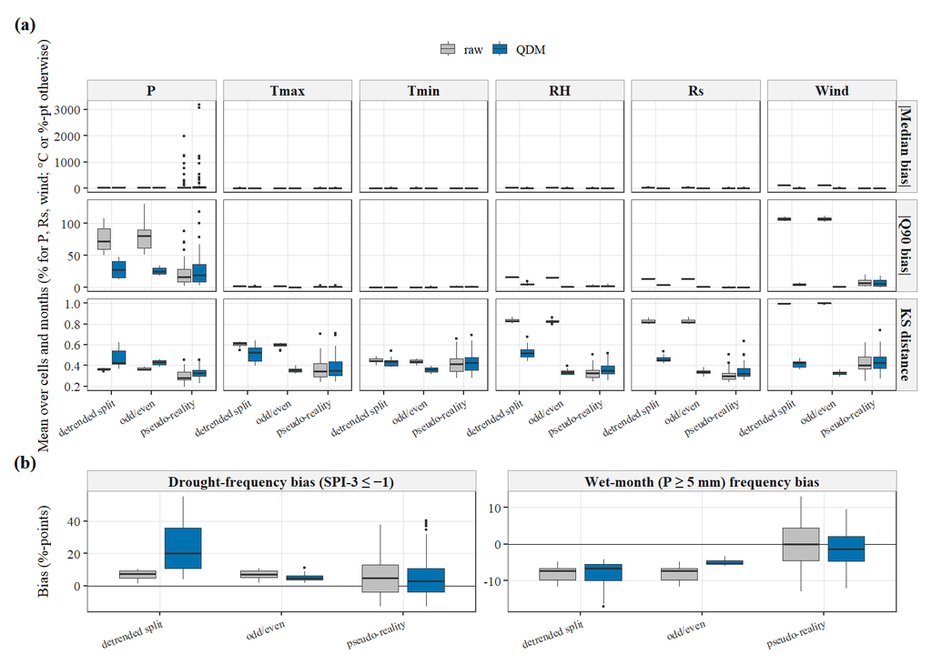

```r
vm <- VAL[, .(q50 = mean(abs(q50_bias)), q90 = mean(abs(q90_bias)), KS = mean(KS)), by = .(scheme_group, model, variable, stage)]
vm <- melt(vm, id.vars = c("scheme_group", "model", "variable", "stage"), variable.name = "metric")
vm[, stage := factor(stage, levels = c("raw", "QDM"))]
vm[, vlab := factor(c(pr = "P", tasmax = "Tmax", tasmin = "Tmin", hurs = "RH", rsds = "Rs", sfcWind = "Wind")[variable], levels = c("P", "Tmax", "Tmin", "RH", "Rs", "Wind"))]
vm[, mlab := factor(c(q50 = "|Median bias|", q90 = "|Q90 bias|", KS = "KS distance")[as.character(metric)], levels = c("|Median bias|", "|Q90 bias|", "KS distance"))]
vm[, scheme_group := factor(scheme_group, levels = c("detrended split", "odd/even", "pseudo-reality"))]
p5a <- ggplot(vm, aes(scheme_group, value, fill = stage)) +
  geom_boxplot(outlier.size = 0.3, linewidth = 0.25, width = 0.65, position = position_dodge(0.75)) +
  scale_fill_manual(values = c(raw = "grey75", QDM = "#0072B2"), name = NULL) +
  facet_grid(mlab ~ vlab, scales = "free_y") + labs(x = NULL, y = "Mean over cells and months (% for P, Rs, wind; °C or %-pt otherwise)", tag = "(a)") +
  theme(axis.text.x = element_text(angle = 30, hjust = 1, size = 6), legend.position = "top")
pd <- VAL[variable == "pr", .(wet = mean(wet_bias), drought = mean(drought_bias)), by = .(scheme_group, model, stage)]
pd <- melt(pd, id.vars = c("scheme_group", "model", "stage"), variable.name = "metric"); pd[, stage := factor(stage, levels = c("raw", "QDM"))]
pd[, metric := factor(c(wet = "Wet-month (P ≥ 5 mm) frequency bias", drought = "Drought-frequency bias (SPI-3 ≤ −1)")[as.character(metric)])]
p5b <- ggplot(pd, aes(scheme_group, value, fill = stage)) + geom_hline(yintercept = 0, linewidth = 0.3) +
  geom_boxplot(outlier.size = 0.3, linewidth = 0.25, width = 0.6, position = position_dodge(0.75), show.legend = FALSE) +
  scale_fill_manual(values = c(raw = "grey75", QDM = "#0072B2")) + facet_wrap(~metric, scales = "free_y") +
  labs(x = NULL, y = "Bias (%-points)", tag = "(b)") + theme(axis.text.x = element_text(angle = 20, hjust = 1, size = 6))
fig5 <- p5a / p5b + plot_layout(heights = c(2.4, 1))
save_fig(fig5, "Fig05_QDM_validation", IEEE2, 5.4); fig5
```

### 4.3.1 Why does QDM not reduce the out-of-sample precipitation median bias? (v2.1 diagnostic)

The leak-free detrended split was examined for precipitation with a diagnostic. The QDM configuration used for the projections was **not** changed on the basis of these results, because doing so would tune the correction on the validation half. The diagnostic:

- **Decomposes** the validation-period bias into the shift of the observations between the two halves (non-stationarity) and the shift of the raw model.
- **Separates** the dry season (October–May) from the monsoon (June–September).
- **Varies one QDM setting at a time** against the reference configuration, which is the primary method (Cannon et al. 2015 QDM per calendar month, trace 0.05 mm, jitter 0.01, all quantiles, ratio.max = 2). The settings tested are: the standardised ±1-month pooled window (S1), the unstandardised ±1-month pooled window (S2, v2.1), no ratio clipping (ratio.max = ∞), trace 1 mm and 30 quantiles.
- **Repeats the evaluation against detrended observations**, which isolates the distributional correction from the trend mismatch.

```r
medb <- function(tru, sim, m, months = 1:12) sapply(months, function(k) { a <- median(tru[m == k]); 100 * (median(sim[m == k]) - a) / max(a, 0.1) })
PDIAG <- cached(paste0("qdm_precip_diagnostics_v2_2_", TOPH), { set.seed(SEED)
  yb <- BASE[1]:BASE[2]; ob <- YR_OBS %in% yb; hb <- YR_H %in% yb; res <- list()
  VARIANTS <- list(reference = list(), `±1-month pooled, standardised (S1)` = list(method = "pooled_std"), `±1-month pooled (S2, v2.1)` = list(method = "pooled"), `no ratio clipping` = list(ratio.max = Inf),
                   `trace 1 mm` = list(trace = 1), `30 quantiles` = list(n.tau = 30))
  for (mdl in TOP) for (j in seq(1, nrow(ANA), by = 3)) {
    o <- TARGET$pr[ob, j]; Oy <- YR_OBS[ob]; Om <- MON_OBS[ob]; h <- GCM[[mdl]]$historical$pr[hb, j]; Hy <- YR_H[hb]; Hm <- MON_H[hb]
    for (sp in list(list(cal = 1985:1999, val = 2000:2014), list(cal = 2000:2014, val = 1985:1999))) {
      iv <- Hy %in% sp$val; ov <- Oy %in% sp$val; ic <- Hy %in% sp$cal; oc_ <- Oy %in% sp$cal
      od <- detrend(o, Oy, Om, TRUE, sp$cal, yb[1]); hd <- detrend(h, Hy, Hm, TRUE, sp$cal, yb[1])
      base <- data.table(model = mdl, cell = j, cal = paste(range(sp$cal), collapse = "–"), month = 1:12,
                         obs_shift = medb(o[oc_], o[ov], Om[ov]),                       # median(obs val) vs median(obs cal), %
                         mod_shift = medb(h[ic], h[iv], Hm[iv]),                         # median(model val) vs median(model cal), %
                         raw = medb(o[ov], h[iv], Hm[iv]))
      for (vn in names(VARIANTS)) { a <- VARIANTS[[vn]]
        cv <- do.call(qdm_vec, c(list(od$x, Oy, Om, hd$x, Hy, Hm, hd$x[iv], Hm[iv], sp$cal, TRUE), a))
        base[[vn]] <- medb(o[ov], cv * pmax(hd$tr[iv], 0.2), Hm[iv])                 # evaluation as in Table S1 (raw obs, model trend added)
        if (vn == "reference") base[["reference, detrended target"]] <- medb(od$x[ov], cv, Hm[iv]) }   # obs and model both detrended
      res[[length(res) + 1]] <- base } }
  rbindlist(res) })
PDIAG[, season := fifelse(month %in% 6:9, "monsoon (Jun–Sep)", "dry season (Oct–May)")]
vcols <- c("raw", "reference", "±1-month pooled, standardised (S1)", "±1-month pooled (S2, v2.1)", "no ratio clipping", "trace 1 mm", "30 quantiles", "reference, detrended target")
PD1 <- rbind(PDIAG[, c(list(season = "all months"), lapply(.SD, function(x) mean(abs(x)))), .SDcols = vcols],
             PDIAG[, lapply(.SD, function(x) mean(abs(x))), by = season, .SDcols = vcols])
PD2 <- PDIAG[, .(obs_shift = mean(obs_shift), mod_shift = mean(mod_shift), signed_raw = mean(raw), signed_qdm = mean(reference),
                 corr_obs_shift_vs_qdm_bias = cor(obs_shift, reference)), by = .(cal, season)]
KEY$qdm_precip_diag <- list(abs_median_bias = PD1, decomposition = PD2)
fwrite(PDIAG, file.path(ROOT, "07_bias_correction", "qdm_precip_diagnostics_cells.csv"))
fwrite(PD1, file.path(ROOT, "07_bias_correction", "qdm_precip_diagnostics_summary.csv")); fwrite(PD2, file.path(ROOT, "07_bias_correction", "qdm_precip_bias_decomposition.csv"))
knitr::kable(PD1, digits = 1, caption = "Precipitation |median bias| (%) in the validation half: raw, QDM reference and one-at-a-time variants (diagnostic only)")
```

Precipitation |median bias| (%) in the validation half: raw, QDM reference and one-at-a-time variants (diagnostic only)

| season | raw | reference | ±1-month pooled, standardised (S1) | ±1-month pooled (S2, v2.1) | no ratio clipping | trace 1 mm | 30 quantiles | reference, detrended target |
| --- | --- | --- | --- | --- | --- | --- | --- | --- |
| all months | 44.1 | 45.2 | 38.4 | 41.4 | 48.2 | 42.0 | 45.3 | 49.5 |
| dry season (Oct–May) | 52.8 | 50.3 | 41.9 | 45.3 | 54.8 | 45.7 | 50.5 | 56.7 |
| monsoon (Jun–Sep) | 26.8 | 34.9 | 31.3 | 33.8 | 35.0 | 34.7 | 34.8 | 35.2 |

```r
knitr::kable(PD2, digits = 2, caption = "Decomposition: median shift of observations and raw model between halves, signed bias raw vs QDM (%)")
```

Decomposition: median shift of observations and raw model between halves, signed bias raw vs QDM (%)

| cal | season | obs_shift | mod_shift | signed_raw | signed_qdm | corr_obs_shift_vs_qdm_bias |
| --- | --- | --- | --- | --- | --- | --- |
| 1985–1999 | dry season (Oct–May) | 5.86 | 22.24 | 30.49 | 25.21 | -0.40 |
| 1985–1999 | monsoon (Jun–Sep) | 28.48 | 22.64 | -1.75 | 0.74 | -0.33 |
| 2000–2014 | dry season (Oct–May) | 4.60 | 23.39 | 26.21 | -27.38 | -0.24 |
| 2000–2014 | monsoon (Jun–Sep) | -20.47 | -8.05 | 6.80 | -26.23 | -0.30 |

# 5 Future projections (III-F)

Each retained model’s corrected historical (1981–2014) and scenario (2015–2100) series were joined. Penman–Monteith ET₀ was recomputed from the corrected inputs, and every index was **calibrated on that model’s own 1985–2014 baseline**. Changes are relative to 1985–2014. A change is **robust** when at least 80% of the retained models agree on its sign **and** a Wilcoxon signed-rank test of the model changes rejects zero at p < 0.05. Ensemble means use the skill weights.

```r
model_series <- function(mdl, s, src = QDMX) {
  x <- lapply(VARS6, function(v) rbind(src[[mdl]]$historical[[v]], src[[mdl]][[s]][[v]])); names(x) <- VARS6
  mo <- c(MON_H, MON_F); yr <- c(YR_H, YR_F)
  list(x = x, months = mo, years = yr, dates = c(D_H, D_F),
       et_pm = gcm_et0(x, mo, "pm", days_in_month(c(D_H, D_F))), et_hg = gcm_et0(x, mo, "hg", days_in_month(c(D_H, D_F))))
}
SEL_FUN <- function(P, PET, months, years, ref = BASE, type = SEL_TYPE, k = SEL_K) {
  if (type == "SPI") std_index(P, k, "spi", ref = ref) else if (type == "SPEI") std_index(as.matrix(P) - as.matrix(PET), k, "spei", ref = ref)
  else rdi_st(P, PET, k, months, years, ref)
}
PROJ <- cached("projections", {
  sapply(QDM_MODELS, function(mdl) sapply(SCEN, function(s) {
    logp("projection", mdl, s)
    ms <- model_series(mdl, s)
    Preg <- wmean(ms$x$pr, W_REG); Ereg <- wmean(ms$et_pm, W_REG); Hreg <- wmean(ms$et_hg, W_REG)
    mr <- model_series(mdl, s, src = GCM)                       # NEX-GDDP as published (no QDM): sensitivity
    Praw <- wmean(mr$x$pr, W_REG); Eraw <- wmean(mr$et_pm, W_REG)
    list(months = ms$months, years = ms$years, dates = ms$dates,
         raw = list(P = Praw, ET0 = Eraw, sel = SEL_FUN(Praw, Eraw, ms$months, ms$years)[, 1]),
         reg = list(P = Preg, ET0 = Ereg, ET0_HG = Hreg, Tmax = wmean(ms$x$tasmax, W_REG), Tmin = wmean(ms$x$tasmin, W_REG),
                    idx = all_indices(Preg, Ereg, ms$months, ms$years),
                    sel_hg = SEL_FUN(Preg, Hreg, ms$months, ms$years, type = if (SEL_TYPE == "SPI") "SPEI" else SEL_TYPE),
                    spei_sel_pm = std_index(Preg - Ereg, SEL_K, "spei"),
                    sel_alt = SEL_FUN(Preg, Ereg, ms$months, ms$years, ref = BASE_ALT)),
         cell_sel = SEL_FUN(ms$x$pr, ms$et_pm, ms$months, ms$years),
         cell_spei12 = std_index(ms$x$pr - ms$et_pm, 12, "spei"),
         cellP = ms$x$pr, cellE = ms$et_pm)
  }, simplify = FALSE), simplify = FALSE)
})
per_metrics <- function(pr, per, idx = NULL, thr = THR) {
  i <- pr$years >= per[1] & pr$years <= per[2]
  x <- if (is.null(idx)) pr$reg$idx[[paste0(SEL_TYPE, SEL_K)]][, 1] else idx
  cs <- char_summary(x, pr$dates, pr$years, per, thr)
  cbind(cs, P = sum(pr$reg$P[i]) / (per[2] - per[1] + 1), ET0 = sum(pr$reg$ET0[i]) / (per[2] - per[1] + 1),
        WB = sum(pr$reg$P[i] - pr$reg$ET0[i]) / (per[2] - per[1] + 1), Tmax = mean(pr$reg$Tmax[i]))
}
CHG_ALL <- rbindlist(lapply(QDM_MODELS, function(mdl) rbindlist(lapply(SCEN, function(s) {
  pr <- PROJ[[mdl]][[s]]; b <- per_metrics(pr, BASE)
  rbindlist(lapply(c("near", "mid", "far"), function(p) { f <- per_metrics(pr, PERIODS[[p]])
    data.table(model = mdl, scenario = s, period = p, d_freq = f$freq_pct - b$freq_pct, d_epd = f$events_per_decade - b$events_per_decade,
               d_D = f$D_mean - b$D_mean, d_S = f$S_mean - b$S_mean, d_I = f$I_mean - b$I_mean, d_Dmax = f$D_max - b$D_max,
               d_P = 100 * (f$P - b$P) / b$P, d_ET0 = 100 * (f$ET0 - b$ET0) / b$ET0, d_WB = f$WB - b$WB, d_Tmax = f$Tmax - b$Tmax,
               base_freq = b$freq_pct, base_D = b$D_mean, base_S = b$S_mean, base_I = b$I_mean) }))
}))))
CHG <- CHG_ALL[model %in% TOP]                                   # primary ensemble
robust <- function(d) { d <- d[!is.na(d)]; agree <- max(mean(d > 0), mean(d < 0))
  p <- tryCatch(wilcox.test(d, mu = 0, exact = FALSE)$p.value, error = function(e) NA)
  c(agree = agree, p = p, robust = as.numeric(agree >= cfg$ensemble$robust_agreement & !is.na(p) & p < cfg$ensemble$robust_alpha)) }
ens <- function(dt, keys) {
  vars <- grep("^d_", names(dt), value = TRUE)
  dt[, {
    w <- WTS[model] / sum(WTS[model])
    rbindlist(lapply(vars, function(v) { x <- get(v); rb <- robust(x)
      data.table(metric = v, wmean = sum(w * x, na.rm = TRUE), p10 = quantile(x, 0.1, na.rm = TRUE), p90 = quantile(x, 0.9, na.rm = TRUE),
                 agree = rb["agree"], wilcox_p = rb["p"], robust = rb["robust"] == 1) }))
  }, by = keys]
}
ENS <- ens(CHG, c("scenario", "period"))
fwrite(CHG, file.path(ROOT, "08_projections", "regional_changes_by_model.csv")); fwrite(ENS, file.path(ROOT, "08_projections", "regional_changes_ensemble.csv"))
KEY$ens_changes <- ENS
BASEV <- CHG[, .(freq = mean(base_freq), D = mean(base_D), S = mean(base_S), I = mean(base_I)), by = model]
KEY$model_baseline_char <- BASEV[, lapply(.SD, mean), .SDcols = -"model"]
```

```r
# Where in the year does the change occur? Frequency of SEL <= -1 by season of the index end month, plus the
# December value (end of the Oct-Dec wheat-sowing window, the index month selected by the yield correlation).
SEAS <- c(DJF = 12, DJF = 1, DJF = 2, MAM = 3, MAM = 4, MAM = 5, JJA = 6, JJA = 7, JJA = 8, SON = 9, SON = 10, SON = 11)
seas_of <- function(m) names(SEAS)[match(m, SEAS)]
SC <- rbindlist(lapply(TOP, function(mdl) rbindlist(lapply(SCEN, function(s) { pr <- PROJ[[mdl]][[s]]
  x <- pr$reg$idx[[paste0(SEL_TYPE, SEL_K)]][, 1]; se <- seas_of(pr$months)
  fr <- function(per, sel) 100 * mean(x[pr$years >= per[1] & pr$years <= per[2] & sel] <= THR, na.rm = TRUE)
  mP <- function(per, mm) mean(pr$reg$P[pr$years >= per[1] & pr$years <= per[2] & pr$months %in% mm])
  mE <- function(per, mm) mean(pr$reg$ET0[pr$years >= per[1] & pr$years <= per[2] & pr$months %in% mm])
  rbindlist(lapply(c("mid", "far"), function(p) rbindlist(lapply(c("DJF", "MAM", "JJA", "SON", "Dec (sowing)"), function(g) {
    sel <- if (g == "Dec (sowing)") pr$months == 12 else se == g
    mm <- if (g == "Dec (sowing)") 10:12 else SEAS[names(SEAS) == g]
    data.table(model = mdl, scenario = s, period = p, season = g, d_freq = fr(PERIODS[[p]], sel) - fr(BASE, sel),
               d_P = 100 * (mP(PERIODS[[p]], mm) / mP(BASE, mm) - 1), d_ET0 = 100 * (mE(PERIODS[[p]], mm) / mE(BASE, mm) - 1)) }))))
}))))
SCE <- SC[, { w <- WTS[model] / sum(WTS[model]); rb <- robust(d_freq)
  .(d_freq = sum(w * d_freq), d_P = sum(w * d_P), d_ET0 = sum(w * d_ET0), agree = rb["agree"], wilcox_p = rb["p"], robust = rb["robust"] == 1) }, by = .(scenario, period, season)]
KEY$seasonal_changes <- SCE
fwrite(SCE, file.path(ROOT, "08_projections", "seasonal_changes_ensemble.csv"))
knitr::kable(SCE, digits = 1, caption = paste0("Seasonal change in ", SEL_NAME, " drought frequency (%-pt) and in P and ET0 (%) of the corresponding months"))
```

Seasonal change in SPEI-3 drought frequency (%-pt) and in P and ET0 (%) of the corresponding months

| scenario | period | season | d_freq | d_P | d_ET0 | agree | wilcox_p | robust |
| --- | --- | --- | --- | --- | --- | --- | --- | --- |
| ssp245 | mid | DJF | 11.0 | 3.4 | 8.9 | 0.7 | 0.1 | FALSE |
| ssp245 | mid | MAM | 15.2 | -2.8 | 6.9 | 0.7 | 0.0 | FALSE |
| ssp245 | mid | JJA | 2.5 | 21.2 | 3.9 | 0.6 | 1.0 | FALSE |
| ssp245 | mid | SON | -6.0 | 25.7 | 4.6 | 0.6 | 0.1 | FALSE |
| ssp245 | mid | Dec (sowing) | 15.7 | 11.9 | 6.6 | 0.6 | 0.1 | FALSE |
| ssp245 | far | DJF | 19.4 | -3.0 | 12.6 | 0.9 | 0.0 | TRUE |
| ssp245 | far | MAM | 23.9 | -4.6 | 8.8 | 1.0 | 0.0 | TRUE |
| ssp245 | far | JJA | 4.8 | 18.9 | 5.7 | 0.7 | 0.3 | FALSE |
| ssp245 | far | SON | -8.2 | 48.4 | 6.3 | 0.8 | 0.0 | TRUE |
| ssp245 | far | Dec (sowing) | 21.3 | 15.5 | 8.3 | 0.8 | 0.0 | TRUE |
| ssp585 | mid | DJF | 14.9 | 2.8 | 12.8 | 0.9 | 0.0 | TRUE |
| ssp585 | mid | MAM | 21.2 | -0.3 | 9.3 | 0.9 | 0.0 | TRUE |
| ssp585 | mid | JJA | 0.8 | 33.4 | 4.9 | 0.7 | 0.4 | FALSE |
| ssp585 | mid | SON | -10.2 | 51.8 | 6.2 | 0.8 | 0.0 | TRUE |
| ssp585 | mid | Dec (sowing) | 15.6 | 21.6 | 8.4 | 0.7 | 0.0 | FALSE |
| ssp585 | far | DJF | 26.6 | 1.7 | 20.4 | 0.9 | 0.0 | TRUE |
| ssp585 | far | MAM | 27.9 | -4.3 | 14.8 | 1.0 | 0.0 | TRUE |
| ssp585 | far | JJA | 2.5 | 43.0 | 8.7 | 0.6 | 0.7 | FALSE |
| ssp585 | far | SON | -12.7 | 63.7 | 10.4 | 1.0 | 0.0 | TRUE |
| ssp585 | far | Dec (sowing) | 34.9 | 25.9 | 13.5 | 0.8 | 0.0 | TRUE |

```r
gw <- fread(file.path(RAW, "gwl", "cmip6_warming_levels_all_ens_1850_1900.csv"), skip = "model", strip.white = TRUE)
setnames(gw, trimws(names(gw)))
gw <- gw[exp %in% SCEN & warming_level %in% unlist(cfg$indices$gwl)]
gw <- merge(gw, data.table(model = names(cfg$models), ensemble = unlist(cfg$models)), by = c("model", "ensemble"))
GWLCHG <- rbindlist(lapply(seq_len(nrow(gw)), function(i) { g <- gw[i]; if (!g$model %in% TOP) return(NULL)
  pr <- PROJ[[g$model]][[g$exp]]; b <- per_metrics(pr, BASE); f <- per_metrics(pr, c(g$start_year, g$end_year))
  data.table(model = g$model, scenario = g$exp, gwl = g$warming_level, start = g$start_year, end = g$end_year,
             d_freq = f$freq_pct - b$freq_pct, d_epd = f$events_per_decade - b$events_per_decade, d_D = f$D_mean - b$D_mean,
             d_S = f$S_mean - b$S_mean, d_I = f$I_mean - b$I_mean, d_P = 100 * (f$P - b$P) / b$P, d_ET0 = 100 * (f$ET0 - b$ET0) / b$ET0,
             d_WB = f$WB - b$WB, d_Tmax = f$Tmax - b$Tmax) }))
GWLM <- GWLCHG[, lapply(.SD, mean), by = .(model, gwl), .SDcols = patterns("^d_")]     # average over scenarios reaching the level
ENS_GWL <- ens(GWLM, "gwl")
GWL_N <- GWLM[, .(n_models = .N), by = gwl]
KEY$ens_gwl <- ENS_GWL; KEY$gwl_n <- GWL_N; KEY$gwl_windows <- GWLCHG[, .(model, scenario, gwl, start, end)]
fwrite(GWLCHG, file.path(ROOT, "08_projections", "gwl_changes_by_model.csv"))
```

```r
fmt <- function(e, m, dig = 1) { r <- e[metric == m]; sprintf(paste0("%.", dig, "f [%.", dig, "f, %.", dig, "f]%s"), r$wmean, r$p10, r$p90, ifelse(r$robust, "†", "")) }
T4 <- rbind(
  ENS[, .(Case = paste(SCEN_LAB[scenario], c(near = "2025–2050", mid = "2051–2075", far = "2076–2100")[period])), by = .(scenario, period)][, .(Case)],
  data.table(Case = paste0("+", format(ENS_GWL$gwl[!duplicated(ENS_GWL$gwl)], nsmall = 1), " °C GWL")))
rows <- c(split(ENS, by = c("scenario", "period"), keep.by = FALSE), split(ENS_GWL, by = "gwl", keep.by = FALSE))
T4[, `Δ frequency (%-pt)` := sapply(rows, fmt, m = "d_freq")]
T4[, `Δ events/decade` := sapply(rows, fmt, m = "d_epd", dig = 2)]
T4[, `Δ D (months)` := sapply(rows, fmt, m = "d_D", dig = 2)]
T4[, `Δ S` := sapply(rows, fmt, m = "d_S", dig = 2)]
T4[, `Δ I` := sapply(rows, fmt, m = "d_I", dig = 3)]
T4[, `Δ P (%)` := sapply(rows, fmt, m = "d_P")]
T4[, `Δ ET0 (%)` := sapply(rows, fmt, m = "d_ET0")]
save_table(T4, 4, paste0("Projected changes in drought characteristics (", SEL_NAME, ", run theory, threshold −1) relative to 1985–2014"),
           "Table4_projected_changes",
           note = paste0("Skill-weighted mean of the ", NKEEP, " retained models [10th, 90th percentile across models]. † robust: ≥80% sign agreement and Wilcoxon p < 0.05. GWL windows: Hauser et al. 20-year windows (1850–1900 reference), both SSPs pooled per model. Baseline (model mean): frequency ",
                         round(KEY$model_baseline_char$freq, 1), "%, D ", round(KEY$model_baseline_char$D, 2), " months, S ", round(KEY$model_baseline_char$S, 2), "."))
```

TABLE IV PROJECTED CHANGES IN DROUGHT CHARACTERISTICS (SPEI-3, RUN THEORY, THRESHOLD −1) RELATIVE TO 1985–2014

| Case | Δ frequency (%-pt) | Δ events/decade | Δ D (months) | Δ S | Δ I | Δ P (%) | Δ ET0 (%) |
| --- | --- | --- | --- | --- | --- | --- | --- |
| SSP2-4.5 2025–2050 | -0.9 [-8.8, 6.5] | -0.50 [-2.66, 1.26] | -0.05 [-0.75, 0.85] | 0.34 [-0.91, 2.08] | 0.121 [-0.051, 0.244] | 15.9 [6.0, 28.6]† | 1.7 [-0.2, 2.8]† |
| SSP2-4.5 2051–2075 | 5.7 [-7.5, 16.3] | 2.34 [-2.94, 6.61] | 0.05 [-0.59, 1.04] | 0.57 [-0.58, 2.57] | 0.162 [0.022, 0.295]† | 15.0 [0.9, 36.8]† | 5.6 [2.8, 7.9]† |
| SSP2-4.5 2076–2100 | 10.0 [-0.9, 20.9]† | 2.32 [-0.08, 5.31]† | 0.54 [-0.44, 1.39] | 1.52 [-0.19, 3.27] | 0.174 [0.008, 0.283]† | 15.7 [3.3, 47.1]† | 7.7 [6.0, 9.8]† |
| SSP5-8.5 2025–2050 | -0.9 [-9.0, 7.2] | 0.55 [-2.47, 2.09] | -0.31 [-0.93, 0.58] | -0.09 [-1.07, 1.36] | 0.129 [0.010, 0.225]† | 20.6 [9.1, 39.9]† | 2.8 [1.0, 4.1]† |
| SSP5-8.5 2051–2075 | 6.7 [-2.2, 14.5] | 1.91 [-1.82, 4.67] | 0.25 [-0.39, 1.10] | 1.03 [-0.32, 2.27] | 0.194 [0.058, 0.341]† | 25.5 [8.8, 61.6]† | 7.5 [5.7, 9.6]† |
| SSP5-8.5 2076–2100 | 11.1 [0.2, 23.4]† | 2.77 [-2.58, 5.45] | 0.50 [-0.34, 1.27] | 1.79 [0.02, 3.74]† | 0.301 [0.153, 0.536]† | 31.5 [12.4, 76.3]† | 12.4 [10.1, 16.2]† |
| +1.5 °C GWL | -0.9 [-5.5, 6.0] | 0.31 [-2.18, 2.06] | -0.23 [-0.78, 0.44] | -0.08 [-0.94, 1.37] | 0.098 [-0.046, 0.217] | 15.3 [8.4, 28.2]† | 1.9 [-0.1, 3.4]† |
| +2.0 °C GWL | 2.5 [-7.0, 10.7] | 1.06 [-1.96, 3.03] | -0.03 [-0.54, 0.66] | 0.40 [-0.39, 1.80] | 0.114 [0.033, 0.198]† | 17.9 [9.3, 42.1]† | 4.5 [1.6, 6.9]† |
| +3.0 °C GWL | 5.9 [-1.7, 14.3] | 1.43 [-2.40, 3.33] | 0.30 [-0.59, 1.19] | 1.07 [-0.71, 2.80] | 0.177 [0.040, 0.324]† | 25.1 [8.3, 66.8]† | 7.8 [5.4, 9.3]† |

Skill-weighted mean of the 10 retained models [10th, 90th percentile across models]. † robust: ≥80% sign agreement and Wilcoxon p < 0.05. GWL windows: Hauser et al. 20-year windows (1850–1900 reference), both SSPs pooled per model. Baseline (model mean): frequency 17.5%, D 2.37 months, S 3.37.

```r
T4
```

| Case | Δ frequency (%-pt) | Δ events/decade | Δ D (months) | Δ S | Δ I | Δ P (%) | Δ ET0 (%) |
| --- | --- | --- | --- | --- | --- | --- | --- |
| SSP2-4.5 2025–2050 | -0.9 [-8.8, 6.5] | -0.50 [-2.66, 1.26] | -0.05 [-0.75, 0.85] | 0.34 [-0.91, 2.08] | 0.121 [-0.051, 0.244] | 15.9 [6.0, 28.6]† | 1.7 [-0.2, 2.8]† |
| SSP2-4.5 2051–2075 | 5.7 [-7.5, 16.3] | 2.34 [-2.94, 6.61] | 0.05 [-0.59, 1.04] | 0.57 [-0.58, 2.57] | 0.162 [0.022, 0.295]† | 15.0 [0.9, 36.8]† | 5.6 [2.8, 7.9]† |
| SSP2-4.5 2076–2100 | 10.0 [-0.9, 20.9]† | 2.32 [-0.08, 5.31]† | 0.54 [-0.44, 1.39] | 1.52 [-0.19, 3.27] | 0.174 [0.008, 0.283]† | 15.7 [3.3, 47.1]† | 7.7 [6.0, 9.8]† |
| SSP5-8.5 2025–2050 | -0.9 [-9.0, 7.2] | 0.55 [-2.47, 2.09] | -0.31 [-0.93, 0.58] | -0.09 [-1.07, 1.36] | 0.129 [0.010, 0.225]† | 20.6 [9.1, 39.9]† | 2.8 [1.0, 4.1]† |
| SSP5-8.5 2051–2075 | 6.7 [-2.2, 14.5] | 1.91 [-1.82, 4.67] | 0.25 [-0.39, 1.10] | 1.03 [-0.32, 2.27] | 0.194 [0.058, 0.341]† | 25.5 [8.8, 61.6]† | 7.5 [5.7, 9.6]† |
| SSP5-8.5 2076–2100 | 11.1 [0.2, 23.4]† | 2.77 [-2.58, 5.45] | 0.50 [-0.34, 1.27] | 1.79 [0.02, 3.74]† | 0.301 [0.153, 0.536]† | 31.5 [12.4, 76.3]† | 12.4 [10.1, 16.2]† |
| +1.5 °C GWL | -0.9 [-5.5, 6.0] | 0.31 [-2.18, 2.06] | -0.23 [-0.78, 0.44] | -0.08 [-0.94, 1.37] | 0.098 [-0.046, 0.217] | 15.3 [8.4, 28.2]† | 1.9 [-0.1, 3.4]† |
| +2.0 °C GWL | 2.5 [-7.0, 10.7] | 1.06 [-1.96, 3.03] | -0.03 [-0.54, 0.66] | 0.40 [-0.39, 1.80] | 0.114 [0.033, 0.198]† | 17.9 [9.3, 42.1]† | 4.5 [1.6, 6.9]† |
| +3.0 °C GWL | 5.9 [-1.7, 14.3] | 1.43 [-2.40, 3.33] | 0.30 [-0.59, 1.19] | 1.07 [-0.71, 2.80] | 0.177 [0.040, 0.324]† | 25.1 [8.3, 66.8]† | 7.8 [5.4, 9.3]† |

In Fig. 6 a cell is marked (×) as robust only when at least 80% of the retained models agree on the sign of its change **and** the Wilcoxon signed-rank p-value, adjusted with the Benjamini–Hochberg procedure across all cells of that map (one map per scenario and period; α = 0.05), is below 0.05 (v2.2 Item 5). The same mask defines the binary hotspot exposure. Shares without the FDR control are reported for comparison.

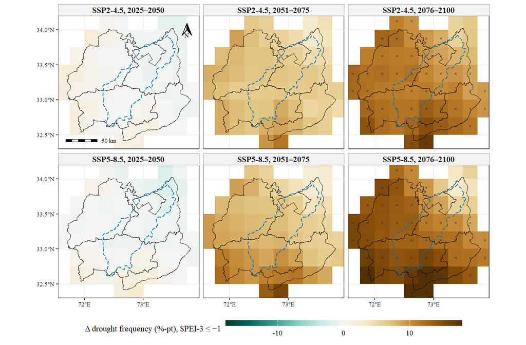

```r
CELLCHG_ALL <- cached("cell_changes_all", rbindlist(lapply(QDM_MODELS, function(mdl) rbindlist(lapply(SCEN, function(s) {
  pr <- PROJ[[mdl]][[s]]; X <- pr$cell_sel
  fb <- colMeans(X[pr$years >= BASE[1] & pr$years <= BASE[2], ] <= THR, na.rm = TRUE)
  rbindlist(lapply(c("near", "mid", "far"), function(p) { pp <- PERIODS[[p]]; i <- pr$years >= pp[1] & pr$years <= pp[2]
    data.table(model = mdl, scenario = s, period = p, cell = seq_len(ncol(X)), d_freq = 100 * (colMeans(X[i, ] <= THR, na.rm = TRUE) - fb)) }))
})))))
CELLCHG <- CELLCHG_ALL[model %in% TOP]                            # primary ensemble
CE <- CELLCHG[, { w <- WTS[model] / sum(WTS[model]); rb <- robust(d_freq); .(d_freq = sum(w * d_freq), robust_noFDR = rb["robust"] == 1, agree = rb["agree"], wilcox_p = rb["p"]) },
              by = .(scenario, period, cell)]
CE <- cbind(CE, ANA[CE$cell, .(lon, lat, w_region, w_basin)])
# v2.2 Item 5 (PREREGISTRATION.md): Benjamini-Hochberg FDR (alpha 0.05) across the cells of each scenario x period map; a cell is
# robust (hatched; used for the binary exposure mask) only if p_BH < 0.05 AND >= 80% of the models agree on the sign.
CE[, p_BH := p.adjust(wilcox_p, "BH"), by = .(scenario, period)]
CE[, robust := !is.na(p_BH) & p_BH < cfg$ensemble$robust_alpha & agree >= cfg$ensemble$robust_agreement]
CE[, panel := factor(paste0(SCEN_LAB[scenario], ", ", c(near = "2025–2050", mid = "2051–2075", far = "2076–2100")[period]),
                     levels = paste0(rep(SCEN_LAB, each = 3), ", ", c("2025–2050", "2051–2075", "2076–2100")))]
fwrite(CE, file.path(ROOT, "08_projections", "cell_change_drought_frequency.csv"))
lim6 <- max(abs(quantile(CE$d_freq, c(0.01, 0.99))))
fig6 <- ggplot() + geom_tile(data = CE, aes(lon, lat, fill = d_freq), width = 0.25, height = 0.25) +
  scale_fill_gradientn(colours = rev(DIV_BRBG), limits = c(-lim6, lim6), oob = squish,
                       name = paste0("Δ drought frequency (%-pt), ", SEL_NAME, " ≤ −1")) +
  geom_point(data = CE[robust == TRUE], aes(lon, lat), shape = 4, size = 0.55, stroke = 0.3, colour = "grey10") +
  geom_sf(data = dist, fill = NA, colour = "black", linewidth = 0.25) +
  geom_sf(data = basin, fill = NA, colour = "#0072B2", linewidth = 0.35, linetype = "longdash") +
  annotation_scale(data = data.frame(panel = factor(levels(CE$panel)[1], levels = levels(CE$panel))), location = "bl", height = unit(0.08, "cm"), text_family = "serif", text_cex = 0.45, line_width = 0.4) +
  annotation_north_arrow(data = data.frame(panel = factor(levels(CE$panel)[1], levels = levels(CE$panel))), location = "tr", height = unit(0.45, "cm"), width = unit(0.32, "cm"), style = north_arrow_orienteering(text_family = "serif", text_size = 4)) +
  facet_wrap(~panel, nrow = 2) + coord_sf(xlim = c(71.55, 73.95), ylim = c(32.3, 34.2), expand = FALSE) +
  scale_x_continuous(breaks = c(72, 73)) + scale_y_continuous(breaks = c(32.5, 33, 33.5, 34)) +
  labs(x = NULL, y = NULL) + theme(legend.position = "bottom", legend.key.width = unit(1.6, "cm"), legend.key.height = unit(0.2, "cm"),
                                   axis.text = element_text(size = 6))
save_fig(fig6, "Fig06_projected_change_maps", IEEE2, 4.6); fig6
```

```r
KEY$robust_cells_pct <- CE[w_region > 0, .(pct_robust = 100 * mean(robust), pct_robust_noFDR = 100 * mean(robust_noFDR), n_cells = .N,
                                         mean_change = weighted.mean(d_freq, w_region)), by = .(scenario, period)]
for (k in seq_len(nrow(KEY$robust_cells_pct))) { x <- KEY$robust_cells_pct[k]; lab <- paste(x$scenario, x$period)
  add_variant("5", paste("BH FDR + agreement:", lab), "primary", "% robust cells", x$pct_robust); add_variant("5", paste("no FDR (v2.1):", lab), "sensitivity", "% robust cells", x$pct_robust_noFDR) }
# v2.1 (audit m13): robustness per district. Each model's district change = area-weighted mean of its cell changes; then
# >= 80% sign agreement and Wilcoxon signed-rank on the (unweighted) model changes, as for cells and the region.
DROB <- rbindlist(lapply(DCOLS, function(d) { w <- ANA[[d]]
  x <- CELLCHG[, .(d_freq = sum(w[cell] * d_freq) / sum(w[cell])), by = .(model, scenario, period)]
  x[, { rb <- robust(d_freq); .(district = dname[[d]], wmean = sum(WTS[model] * d_freq) / sum(WTS[model]), agree = rb[["agree"]], wilcox_p = rb[["p"]], robust = rb[["robust"]] == 1) },
    by = .(scenario, period)] }))
setnames(DROB, "robust", "robust_noFDR")
DROB[, p_BH := p.adjust(wilcox_p, "BH"), by = .(scenario, period)]                # v2.2 Item 5: BH across the 5 units
DROB[, robust := !is.na(p_BH) & p_BH < cfg$ensemble$robust_alpha & agree >= cfg$ensemble$robust_agreement]
KEY$district_robustness <- DROB
TS4 <- dcast(DROB, district ~ scenario + period, value.var = "wmean", fun.aggregate = function(v) v)
TS4l <- dcast(DROB, district ~ scenario + period, value.var = "robust")
for (cn in setdiff(names(TS4), "district")) TS4[[cn]] <- sprintf("%.1f%s", TS4[[cn]], ifelse(TS4l[[cn]], "†", ""))
save_table(TS4, "S4", paste0("District-mean change in ", SEL_NAME, " drought frequency (%-points) relative to 1985–2014"), "TableS4_district_robustness",
           note = "Skill-weighted mean over the retained models of the area-weighted cell changes. † robust: ≥80% sign agreement and Benjamini–Hochberg-adjusted Wilcoxon signed-rank p < 0.05 (adjusted across the five units for each scenario and period) on the unweighted model changes.", digits = 1)
```

TABLE S4 DISTRICT-MEAN CHANGE IN SPEI-3 DROUGHT FREQUENCY (%-POINTS) RELATIVE TO 1985–2014

| district | ssp245_far | ssp245_mid | ssp245_near | ssp585_far | ssp585_mid | ssp585_near |
| --- | --- | --- | --- | --- | --- | --- |
| Attock | 11.4† | 7.0 | 0.6 | 13.5† | 7.7 | -0.1 |
| Chakwal | 12.0† | 7.2 | 0.5 | 14.7† | 9.3 | 0.4 |
| Islamabad (ICT) | 8.8† | 5.6 | -0.6 | 8.3† | 5.8 | -0.7 |
| Jhelum | 11.8† | 6.8 | 0.2 | 14.0† | 8.4 | 0.4 |
| Rawalpindi | 9.2† | 5.8 | -0.5 | 9.1† | 5.7 | -0.8 |

Skill-weighted mean over the retained models of the area-weighted cell changes. † robust: ≥80% sign agreement and Benjamini–Hochberg-adjusted Wilcoxon signed-rank p < 0.05 (adjusted across the five units for each scenario and period) on the unweighted model changes.

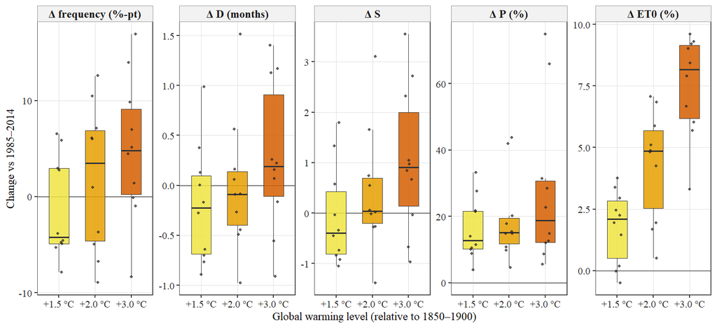

```r
gl <- melt(GWLM[, .(model, gwl, `Δ frequency (%-pt)` = d_freq, `Δ D (months)` = d_D, `Δ S` = d_S, `Δ P (%)` = d_P, `Δ ET0 (%)` = d_ET0)],
           id.vars = c("model", "gwl"))
gl[, gwl := factor(paste0("+", format(gwl, nsmall = 1), " °C"))]
fig7 <- ggplot(gl, aes(gwl, value)) + geom_hline(yintercept = 0, linewidth = 0.25) +
  geom_boxplot(aes(fill = gwl), width = 0.55, outlier.shape = NA, linewidth = 0.25, alpha = 0.85, show.legend = FALSE) +
  geom_jitter(width = 0.12, size = 0.7, alpha = 0.7, colour = "grey15") +
  scale_fill_manual(values = c("#F0E442", "#E69F00", "#D55E00")) +
  facet_wrap(~variable, nrow = 1, scales = "free_y") + labs(x = "Global warming level (relative to 1850–1900)", y = "Change vs 1985–2014")
save_fig(fig7, "Fig07_GWL_response", IEEE2, 3.2); fig7
```

# 6 Joint duration–severity return periods (Eq. 8)

v2.1 (audit M3): drought events (run theory, threshold −1, regional SPEI-3) were **declustered**, merging runs separated by a single non-drought month. The events of all retained GCMs were **pooled** for each set: the baseline, each scenario × period, and each GWL (both scenario windows of every model). - **Marginals** (v3.1): the duration D is a whole number of months, so D − 1 was fitted by AIC among the geometric, Poisson and negative binomial distributions; the severity S, which is at least 1 because every drought month adds |index| ≥ 1, as S − 1: semiparametrically (empirical distribution up to the 90th percentile, generalized Pareto tail above it, fitted by maximum likelihood) for the pooled ensemble sets (≥ 100 events), and by AIC among the exponential, gamma, Weibull and log-normal distributions for smaller samples. Both were tested with Kolmogorov–Smirnov and Anderson–Darling statistics using parametric-bootstrap p-values (N = 1,000), refitting the margin in each replicate. Pseudo-observations use mid-ranks for ties (deterministic). - The **copula** was selected by AIC among the Gaussian, Student-t, Clayton, Gumbel, Frank, Joe, BB1 and BB7 families, and was tested with a parametric-bootstrap Cramér–von Mises test (Sₙ, Genest et al., N = 1,000). - **95% CIs** come from a **model-level bootstrap**: the GCMs were resampled with replacement, their events pooled, and the model refitted with the same families (1,000 resamples). The observed series uses an event bootstrap. - The **effective record length** L is the number of pooled model-years. Return periods above 2L are flagged as extrapolated and not reported. - **Primary estimator:** if fewer than 80% of the pooled fits pass the copula test, the **empirical Bernstein (beta) copula** is primary. The parametric copula and the distribution-free count estimate are reported as checks. - **Diagnostic:** the per-GCM fits (v2) are kept, with each model’s event count and CvM pass rate.

T_AND = μ / [1 − F_D(d) − F_S(s) + C(F_D(d), F_S(s))], where μ is the mean inter-arrival time of the pooled events. GCM skill weights are not used here: every model contributes its events with equal weight (DEVIATIONS A4).

```r
# ---------------- v2 item 5: per-GCM copulas on declustered events ----------------
decl_events <- function(x, dates, thr = THR, tc = 1) {   # run theory + pooling of events separated by <= tc non-drought months
  b <- !is.na(x) & x <= thr; if (!any(b)) return(data.table(start = as.Date(character()), end = as.Date(character()), D = integer(), S = numeric(), I = numeric()))
  r <- rle(b); e <- cumsum(r$lengths); s <- e - r$lengths + 1; v <- r$values
  inner <- which(!v & r$lengths <= tc & seq_along(v) > 1 & seq_along(v) < length(v)); inner <- inner[v[inner - 1] & v[inner + 1]]
  g <- b; for (i in inner) g[s[i]:e[i]] <- TRUE
  r2 <- rle(g); e2 <- cumsum(r2$lengths); s2 <- e2 - r2$lengths + 1; k <- which(r2$values)
  data.table(start = dates[s2[k]], end = dates[e2[k]], D = r2$lengths[k],
             S = sapply(k, function(i) { idx <- s2[i]:e2[i]; sum(abs(x[idx][b[idx]])) }))[, I := S / D][]
}
# v3.1: duration D is a count of whole months (>= 1), so it gets discrete margins on D - 1 (shifted geometric, Poisson, negative
# binomial; AIC); severity S stays continuous (exponential, gamma, Weibull, lognormal; AIC). Discrete margins make the Item 2
# continuity point exact: F_D(k - 0.5) = P(D <= k - 1). Marginal goodness of fit: parametric-bootstrap KS/AD (gof_marg).
DISC_FAM <- c(geom1 = "geom", pois1 = "pois", nbinom1 = "nbinom")
fit_marg <- function(x) {
  x <- x[x > 0]
  if (all(x == round(x))) {
    fits <- lapply(DISC_FAM, function(d) tryCatch(logw(fitdist(x - 1, d, method = "mle"), paste("fit_marg mle", d)), error = function(e) NULL))
    ok <- !sapply(fits, is.null); fits <- fits[ok]; a <- sapply(fits, function(f) f$aic); b <- fits[[which.min(a)]]
    return(list(dist = names(fits)[which.min(a)], est = b$estimate, ks_p = NA_real_))
  }
  # severity: every drought month contributes |index| >= 1 (threshold -1), so S >= 1; S - 1 is fitted (known lower bound, "<dist>.loc1").
  # Large pooled samples (n >= 100, i.e. >= 10 tail exceedances): semiparametric margin (empirical body + GPD tail above the 90th
  # percentile, scripts/R/return_period_helpers.R), because the parametric families are rejected there; smaller samples: AIC family.
  if (length(x) >= 100) return(list(dist = "egpd", est = fit_egpd(x), ks_p = NA_real_))
  cands <- c("exp", "gamma", "weibull", "lnorm"); z <- pmax(x - 1, 1e-6)
  fits <- lapply(cands, function(d) tryCatch(logw(fitdist(z, d, method = "mle"), paste("fit_marg mle", d)),
                                             error = function(e) tryCatch(logw(fitdist(z, d, method = "mme"), paste("fit_marg mme", d)), error = function(e2) NULL)))
  ok <- !sapply(fits, is.null); fits <- fits[ok]; a <- sapply(fits, function(f) f$aic); b <- fits[[which.min(a)]]
  list(dist = paste0(b$distname, ".loc1"), est = b$estimate, ks_p = logw(do.call(ks.test, c(list(z, paste0("p", b$distname)), as.list(b$estimate)))$p.value, "fit_marg ks.test"))
}
refit_marg <- function(x, dist) { x <- x[x > 0]
  if (dist == "egpd") return(list(dist = dist, est = fit_egpd(x)))
  if (grepl("\\.loc1$", dist)) { r <- refit_marg(pmax(x - 1, 1e-6) + 1e-12, sub("\\.loc1$", "", dist)); return(list(dist = dist, est = r$est)) }   # S - 1
  if (dist == "geom1") return(list(dist = dist, est = c(prob = 1 / (1 + mean(x - 1)))))
  if (dist == "pois1") return(list(dist = dist, est = c(lambda = mean(x - 1))))
  if (dist == "nbinom1") { f <- tryCatch(logw(fitdist(x - 1, "nbinom", method = "mle"), "refit_marg nbinom"), error = function(e) NULL)
    if (is.null(f)) return(list(dist = "geom1", est = c(prob = 1 / (1 + mean(x - 1))))); return(list(dist = dist, est = f$estimate)) }
  if (dist == "lnorm") return(list(dist = dist, est = c(meanlog = mean(log(x)), sdlog = sqrt(mean((log(x) - mean(log(x)))^2)))))
  if (dist == "exp") return(list(dist = dist, est = c(rate = 1 / mean(x))))
  f <- logw(fitdist(x, dist, method = "mle"), paste("refit_marg", dist)); list(dist = dist, est = f$estimate) }
source(file.path(ROOT, "scripts", "R", "return_period_helpers.R"))   # v2.2 Item 2: pmarg, qmarg, T3, exceeds_duration, ref_duration_k, duration_cdf_point
FAMS <- c(1, 2, 3, 4, 5, 6, 7, 9)     # Gaussian, t, Clayton, Gumbel, Frank, Joe, BB1, BB7
fit_one <- function(ev, years) {
  mD <- fit_marg(ev$D); mS <- fit_marg(ev$S); U <- VineCopula::pobs(cbind(ev$D, ev$S), ties.method = "average")
  cop <- BiCopSelect(U[, 1], U[, 2], familyset = FAMS, selectioncrit = "AIC", rotations = FALSE)
  list(mD = mD, mS = mS, cop = cop, U = U, ev = ev, mu = years / nrow(ev), n = nrow(ev),
       tau_emp = cor(ev$D, ev$S, method = "kendall"), tau_p = cor.test(ev$D, ev$S, method = "kendall", exact = FALSE)$p.value)
}
cvm_pb <- function(U, cop, N) {           # parametric-bootstrap Cramer-von Mises S_n test (Genest, Remillard & Beaudoin 2009)
  Cn <- function(V) sapply(seq_len(nrow(V)), function(i) mean(V[, 1] <= V[i, 1] & V[, 2] <= V[i, 2]))
  Sn <- function(V, cp) sum((Cn(V) - BiCopCDF(V[, 1], V[, 2], cp))^2)
  s0 <- Sn(U, cop); n <- nrow(U)
  sb <- vapply(seq_len(N), function(b) { z <- BiCopSim(n, obj = cop); V <- VineCopula::pobs(z)
    cp <- tryCatch(BiCopEst(V[, 1], V[, 2], family = cop$family, method = if (cop$family %in% c(2, 7, 9)) "mle" else "itau"), error = function(e) NULL)
    if (is.null(cp)) NA_real_ else Sn(V, cp) }, numeric(1))
  c(Sn = s0, p = mean(sb >= s0, na.rm = TRUE))
}
boot_one <- function(f, d, s, N) {
  out <- array(NA_real_, c(N, length(d), 3))
  for (b in seq_len(N)) { i <- sample(f$n, replace = TRUE); e <- f$ev[i]
    g <- tryCatch({ mD <- refit_marg(e$D, f$mD$dist); mS <- refit_marg(e$S, f$mS$dist); U <- VineCopula::pobs(cbind(e$D, e$S), ties.method = "average")
      cp <- BiCopEst(U[, 1], U[, 2], family = f$cop$family, method = if (f$cop$family %in% c(2, 7, 9)) "mle" else "itau")
      list(mD = mD, mS = mS, cop = cp, U = U, ev = e, mu = f$mu) }, error = function(e) NULL)
    if (!is.null(g)) out[b, , ] <- T3(g, d, s) }
  out
}
# ---- event sets per GCM ----
sel_x <- function(pr) pr$reg$idx[[paste0(SEL_TYPE, SEL_K)]][, 1]
ev_period <- function(pr, per) { i <- pr$years >= per[1] & pr$years <= per[2]; list(ev = decl_events(sel_x(pr)[i], pr$dates[i]), years = per[2] - per[1] + 1) }
SETNAMES <- c("Baseline (1985–2014)", paste(rep(SCEN_LAB, each = 3), c("near", "mid", "far")), paste0("+", unlist(cfg$indices$gwl), " °C"))
ev_sets <- function(mdl) {
  out <- list(); out[["Baseline (1985–2014)"]] <- ev_period(PROJ[[mdl]][[SCEN[1]]], BASE)
  for (s in SCEN) for (p in c("near", "mid", "far")) out[[paste(SCEN_LAB[s], p)]] <- ev_period(PROJ[[mdl]][[s]], PERIODS[[p]])
  for (g in unlist(cfg$indices$gwl)) { w <- GWLCHG[model == mdl & gwl == g]; if (!nrow(w)) next
    l <- lapply(seq_len(nrow(w)), function(i) ev_period(PROJ[[mdl]][[w$scenario[i]]], c(w$start[i], w$end[i])))
    out[[paste0("+", g, " °C")]] <- list(ev = rbindlist(lapply(l, `[[`, "ev")), years = sum(sapply(l, `[[`, "years"))) }
  out
}
EVS <- sapply(TOP, ev_sets, simplify = FALSE)
EV_OBS_D <- decl_events(IDX_REG$grid[[paste0(SEL_TYPE, SEL_K)]][, 1], DATES_OBS)
# reference events: univariate 10/25/50-yr D and S of the pooled model baseline (AIC margins: discrete for D, continuous for S)
pool_base <- rbindlist(lapply(TOP, function(m) EVS[[m]][["Baseline (1985–2014)"]]$ev))
mu_pool <- sum(sapply(TOP, function(m) EVS[[m]][["Baseline (1985–2014)"]]$years)) / nrow(pool_base)
mDp <- fit_marg(pool_base$D); mSp <- fit_marg(pool_base$S)
REF <- data.table(T = c(10, 25, 50))[, `:=`(d = qmarg(mDp, 1 - mu_pool / T), s = qmarg(mSp, 1 - mu_pool / T))][, k := ref_duration_k(d)]   # k: whole months (Item 2)
NB <- cfg$ensemble$bootstrap_n
COP <- cached("copula_v2", {
  jobs <- c(lapply(TOP, function(m) lapply(names(EVS[[m]]), function(st) list(model = m, set = st))) |> unlist(recursive = FALSE),
            list(list(model = "observed", set = "Observed (1981–2024)")))
  cl <- parallel::makeCluster(max(1, min(6, parallel::detectCores() - 2)))
  on.exit(parallel::stopCluster(cl))
  parallel::clusterEvalQ(cl, suppressPackageStartupMessages({ library(VineCopula); library(copula); library(fitdistrplus); library(data.table) }))
  parallel::clusterExport(cl, c("logw", "WLOG", "MASTER_PID", "DISC_FAM", "shifted", "loc1", "base_dist", "fit_egpd", "p_egpd", "q_egpd", "exceeds_duration", "ref_duration_k", "duration_cdf_point", "EVS", "EV_OBS_D", "fit_one", "fit_marg", "refit_marg", "pmarg", "cvm_pb", "T3", "boot_one", "REF", "NB", "FAMS", "SEED"), envir = environment())
  res <- parallel::parLapply(cl, jobs, function(j) {
    set.seed(SEED + match(j$set, c(names(EVS[[1]]), "Observed (1981–2024)")) * 1000 + nchar(j$model))
    e <- if (j$model == "observed") list(ev = EV_OBS_D, years = 44) else EVS[[j$model]][[j$set]]
    if (is.null(e) || nrow(e$ev) < 8) return(NULL)
    f <- fit_one(e$ev, e$years); g <- cvm_pb(f$U, f$cop, NB)
    list(model = j$model, set = j$set, n = f$n, mu = f$mu, family = BiCopName(f$cop$family, short = FALSE), par = f$cop$par, par2 = f$cop$par2,
         tau_emp = f$tau_emp, tau_p = f$tau_p, tau_cop = f$cop$tau, aic = f$cop$AIC, cvm_Sn = g[["Sn"]], cvm_p = g[["p"]],
         marg_D = f$mD$dist, marg_S = f$mS$dist, T = T3(f, REF$d, REF$s), boot = boot_one(f, REF$d, REF$s, NB))
  })
  Filter(Negate(is.null), res)
})
CFIT <- rbindlist(lapply(COP, function(r) data.table(model = r$model, set = r$set, n = r$n, mu = r$mu, family = r$family, tau_emp = r$tau_emp, tau_p = r$tau_p,
                                                     tau_cop = r$tau_cop, cvm_p = r$cvm_p, marg_D = r$marg_D, marg_S = r$marg_S)))
CFIT[, pass := cvm_p >= 0.05]
PASS_PCT <- 100 * CFIT[model != "observed", mean(pass)]
fwrite(CFIT, file.path(ROOT, "09_return_periods", "copula_per_gcm_fits.csv"))
EST <- colnames(COP[[1]]$T)                               # c("parametric", "bernstein", "count"): same order as T3()
stopifnot(identical(EST, c("parametric", "bernstein", "count")))
# ---------------- v2.1 (audit M3): pooled-ensemble fits, model-level bootstrap, marginal GoF, extrapolation flag ----------------
# Events of all retained GCMs are pooled per set (baseline, scenario x period, GWL); marginals and copula are selected by AIC on
# the pooled sample. 95% CIs: model-level bootstrap (resample the GCMs with replacement, pool their events, refit with the same
# families). Marginal goodness of fit: Kolmogorov-Smirnov and Anderson-Darling with parametric-bootstrap p-values (D is simulated
# and rounded up to whole months, as observed). Effective record length L = pooled model-years; T > 2L is flagged as extrapolated.
ad_stat <- function(x, Fx) { n <- length(x); u <- pmin(pmax(sort(Fx(x)), 1e-10), 1 - 1e-10); -n - mean((2 * seq_len(n) - 1) * (log(u) + log(1 - rev(u)))) }
gof_marg <- function(x, m, N, discrete) {
  x <- x[x > 0]
  ks_stat1 <- function(z, Fn) { z <- sort(z); n <- length(z); u <- Fn(z); max(pmax(seq_len(n) / n - u, u - (seq_len(n) - 1) / n)) }   # = ks.test()$statistic
  st <- function(z, mm) c(KS = ks_stat1(z, function(q) pmarg(mm, q)), AD = ad_stat(z, function(q) pmarg(mm, q)))
  s0 <- st(x, m)
  sb <- t(vapply(seq_len(N), function(b) { z <- qmarg(m, runif(length(x))); if (discrete) z <- pmax(ceiling(z), 1)
    mm <- tryCatch(refit_marg(z, m$dist), error = function(e) NULL); if (is.null(mm)) c(NA_real_, NA_real_) else st(z, mm) }, numeric(2)))
  c(KS = unname(s0[1]), KS_p = mean(sb[, 1] >= s0[1], na.rm = TRUE), AD = unname(s0[2]), AD_p = mean(sb[, 2] >= s0[2], na.rm = TRUE))
}
pool_ev <- function(st, mods) { ok <- mods[sapply(mods, function(m) !is.null(EVS[[m]][[st]]))]
  list(ev = rbindlist(lapply(ok, function(m) cbind(model = m, copy(EVS[[m]][[st]]$ev)))), years = setNames(sapply(ok, function(m) EVS[[m]][[st]]$years), ok)) }
POOLED <- cached("copula_pooled_v2_1", {
  jobs <- c(SETNAMES, "Observed (1981–2024)")
  cl <- parallel::makeCluster(max(1, min(6, parallel::detectCores() - 2)))
  on.exit(parallel::stopCluster(cl))
  parallel::clusterEvalQ(cl, suppressPackageStartupMessages({ library(VineCopula); library(copula); library(fitdistrplus); library(data.table) }))
  parallel::clusterExport(cl, c("logw", "WLOG", "MASTER_PID", "DISC_FAM", "shifted", "loc1", "base_dist", "fit_egpd", "p_egpd", "q_egpd", "exceeds_duration", "ref_duration_k", "duration_cdf_point", "jobs", "EVS", "EV_OBS_D", "TOP", "pool_ev", "fit_one", "fit_marg", "refit_marg", "pmarg", "qmarg", "cvm_pb", "gof_marg", "ad_stat",
```

```r
                                "T3", "REF", "NB", "FAMS", "SEED"), envir = environment())
  res <- parallel::parLapply(cl, jobs, function(st) {
    set.seed(SEED + match(st, jobs))
    if (st == "Observed (1981–2024)") { ev <- cbind(model = "observed", copy(EV_OBS_D)); yrs <- c(observed = 44) } else { p <- pool_ev(st, TOP); ev <- p$ev; yrs <- p$years }
    if (nrow(ev) < 8) return(NULL)
    f <- fit_one(ev, sum(yrs)); g <- cvm_pb(f$U, f$cop, NB)
    gD <- gof_marg(ev$D, f$mD, NB, discrete = TRUE); gS <- gof_marg(ev$S, f$mS, NB, discrete = FALSE)
    by_m <- split(ev, by = "model", keep.by = FALSE); mods <- names(yrs)
    boot <- array(NA_real_, c(NB, nrow(REF), 3))
    for (b in seq_len(NB)) {
      if (length(mods) > 1) { ms <- sample(mods, replace = TRUE); e <- rbindlist(by_m[ms]); y <- sum(yrs[ms]) } else { e <- ev[sample(.N, replace = TRUE)]; y <- sum(yrs) }
      fb <- tryCatch({ U <- VineCopula::pobs(cbind(e$D, e$S), ties.method = "average")
        list(mD = refit_marg(e$D, f$mD$dist), mS = refit_marg(e$S, f$mS$dist), U = U, ev = e, mu = y / nrow(e),
             cop = BiCopEst(U[, 1], U[, 2], family = f$cop$family, method = if (f$cop$family %in% c(2, 7, 9)) "mle" else "itau")) }, error = function(e) NULL)
      if (!is.null(fb)) boot[b, , ] <- T3(fb, REF$d, REF$s) }
    list(set = st, n = f$n, years = sum(yrs), n_by_model = table(ev$model), mu = f$mu, family = BiCopName(f$cop$family, short = FALSE), par = f$cop$par, par2 = f$cop$par2,
         tau_emp = f$tau_emp, tau_cop = f$cop$tau, cvm_p = g[["p"]], marg_D = f$mD$dist, marg_S = f$mS$dist, gof_D = gD, gof_S = gS,
         n_exceed = sapply(seq_len(nrow(REF)), function(k) sum(exceeds_duration(ev$D, REF$d[k]) & ev$S >= REF$s[k])), T = T3(f, REF$d, REF$s), boot = boot, fit = f)
  })
  Filter(Negate(is.null), res)
})
PFIT <- rbindlist(lapply(POOLED, function(r) data.table(set = r$set, n = r$n, model_years = r$years, n_models = length(r$n_by_model),
  n_per_model = if (length(r$n_by_model) > 1) sprintf("%d (%d–%d)", as.integer(median(r$n_by_model)), min(r$n_by_model), max(r$n_by_model)) else as.character(r$n),
  family = r$family, tau_emp = r$tau_emp, tau_cop = r$tau_cop, cvm_p = r$cvm_p, marg_D = r$marg_D, D_KS_p = r$gof_D[["KS_p"]], D_AD_p = r$gof_D[["AD_p"]],
  marg_S = r$marg_S, S_KS_p = r$gof_S[["KS_p"]], S_AD_p = r$gof_S[["AD_p"]], n_exceed_25yr = r$n_exceed[2])))
PASS_POOLED <- 100 * PFIT[set != "Observed (1981–2024)", mean(cvm_p >= 0.05)]
PRIMARY <- if (PASS_POOLED < 80) "bernstein" else "parametric"
KEY$copula_gof <- list(pass_pct = PASS_PCT, n_fits = CFIT[model != "observed", .N], median_n = CFIT[model != "observed", median(n)],
                       per_gcm_n_range = range(CFIT[model != "observed", n]), families = CFIT[model != "observed", .N, by = family][order(-N)],
                       tau_abs_diff_median = CFIT[model != "observed", median(abs(tau_emp - tau_cop))], observed = CFIT[model == "observed"],
                       pooled = PFIT, pooled_pass_pct = PASS_POOLED, primary = PRIMARY,
                       note = "per-GCM fits are a diagnostic; return periods come from the pooled-ensemble fits with a model-level bootstrap")
fwrite(PFIT, file.path(ROOT, "09_return_periods", "copula_pooled_fits.csv"))
ENS_T <- rbindlist(lapply(POOLED, function(r) rbindlist(lapply(seq_len(nrow(REF)), function(k) rbindlist(lapply(seq_along(EST), function(e)
  data.table(set = r$set, T_ref = REF$T[k], estimator = EST[e], T_and = r$T[k, e], lo = quantile(r$boot[, k, e], 0.025, na.rm = TRUE, names = FALSE),
             hi = quantile(r$boot[, k, e], 0.975, na.rm = TRUE, names = FALSE), model_years = r$years, n_exceed = r$n_exceed[k])))))))
ENS_T[, extrapolated := !is.finite(T_and) | T_and > 2 * model_years]
# assertion (audit C1): every value must sit under the column name it came from
for (r in POOLED) for (e in EST) for (k in seq_len(nrow(REF)))
  stopifnot(isTRUE(all.equal(ENS_T[set == r$set & estimator == e & T_ref == REF$T[k], T_and], unname(r$T[k, e]))))
KEY$copula_T <- ENS_T; KEY$ref_events <- REF
# Item 2 report: the same pooled fits evaluated with the previous (v2.1) duration rule
RPRULE <- rbindlist(lapply(POOLED, function(r0) { tn <- r0$T; to <- T3(r0$fit, REF$d, REF$s, rule = "continuous_v2.1")
  rbindlist(lapply(seq_len(nrow(REF)), function(k) data.table(set = r0$set, T_ref = REF$T[k], d_ref = REF$d[k], k_months = REF$k[k],
    estimator = EST, T_new = as.numeric(tn[k, EST]), T_old_rule = as.numeric(to[k, EST])))) }))[, diff := T_new - T_old_rule]
KEY$rp_rule_comparison <- RPRULE
fwrite(RPRULE, file.path(ROOT, "09_return_periods", "return_periods_duration_rule_comparison.csv"))
fwrite(ENS_T, file.path(ROOT, "09_return_periods", "return_periods_three_estimators.csv"))
fmtT <- function(x, lo, hi, ex, L) ifelse(ex, "extrapolated (> 2L)", sprintf("%.1f (%.1f–%s)", x, lo, ifelse(is.finite(hi) & hi <= 2 * L, sprintf("%.1f", hi), "> 2L")))
T5 <- PFIT[, .(Set = set, `Pooled events` = n, `Events per GCM, median (range)` = n_per_model, `Model-years L` = model_years, `Copula (AIC)` = family,
               `CvM p` = round(cvm_p, 3), `D: margin, AD p` = sprintf("%s, %.2f", marg_D, D_AD_p), `S: margin, AD p` = sprintf("%s, %.2f", marg_S, S_AD_p),
               `Events beyond the 25-yr reference` = n_exceed_25yr)]
for (e in c("bernstein", "parametric", "count")) { z <- ENS_T[T_ref == 25 & estimator == e, .(Set = set, v = fmtT(T_and, lo, hi, extrapolated, model_years))]
  setnames(z, "v", paste0("T_AND 25-yr, ", c(bernstein = "Bernstein", parametric = "parametric", count = "count")[e])); T5 <- merge(T5, z, by = "Set") }
T5 <- T5[match(c("Observed (1981–2024)", SETNAMES), Set)][!is.na(Set)]
save_table(T5, 5, paste0("Joint duration–severity (AND) return periods (years) of the baseline 25-year event: pooled-ensemble copulas (primary estimator: ",
                         if (PRIMARY == "bernstein") "empirical Bernstein copula" else "parametric copula", ")"), "Table5_return_periods",
           note = paste0("Events (run theory, threshold −1, runs separated by one non-drought month pooled) of the ", NKEEP, " retained GCMs pooled per set; marginals by AIC ",
                         "(D − 1: geometric, Poisson, negative binomial; S − 1: empirical body with a generalized Pareto tail above the 90th percentile for ≥ 100 events, otherwise exponential, gamma, Weibull or log-normal) with parametric-bootstrap Anderson–Darling p-values (KS in 09_return_periods/copula_pooled_fits.csv); copula by AIC among ",
                         "Gaussian, t, Clayton, Gumbel, Frank, Joe, BB1, BB7 with a parametric-bootstrap Cramér–von Mises test (N = ", NB, "). 95% CIs from ", NB,
                         " model-level bootstrap resamples. L = pooled model-years; values above 2L are not reported. Reference event: D ≥ ", REF$k[2], " whole months (rounded from ", round(REF$d[2], 2), ")",
                         " and S ≥ ", round(REF$s[2], 1), ". Per-GCM fits (diagnostic): ", round(PASS_PCT), "% passed the CvM test (09_return_periods/copula_per_gcm_fits.csv)."), digits = 2)
```

TABLE V JOINT DURATION–SEVERITY (AND) RETURN PERIODS (YEARS) OF THE BASELINE 25-YEAR EVENT: POOLED-ENSEMBLE COPULAS (PRIMARY ESTIMATOR: EMPIRICAL BERNSTEIN COPULA)

| Set | Pooled events | Events per GCM, median (range) | Model-years L | Copula (AIC) | CvM p | D: margin, AD p | S: margin, AD p | Events beyond the 25-yr reference | T_AND 25-yr, Bernstein | T_AND 25-yr, parametric | T_AND 25-yr, count |
| --- | --- | --- | --- | --- | --- | --- | --- | --- | --- | --- | --- |
| Observed (1981–2024) | 31 | 31 | 44.00 | Gumbel | 0.00 | geom1, 0.57 | exp.loc1, 0.04 | 2 | 79.9 (32.9–> 2L) | 33.5 (13.9–> 2L) | 22.0 (8.8–> 2L) |
| Baseline (1985–2014) | 244 | 24 (20–31) | 300.00 | Frank | 0.00 | geom1, 0.29 | egpd, 0.37 | 9 | 50.1 (23.3–> 2L) | 43.4 (23.5–68.8) | 33.3 (21.4–75.0) |
| SSP2-4.5 near | 202 | 21 (9–27) | 260.00 | Frank | 0.00 | geom1, 0.49 | egpd, 0.55 | 8 | 33.6 (20.0–179.7) | 41.3 (19.3–138.1) | 32.5 (15.3–260.0) |
| SSP2-4.5 mid | 236 | 24 (14–32) | 250.00 | Frank | 0.00 | geom1, 0.42 | egpd, 0.58 | 16 | 19.0 (10.7–56.1) | 16.6 (9.2–38.4) | 15.6 (8.9–35.7) |
| SSP2-4.5 far | 244 | 25 (19–32) | 250.00 | Frank | 0.00 | nbinom1, 0.29 | egpd, 0.60 | 31 | 9.5 (6.9–15.9) | 9.0 (6.3–14.5) | 8.1 (5.6–13.9) |
| SSP5-8.5 near | 214 | 23 (12–28) | 260.00 | Joe | 0.00 | nbinom1, 0.46 | egpd, 0.86 | 13 | 28.8 (16.7–166.3) | 19.2 (11.9–42.4) | 20.0 (11.8–52.0) |
| SSP5-8.5 mid | 231 | 23 (14–33) | 250.00 | Frank | 0.00 | nbinom1, 0.37 | egpd, 0.11 | 14 | 23.5 (14.6–65.8) | 13.9 (10.0–22.2) | 17.9 (10.9–41.7) |
| SSP5-8.5 far | 254 | 27 (13–32) | 250.00 | Frank | 0.00 | nbinom1, 0.25 | egpd, 0.70 | 30 | 10.0 (7.2–18.4) | 9.3 (6.7–15.5) | 8.3 (5.7–16.7) |
| +1.5 °C | 320 | 31 (23–45) | 400.00 | Frank | 0.00 | nbinom1, 0.48 | egpd, 0.73 | 17 | 28.5 (18.0–113.3) | 38.2 (18.6–107.7) | 23.5 (13.8–66.7) |
| +2 °C | 348 | 37 (21–46) | 400.00 | Frank | 0.00 | nbinom1, 0.50 | egpd, 0.90 | 26 | 19.1 (13.1–36.5) | 19.1 (11.5–32.4) | 15.4 (10.3–26.7) |
| +3 °C | 252 | 21 (11–44) | 280.00 | Frank | 0.00 | nbinom1, 0.33 | egpd, 0.05 | 18 | 17.0 (11.8–29.5) | 12.0 (8.4–20.2) | 15.6 (9.4–48.0) |

Events (run theory, threshold −1, runs separated by one non-drought month pooled) of the 10 retained GCMs pooled per set; marginals by AIC (D − 1: geometric, Poisson, negative binomial; S − 1: empirical body with a generalized Pareto tail above the 90th percentile for ≥ 100 events, otherwise exponential, gamma, Weibull or log-normal) with parametric-bootstrap Anderson–Darling p-values (KS in 09_return_periods/copula_pooled_fits.csv); copula by AIC among Gaussian, t, Clayton, Gumbel, Frank, Joe, BB1, BB7 with a parametric-bootstrap Cramér–von Mises test (N = 1000). 95% CIs from 1000 model-level bootstrap resamples. L = pooled model-years; values above 2L are not reported. Reference event: D ≥ 7 whole months (rounded from 7) and S ≥ 9.2. Per-GCM fits (diagnostic): 0% passed the CvM test (09_return_periods/copula_per_gcm_fits.csv).

```r
T5
```

| Set | Pooled events | Events per GCM, median (range) | Model-years L | Copula (AIC) | CvM p | D: margin, AD p | S: margin, AD p | Events beyond the 25-yr reference | T_AND 25-yr, Bernstein | T_AND 25-yr, parametric | T_AND 25-yr, count |
| --- | --- | --- | --- | --- | --- | --- | --- | --- | --- | --- | --- |
| Observed (1981–2024) | 31 | 31 | 44 | Gumbel | 0 | geom1, 0.57 | exp.loc1, 0.04 | 2 | 79.9 (32.9–> 2L) | 33.5 (13.9–> 2L) | 22.0 (8.8–> 2L) |
| Baseline (1985–2014) | 244 | 24 (20–31) | 300 | Frank | 0 | geom1, 0.29 | egpd, 0.37 | 9 | 50.1 (23.3–> 2L) | 43.4 (23.5–68.8) | 33.3 (21.4–75.0) |
| SSP2-4.5 near | 202 | 21 (9–27) | 260 | Frank | 0 | geom1, 0.49 | egpd, 0.55 | 8 | 33.6 (20.0–179.7) | 41.3 (19.3–138.1) | 32.5 (15.3–260.0) |
| SSP2-4.5 mid | 236 | 24 (14–32) | 250 | Frank | 0 | geom1, 0.42 | egpd, 0.58 | 16 | 19.0 (10.7–56.1) | 16.6 (9.2–38.4) | 15.6 (8.9–35.7) |
| SSP2-4.5 far | 244 | 25 (19–32) | 250 | Frank | 0 | nbinom1, 0.29 | egpd, 0.60 | 31 | 9.5 (6.9–15.9) | 9.0 (6.3–14.5) | 8.1 (5.6–13.9) |
| SSP5-8.5 near | 214 | 23 (12–28) | 260 | Joe | 0 | nbinom1, 0.46 | egpd, 0.86 | 13 | 28.8 (16.7–166.3) | 19.2 (11.9–42.4) | 20.0 (11.8–52.0) |
| SSP5-8.5 mid | 231 | 23 (14–33) | 250 | Frank | 0 | nbinom1, 0.37 | egpd, 0.11 | 14 | 23.5 (14.6–65.8) | 13.9 (10.0–22.2) | 17.9 (10.9–41.7) |
| SSP5-8.5 far | 254 | 27 (13–32) | 250 | Frank | 0 | nbinom1, 0.25 | egpd, 0.70 | 30 | 10.0 (7.2–18.4) | 9.3 (6.7–15.5) | 8.3 (5.7–16.7) |
| +1.5 °C | 320 | 31 (23–45) | 400 | Frank | 0 | nbinom1, 0.48 | egpd, 0.73 | 17 | 28.5 (18.0–113.3) | 38.2 (18.6–107.7) | 23.5 (13.8–66.7) |
| +2 °C | 348 | 37 (21–46) | 400 | Frank | 0 | nbinom1, 0.50 | egpd, 0.90 | 26 | 19.1 (13.1–36.5) | 19.1 (11.5–32.4) | 15.4 (10.3–26.7) |
| +3 °C | 252 | 21 (11–44) | 280 | Frank | 0 | nbinom1, 0.33 | egpd, 0.05 | 18 | 17.0 (11.8–29.5) | 12.0 (8.4–20.2) | 15.6 (9.4–48.0) |

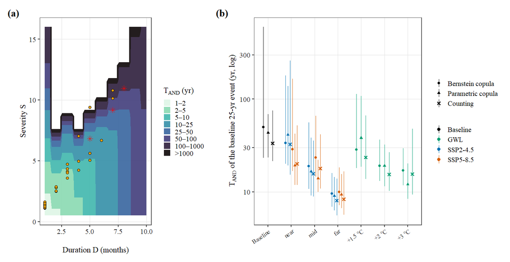

```r
gridDS <- CJ(D = seq(1, 10, length.out = 60), S = seq(0.5, 16, length.out = 60))
fbase <- Filter(function(r) r$set == "Baseline (1985–2014)", POOLED)[[1]]$fit
gridDS[, T := T3(fbase, gridDS$D, gridDS$S)[, PRIMARY]]
p8a <- ggplot(gridDS, aes(D, S)) + geom_contour_filled(aes(z = log10(pmin(T, 1e6))), breaks = log10(c(1, 2, 5, 10, 25, 50, 100, 1000, 1e6)), alpha = 0.9) +
  scale_fill_viridis_d(option = "mako", direction = -1, labels = c("1–2", "2–5", "5–10", "10–25", "25–50", "50–100", "100–1000", ">1000"), name = expression(T[AND]~"(yr)")) +
  geom_point(data = EV_OBS_D, aes(D, S), shape = 21, fill = "#E69F00", size = 1.2, stroke = 0.3) +
  geom_point(data = REF, aes(d, s), shape = 8, size = 1.6, colour = "red") +
  labs(x = "Duration D (months)", y = "Severity S", tag = "(a)") +
  theme(legend.key.size = unit(0.25, "cm"))
bp <- ENS_T[set != "Observed (1981–2024)" & !extrapolated]
bp[, grp := fifelse(grepl("SSP2", set), "SSP2-4.5", fifelse(grepl("SSP5", set), "SSP5-8.5", fifelse(grepl("°C", set), "GWL", "Baseline")))]
bp[, xlab := factor(sub("SSP[0-9]-[0-9.]+ ", "", sub(" \\(1985–2014\\)", "", set)), levels = c("Baseline", "near", "mid", "far", "+1.5 °C", "+2 °C", "+3 °C"))]
bp[, est := factor(c(bernstein = "Bernstein copula", parametric = "Parametric copula", count = "Counting")[estimator], levels = c("Bernstein copula", "Parametric copula", "Counting"))]
bp[, `:=`(lo = pmax(lo, 1), hi = pmin(hi, 2 * model_years))]
p8b <- ggplot(bp[T_ref == 25], aes(xlab, T_and, colour = grp, shape = est)) +
  geom_pointrange(aes(ymin = lo, ymax = hi), position = position_dodge(0.6), size = 0.18, linewidth = 0.3) + scale_y_log10() +
  scale_colour_manual(values = c(Baseline = "black", `SSP2-4.5` = "#0072B2", `SSP5-8.5` = "#D55E00", GWL = "#009E73"), name = NULL) +
  scale_shape_manual(values = c(16, 17, 4), name = NULL) +
  labs(x = NULL, y = expression(T[AND]~"of the baseline 25-yr event (yr, log)"), tag = "(b)") +
  theme(axis.text.x = element_text(angle = 35, hjust = 1, size = 6), legend.position = "right", legend.box = "vertical")
fig8 <- p8a + p8b + plot_layout(widths = c(1, 1.5))
save_fig(fig8, "Fig08_copula_return_periods", IEEE2, 3.6); fig8
```

# 7 District-level exposure of rainfed crops (III-F)

Hotspots are 0.25° cells with a **robust increase** in SPEI-3 drought frequency. Rainfed wheat and groundnut physical areas (SPAM2010, 5′) were redistributed to 0.01° pixels in proportion to the ESA WorldCover 2021 cropland area. They were then scaled so that each district total equals the official un-irrigated area reported by the Crop Reporting Service Punjab (mean of 2021-22 to 2023-24; Table S2), and summed within the hotspots of each district and ICT. SPAM2010 therefore sets only the allocation within a district.

```r
EXP <- cached("exposure_layers", {
  wc <- rast(file.path(ROOT, "10_exposure", "worldcover_fractions_0p01.tif"))[["cropland"]]
  crop_ha <- wc * cellSize(wc, unit = "ha")
  sp <- rast(file.path(ROOT, "10_exposure", "spam2010_potohar.tif"))
  names(sp) <- c("WHEA_R", "WHEA_A", "GROU_R", "GROU_A")
  zid <- rast(sp[[1]]); values(zid) <- seq_len(ncell(zid))
  z01 <- resample(zid, wc, method = "near")
  csum <- zonal(crop_ha, z01, "sum"); names(csum) <- c("z", "crop_sum")
  out <- list(crop_ha = wrap(crop_ha))
  for (L in c("WHEA_R", "GROU_R")) {
    a <- data.frame(z = seq_len(ncell(zid)), area = values(sp[[L]])[, 1]); a <- merge(a, csum, by = "z", all.x = TRUE)
    zv <- values(z01)[, 1]; cv <- values(crop_ha)[, 1]
    ia <- match(zv, a$z); share <- cv / a$crop_sum[ia]; share[!is.finite(share)] <- 0
    r <- rast(wc); values(r) <- a$area[ia] * share; out[[L]] <- wrap(r)
  }
  dz <- rasterize(vect(dist), wc, field = "district"); out$dist <- wrap(dz)
  out
})
crop_ha <- unwrap(EXP$crop_ha); whe <- unwrap(EXP$WHEA_R); gro <- unwrap(EXP$GROU_R); dz <- unwrap(EXP$dist)
hot_mask <- function(s, p) { h <- CE[scenario == s & period == p & robust == TRUE & d_freq > 0]
  r <- rast(crop_ha); v <- rep(0, ncell(r)); xy <- xyFromCell(r, 1:ncell(r))
  for (i in seq_len(nrow(h))) v[abs(xy[, 1] - h$lon[i]) < 0.125 & abs(xy[, 2] - h$lat[i]) < 0.125] <- 1
  values(r) <- v; r }
dvals <- values(dz)[, 1]; dlev <- levels(dz)[[1]]
EXPO <- rbindlist(lapply(SCEN, function(s) rbindlist(lapply(c("near", "mid", "far"), function(p) {
  hm <- values(hot_mask(s, p))[, 1]
  data.table(dist_id = dvals, wheat = values(whe)[, 1], gnut = values(gro)[, 1], crop = values(crop_ha)[, 1], hot = hm)[!is.na(dist_id),
    .(wheat_total = sum(wheat, na.rm = TRUE), wheat_exp = sum(wheat * hot, na.rm = TRUE), gnut_total = sum(gnut, na.rm = TRUE),
      gnut_exp = sum(gnut * hot, na.rm = TRUE), crop_total = sum(crop, na.rm = TRUE), crop_exp = sum(crop * hot, na.rm = TRUE)), by = dist_id][,
    `:=`(scenario = s, period = p)] }))))
EXPO[, district := dlev[match(dist_id, dlev[, 1]), 2]]
# v2: SPAM2010 gives the allocation within each district; district totals are scaled to the official CRS un-irrigated (rainfed)
# area, mean of 2021-22 to 2023-24 (SPAM2010 rainfed wheat is ~2.3x the reported area; see Table S2)
crs_ref <- function(f) fread(file.path(ROOT, "data", "yields", f))[harvest_year %in% 2022:2024, .(ref = 1000 * mean(rainfed_area_000ha)), by = district][
  , district := fifelse(district == "Islamabad", "Islamabad (ICT)", district)][]
EXPO <- merge(EXPO, crs_ref("district_wheat_irrigation_crs.csv")[, .(district, ref_w = ref)], by = "district", all.x = TRUE)
EXPO <- merge(EXPO, crs_ref("district_groundnut.csv")[, .(district, ref_g = ref)], by = "district", all.x = TRUE)
EXPO[, `:=`(spam_wheat_total = wheat_total, spam_gnut_total = gnut_total,
            f_w = fifelse(wheat_total > 0, ref_w / wheat_total, 0), f_g = fifelse(gnut_total > 0, ref_g / gnut_total, 0))]
EXPO[, `:=`(wheat_total = wheat_total * f_w, wheat_exp = wheat_exp * f_w, gnut_total = gnut_total * f_g, gnut_exp = gnut_exp * f_g)]
KEY$exposure_scaling <- unique(EXPO[, .(district, spam_wheat_total, crs_wheat_rainfed = ref_w, f_w, spam_gnut_total, crs_gnut_rainfed = ref_g, f_g)])
fwrite(EXPO, file.path(ROOT, "10_exposure", "exposure_by_district.csv"))
KEY$exposure <- EXPO
# binary hotspot exposure: kept as a secondary measure (Table S3)
TS3 <- dcast(EXPO[period %in% c("mid", "far")], district + round(wheat_total) + round(gnut_total) + round(crop_total) ~ scenario + period,
             value.var = c("wheat_exp", "gnut_exp"), fun.aggregate = function(x) round(sum(x)))
setnames(TS3, 2:4, c("Rainfed wheat (ha)", "Rainfed groundnut (ha)", "Cropland (ha)"))
save_table(TS3, "S3", paste0("Binary exposure (secondary measure): rainfed wheat and groundnut area (ha) inside cells with a robust increase in ", SEL_NAME, " drought frequency"),
           "TableS3_exposure_binary", note = "Exposed = area inside 0.25° cells with a robust increase (≥80% sign agreement and Benjamini–Hochberg-adjusted Wilcoxon p < 0.05 across the cells of each map). Crop areas as in Table 6.", digits = 0)
```

TABLE S3 BINARY EXPOSURE (SECONDARY MEASURE): RAINFED WHEAT AND GROUNDNUT AREA (HA) INSIDE CELLS WITH A ROBUST INCREASE IN SPEI-3 DROUGHT FREQUENCY

| district | Rainfed wheat (ha) | Rainfed groundnut (ha) | Cropland (ha) | wheat_exp_ssp245_far | wheat_exp_ssp245_mid | wheat_exp_ssp585_far | wheat_exp_ssp585_mid | gnut_exp_ssp245_far | gnut_exp_ssp245_mid | gnut_exp_ssp585_far | gnut_exp_ssp585_mid |
| --- | --- | --- | --- | --- | --- | --- | --- | --- | --- | --- | --- |
| Attock | 182,513 | 45,324 | 273,698 | 161,332 | 0 | 182,513 | 0 | 41,480 | 0 | 45,324 | 0 |
| Chakwal | 148,520 | 65,445 | 263,579 | 131,133 | 0 | 148,520 | 0 | 60,901 | 0 | 65,445 | 0 |
| Islamabad (ICT) | 28,598 | 0 | 21,195 | 16,170 | 0 | 19,961 | 0 | 0 | 0 | 0 | 0 |
| Jhelum | 69,201 | 1,119 | 132,676 | 69,201 | 0 | 69,201 | 0 | 1,119 | 0 | 1,119 | 0 |
| Rawalpindi | 162,684 | 4,060 | 182,419 | 129,524 | 0 | 138,434 | 0 | 2,620 | 0 | 2,777 | 0 |

Exposed = area inside 0.25° cells with a robust increase (≥80% sign agreement and Benjamini–Hochberg-adjusted Wilcoxon p < 0.05 across the cells of each map). Crop areas as in Table 6.

```r
# ---------------- v2.1 (audit M5): graded exposure (primary) ----------------
# Frequency-weighted exposure E = sum(rainfed area x drought frequency) = expected rainfed area in drought in an average month.
# Change relative to the baseline exposure E0 (each model's own 1985-2014 frequency). Classes: future frequency as a multiple of
# the cell's baseline frequency (<1, 1-1.25, 1.25-1.5, 1.5-2, >=2): breaks are defined relative to the baseline itself.
FB <- rbindlist(lapply(TOP, function(mdl) rbindlist(lapply(SCEN, function(s) { pr <- PROJ[[mdl]][[s]]
  data.table(model = mdl, scenario = s, cell = seq_len(ncol(pr$cell_sel)), fb = 100 * colMeans(pr$cell_sel[pr$years >= BASE[1] & pr$years <= BASE[2], ] <= THR, na.rm = TRUE)) }))))
FB <- FB[, .(fb = sum(WTS[model] * fb) / sum(WTS[model])), by = .(scenario, cell)]
CEG <- merge(CE[, .(scenario, period, cell, d_freq, robust, lon, lat)], FB, by = c("scenario", "cell"))
CEG[, `:=`(ff = pmax(fb + d_freq, 0), ratio = pmax(fb + d_freq, 0) / fb)]
CLS <- c("< 1 (decrease)", "1–1.25", "1.25–1.5", "1.5–2", "≥ 2")
CEG[, cls := cut(ratio, c(-Inf, 1, 1.25, 1.5, 2, Inf), labels = CLS, right = FALSE)]
xy01 <- xyFromCell(crop_ha, seq_len(ncell(crop_ha)))
pkey <- paste(round(floor(xy01[, 1] / 0.25) * 0.25 + 0.125, 3), round(floor(xy01[, 2] / 0.25) * 0.25 + 0.125, 3))
fw <- unique(EXPO[, .(district, f_w, f_g)]); did <- dlev[match(dvals, dlev[, 1]), 2]
PIX <- data.table(ck = pkey, district = did, wheat = values(whe)[, 1] * fw$f_w[match(did, fw$district)], gnut = values(gro)[, 1] * fw$f_g[match(did, fw$district)])[!is.na(district)]
PIX <- PIX[, .(wheat = sum(wheat, na.rm = TRUE), gnut = sum(gnut, na.rm = TRUE)), by = .(ck, district)]
EXG <- rbindlist(lapply(SCEN, function(s) rbindlist(lapply(c("near", "mid", "far"), function(p) {
  g <- CEG[scenario == s & period == p][, ck := paste(round(lon, 3), round(lat, 3))]
  m <- merge(PIX, g[, .(ck, fb, ff, cls)], by = "ck")
  m[, .(E0_wheat = sum(wheat * fb / 100), E1_wheat = sum(wheat * ff / 100), E0_gnut = sum(gnut * fb / 100), E1_gnut = sum(gnut * ff / 100),
        wheat_total = sum(wheat), gnut_total = sum(gnut), wheat_ge15 = sum(wheat[cls %in% c("1.5–2", "≥ 2")]), wheat_ge2 = sum(wheat[cls == "≥ 2"]),
        gnut_ge15 = sum(gnut[cls %in% c("1.5–2", "≥ 2")])), by = district][, `:=`(scenario = s, period = p)] }))))
EXG <- rbind(EXG, EXG[, lapply(.SD, sum), by = .(scenario, period), .SDcols = E0_wheat:gnut_ge15][, district := "Potohar (all units)"], fill = TRUE)
EXG[, `:=`(dE_wheat_pct = 100 * (E1_wheat / E0_wheat - 1), dE_gnut_pct = 100 * (E1_gnut / E0_gnut - 1),
           share_wheat_ge15 = 100 * wheat_ge15 / wheat_total, share_wheat_ge2 = 100 * wheat_ge2 / wheat_total)]
# v3.1: uncertainty of the graded wheat exposure change. Each GCM's own cell frequencies give a per-model change; reported as the
# skill-weighted mean, the weighted 10th-90th percentile model range, a model-level bootstrap 95% CI (NB resamples of the GCMs)
# and the weighted share of models with an increase.
EXM <- rbindlist(lapply(TOP, function(mdl) rbindlist(lapply(SCEN, function(s) { pr <- PROJ[[mdl]][[s]]
  fbm <- 100 * colMeans(pr$cell_sel[pr$years >= BASE[1] & pr$years <= BASE[2], ] <= THR, na.rm = TRUE)
  rbindlist(lapply(c("near", "mid", "far"), function(p) { d <- CELLCHG_ALL[model == mdl & scenario == s & period == p]
    cc <- cbind(data.table(cell = d$cell, fb = fbm[d$cell], ff = pmax(fbm[d$cell] + d$d_freq, 0)), ANA[d$cell, .(lon, lat)])[, ck := paste(round(lon, 3), round(lat, 3))]
    m <- merge(PIX, cc[, .(ck, fb, ff)], by = "ck")
    rbind(m[, .(E0 = sum(wheat * fb), E1 = sum(wheat * ff)), by = district], m[, .(district = "Potohar (all units)", E0 = sum(wheat * fb), E1 = sum(wheat * ff))])[,
      `:=`(model = mdl, scenario = s, period = p)] })) }))))
EXM[, dE := 100 * (E1 / E0 - 1)]
wq <- function(x, w, p) { o <- order(x); cw <- cumsum(w[o]) / sum(w); x[o][which(cw >= p)[1]] }
set.seed(SEED)
EXU <- EXM[, { w <- WTS[model]; bt <- replicate(NB, { i <- sample(.N, replace = TRUE); sum(w[i] * dE[i]) / sum(w[i]) })
  .(dE_wmean = sum(w * dE) / sum(w), p10 = wq(dE, w, 0.10), p90 = wq(dE, w, 0.90), ci_lo = quantile(bt, 0.025, names = FALSE),
    ci_hi = quantile(bt, 0.975, names = FALSE), agree_increase = sum(w[dE > 0]) / sum(w), n_models = .N) }, by = .(district, scenario, period)]
KEY$exposure_uncertainty <- EXU
fwrite(EXM, file.path(ROOT, "10_exposure", "exposure_graded_by_model.csv")); fwrite(EXU, file.path(ROOT, "10_exposure", "exposure_graded_uncertainty.csv"))
TS8 <- EXU[period %in% c("mid", "far"), .(District = district, Scenario = SCEN_LAB[scenario], Period = period, `Δ wheat exposure, weighted mean (%)` = dE_wmean,
            `Model range p10–p90 (%)` = sprintf("%.1f to %.1f", p10, p90), `Bootstrap 95% CI (%)` = sprintf("%.1f to %.1f", ci_lo, ci_hi),
            `Models with an increase (weighted %)` = 100 * agree_increase)][order(District == "Potohar (all units)", District, Scenario, Period)]
save_table(TS8, "S8", "Uncertainty of the change in frequency-weighted rainfed-wheat exposure", "TableS8_exposure_uncertainty",
           note = paste0("Per-GCM exposure change from each model's own cell drought frequencies (", SEL_NAME, " ≤ −1) and the same crop areas as Table 6; weights ∝ 1/L. ",
                         "Model range: weighted 10th–90th percentiles; CI: ", NB, " model-level bootstrap resamples. The Table 6 value pools the ensemble cell frequencies first, so it can differ slightly from the weighted mean of the per-model changes."), digits = 1)
```

TABLE S8 UNCERTAINTY OF THE CHANGE IN FREQUENCY-WEIGHTED RAINFED-WHEAT EXPOSURE

| District | Scenario | Period | Δ wheat exposure, weighted mean (%) | Model range p10–p90 (%) | Bootstrap 95% CI (%) | Models with an increase (weighted %) |
| --- | --- | --- | --- | --- | --- | --- |
| Attock | SSP2-4.5 | far | 64.4 | -6.3 to 129.2 | 30.2 to 99.8 | 83.7 |
| Attock | SSP2-4.5 | mid | 39.5 | -28.4 to 113.6 | 4.4 to 70.5 | 83.7 |
| Attock | SSP5-8.5 | far | 76.2 | 3.6 to 154.0 | 36.3 to 116.2 | 92.7 |
| Attock | SSP5-8.5 | mid | 43.2 | -17.2 to 92.1 | 16.1 to 67.0 | 82.7 |
| Chakwal | SSP2-4.5 | far | 67.6 | -2.9 to 137.4 | 36.5 to 103.8 | 83.7 |
| Chakwal | SSP2-4.5 | mid | 40.3 | -32.5 to 107.8 | 5.7 to 68.9 | 64.6 |
| Chakwal | SSP5-8.5 | far | 82.0 | 10.7 to 161.4 | 47.4 to 121.8 | 92.7 |
| Chakwal | SSP5-8.5 | mid | 51.6 | -12.0 to 108.1 | 18.5 to 79.1 | 73.6 |
| Islamabad (ICT) | SSP2-4.5 | far | 50.1 | -9.6 to 92.1 | 20.6 to 75.3 | 83.7 |
| Islamabad (ICT) | SSP2-4.5 | mid | 31.4 | -39.8 to 111.7 | 0.4 to 60.5 | 83.7 |
| Islamabad (ICT) | SSP5-8.5 | far | 46.5 | -5.8 to 103.4 | 17.1 to 73.6 | 85.5 |
| Islamabad (ICT) | SSP5-8.5 | mid | 32.6 | -14.0 to 72.5 | 7.1 to 52.8 | 73.6 |
| Jhelum | SSP2-4.5 | far | 63.6 | 8.3 to 113.9 | 40.0 to 87.6 | 100.0 |
| Jhelum | SSP2-4.5 | mid | 35.7 | -24.3 to 115.0 | 3.9 to 65.0 | 74.6 |
| Jhelum | SSP5-8.5 | far | 73.3 | 12.2 to 144.4 | 40.1 to 103.0 | 92.7 |
| Jhelum | SSP5-8.5 | mid | 42.7 | -2.1 to 97.2 | 15.8 to 65.8 | 73.6 |
| Rawalpindi | SSP2-4.5 | far | 55.0 | 2.2 to 104.9 | 29.9 to 83.7 | 91.0 |
| Rawalpindi | SSP2-4.5 | mid | 34.6 | -34.3 to 120.5 | 1.9 to 65.3 | 74.6 |
| Rawalpindi | SSP5-8.5 | far | 57.6 | -5.6 to 120.5 | 28.7 to 85.0 | 85.5 |
| Rawalpindi | SSP5-8.5 | mid | 35.1 | -10.9 to 81.4 | 9.2 to 56.2 | 73.6 |
| Potohar (all units) | SSP2-4.5 | far | 61.8 | -5.3 to 120.9 | 30.6 to 92.8 | 83.7 |
| Potohar (all units) | SSP2-4.5 | mid | 37.5 | -31.1 to 113.5 | 4.0 to 67.8 | 74.6 |
| Potohar (all units) | SSP5-8.5 | far | 70.8 | 3.3 to 143.2 | 38.8 to 104.2 | 92.7 |
| Potohar (all units) | SSP5-8.5 | mid | 42.5 | -12.3 to 92.9 | 15.2 to 65.5 | 73.6 |

Per-GCM exposure change from each model's own cell drought frequencies (SPEI-3 ≤ −1) and the same crop areas as Table 6; weights ∝ 1/L. Model range: weighted 10th–90th percentiles; CI: 1000 model-level bootstrap resamples. The Table 6 value pools the ensemble cell frequencies first, so it can differ slightly from the weighted mean of the per-model changes.

```r
EXCLS <- rbindlist(lapply(SCEN, function(s) rbindlist(lapply(c("near", "mid", "far"), function(p) {
  g <- CEG[scenario == s & period == p][, ck := paste(round(lon, 3), round(lat, 3))]
  merge(PIX, g[, .(ck, cls)], by = "ck")[, .(wheat = sum(wheat), gnut = sum(gnut)), by = cls][, `:=`(scenario = s, period = p)] }))))
KEY$exposure_graded <- EXG; KEY$exposure_classes <- EXCLS
fwrite(EXG, file.path(ROOT, "10_exposure", "exposure_graded_by_district.csv")); fwrite(EXCLS, file.path(ROOT, "10_exposure", "exposure_by_frequency_class.csv"))
T6 <- dcast(EXG[period %in% c("mid", "far")], district + round(wheat_total) + round(gnut_total) ~ scenario + period,
            value.var = c("dE_wheat_pct", "share_wheat_ge15", "dE_gnut_pct"), fun.aggregate = function(x) round(sum(x), 1))
setnames(T6, 2:3, c("Rainfed wheat (ha)", "Rainfed groundnut (ha)"))
T6 <- T6[order(district == "Potohar (all units)")]
save_table(T6, 6, paste0("Graded exposure of rainfed crops to ", SEL_NAME, " drought, by district: change in frequency-weighted exposure (%) and share of wheat area where drought frequency reaches ≥1.5× its baseline (%)"),
           "Table6_exposure_by_district",
           note = paste0("Frequency-weighted exposure = Σ rainfed area × drought frequency (", SEL_NAME, " ≤ −1), relative to the 1985–2014 baseline exposure; skill-weighted ensemble frequencies per 0.25° cell. ",
                         "Classes are multiples of each cell's baseline frequency. Crop areas: Crop Reporting Service Punjab un-irrigated area (mean 2021-22 to 2023-24), allocated within districts by SPAM2010 and WorldCover 2021. ",
                         "Binary hotspot exposure: Table S3."), digits = 1)
```

TABLE VI GRADED EXPOSURE OF RAINFED CROPS TO SPEI-3 DROUGHT, BY DISTRICT: CHANGE IN FREQUENCY-WEIGHTED EXPOSURE (%) AND SHARE OF WHEAT AREA WHERE DROUGHT FREQUENCY REACHES ≥1.5× ITS BASELINE (%)

| district | Rainfed wheat (ha) | Rainfed groundnut (ha) | dE_wheat_pct_ssp245_far | dE_wheat_pct_ssp245_mid | dE_wheat_pct_ssp585_far | dE_wheat_pct_ssp585_mid | share_wheat_ge15_ssp245_far | share_wheat_ge15_ssp245_mid | share_wheat_ge15_ssp585_far | share_wheat_ge15_ssp585_mid | dE_gnut_pct_ssp245_far | dE_gnut_pct_ssp245_mid | dE_gnut_pct_ssp585_far | dE_gnut_pct_ssp585_mid |
| --- | --- | --- | --- | --- | --- | --- | --- | --- | --- | --- | --- | --- | --- | --- |
| Attock | 182,513.0 | 45,324.0 | 64.1 | 39.6 | 76.2 | 43.1 | 100.0 | 0.0 | 100.0 | 0.5 | 63.5 | 39.2 | 75.0 | 42.1 |
| Chakwal | 148,520.0 | 65,445.0 | 67.4 | 40.5 | 82.1 | 51.6 | 100.0 | 2.5 | 100.0 | 55.8 | 69.2 | 41.9 | 84.8 | 53.3 |
| Islamabad (ICT) | 28,598.0 | 0.0 | 49.8 | 31.6 | 46.1 | 32.4 | 69.8 | 0.0 | 69.8 | 0.0 |  |  |  |  |
| Jhelum | 69,201.0 | 1,119.0 | 64.1 | 36.3 | 73.8 | 43.1 | 100.0 | 7.2 | 100.0 | 25.9 | 71.8 | 45.5 | 92.9 | 58.8 |
| Rawalpindi | 162,684.0 | 4,060.0 | 55.1 | 35.0 | 57.6 | 35.3 | 85.1 | 0.0 | 80.7 | 0.0 | 51.3 | 32.0 | 50.2 | 31.4 |
| Potohar (all units) | 591,515.0 | 115,948.0 | 61.8 | 37.8 | 70.9 | 42.6 | 94.4 | 1.5 | 93.2 | 17.2 | 66.4 | 40.5 | 79.8 | 48.2 |

Frequency-weighted exposure = Σ rainfed area × drought frequency (SPEI-3 ≤ −1), relative to the 1985–2014 baseline exposure; skill-weighted ensemble frequencies per 0.25° cell. Classes are multiples of each cell's baseline frequency. Crop areas: Crop Reporting Service Punjab un-irrigated area (mean 2021-22 to 2023-24), allocated within districts by SPAM2010 and WorldCover 2021. Binary hotspot exposure: Table S3.

The SPAM2010 rainfed areas used above were checked against the irrigated / un-irrigated split reported by the Crop Reporting Service Punjab. Wheat comes from the *Final Rabi Estimates* books (2011-12, 2012-13 and 2016-17 to 2025-26) and groundnut from the *Final Kharif Estimates* books (2017-18 to 2025-26) (Table S2).

```r
sp <- rast(file.path(ROOT, "10_exposure", "spam2010_potohar.tif")); names(sp) <- c("WHEA_R", "WHEA_A", "GROU_R", "GROU_A")
ex <- as.data.table(terra::extract(sp, vect(dist), exact = TRUE))
SPD <- ex[, .(spam_wheat_rf = sum(WHEA_R * fraction, na.rm = TRUE), spam_wheat_all = sum(WHEA_A * fraction, na.rm = TRUE),
              spam_gnut_rf = sum(GROU_R * fraction, na.rm = TRUE), spam_gnut_all = sum(GROU_A * fraction, na.rm = TRUE)), by = ID]
SPD[, district := dist$district[ID]]
cw <- fread(file.path(ROOT, "data", "yields", "district_wheat_irrigation_crs.csv"))
cg <- fread(file.path(ROOT, "data", "yields", "district_groundnut.csv"))
for (x in list(cw, cg)) x[, district := fifelse(district == "Islamabad", "Islamabad (ICT)", district)]
crs_sum <- function(x, yrs) x[harvest_year %in% yrs, .(rf_kha = mean(rainfed_area_000ha), share = sum(rainfed_area_000ha) / sum(area_000ha)), by = district]
S2 <- Reduce(function(a, b) merge(a, b, by = "district", all = TRUE), list(
  SPD[, .(district, `SPAM2010 wheat rainfed (10³ ha)` = spam_wheat_rf / 1e3, `SPAM2010 wheat rainfed share` = spam_wheat_rf / spam_wheat_all)],
  crs_sum(cw, 2012:2013)[, .(district, `CRS wheat rainfed (10³ ha), 2011-13` = rf_kha, `CRS wheat rainfed share, 2011-13` = share)],
  crs_sum(cw, 2017:2024)[, .(district, `CRS wheat rainfed share, 2016-24` = share)],
  SPD[, .(district, `SPAM2010 groundnut rainfed (10³ ha)` = spam_gnut_rf / 1e3, `SPAM2010 groundnut rainfed share` = spam_gnut_rf / spam_gnut_all)],
  crs_sum(cg, 2018:2025)[, .(district, `CRS groundnut rainfed (10³ ha), 2017-25` = rf_kha, `CRS groundnut rainfed share, 2017-25` = share)]))
tot <- function(col) sum(S2[[col]], na.rm = TRUE)
KEY$rainfed_share_by_district <- cw[harvest_year %in% 2017:2024, .(wheat_share = sum(rainfed_area_000ha) / sum(area_000ha)), by = district]
KEY$rainfed_check <- list(
  wheat_share_crs_2016_24 = cw[harvest_year %in% 2017:2024, sum(rainfed_area_000ha) / sum(area_000ha)],
  wheat_share_spam = SPD[, sum(spam_wheat_rf) / sum(spam_wheat_all)],
  wheat_rf_kha_crs_2011_13 = tot("CRS wheat rainfed (10³ ha), 2011-13"), wheat_rf_kha_spam = tot("SPAM2010 wheat rainfed (10³ ha)"),
  gnut_share_crs = cg[harvest_year %in% 2018:2025, sum(rainfed_area_000ha) / sum(area_000ha)],
  gnut_rf_kha_crs = tot("CRS groundnut rainfed (10³ ha), 2017-25"), gnut_rf_kha_spam = tot("SPAM2010 groundnut rainfed (10³ ha)"),
  jhelum_wheat_share_crs = S2[district == "Jhelum", `CRS wheat rainfed share, 2016-24`])
save_table(S2, "S2", "Rainfed wheat and groundnut: SPAM2010 (used for exposure) vs Crop Reporting Service Punjab irrigated / un-irrigated statistics, by district",
           "TableS2_rainfed_check_CRS", note = "CRS: Final Rabi (wheat) and Final Kharif (groundnut) Estimates books, Crop Reporting Service, Agriculture Department Punjab; un-irrigated (barani) area. Shares are area-weighted over the seasons shown.", digits = 2)
```

TABLE S2 RAINFED WHEAT AND GROUNDNUT: SPAM2010 (USED FOR EXPOSURE) VS CROP REPORTING SERVICE PUNJAB IRRIGATED / UN-IRRIGATED STATISTICS, BY DISTRICT

| district | SPAM2010 wheat rainfed (10³ ha) | SPAM2010 wheat rainfed share | CRS wheat rainfed (10³ ha), 2011-13 | CRS wheat rainfed share, 2011-13 | CRS wheat rainfed share, 2016-24 | SPAM2010 groundnut rainfed (10³ ha) | SPAM2010 groundnut rainfed share | CRS groundnut rainfed (10³ ha), 2017-25 | CRS groundnut rainfed share, 2017-25 |
| --- | --- | --- | --- | --- | --- | --- | --- | --- | --- |
| Attock | 318.89 | 1.00 | 141.44 | 0.91 | 0.94 | 17.11 | 0.75 | 37.28 | 1.00 |
| Chakwal | 267.53 | 1.00 | 111.90 | 0.93 | 0.96 | 36.25 | 1.00 | 59.50 | 1.00 |
| Islamabad (ICT) | 13.74 | 0.96 | 12.95 | 1.00 | 1.00 | 0.08 | 0.99 | 0.04 | 1.00 |
| Jhelum | 129.76 | 0.95 | 34.60 | 0.70 | 0.78 | 1.10 | 1.00 | 0.61 | 1.00 |
| Rawalpindi | 219.42 | 0.89 | 112.50 | 0.97 | 0.98 | 8.08 | 0.93 | 6.13 | 1.00 |

CRS: Final Rabi (wheat) and Final Kharif (groundnut) Estimates books, Crop Reporting Service, Agriculture Department Punjab; un-irrigated (barani) area. Shares are area-weighted over the seasons shown.

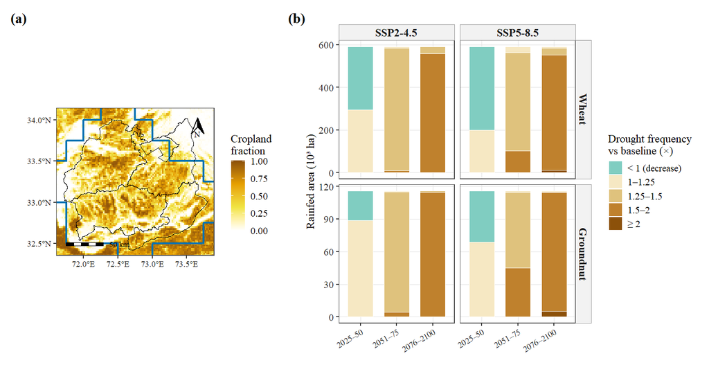

```r
hm_far <- hot_mask("ssp585", "far"); cf <- unwrap(VHI$crop)
cfa <- aggregate(rast(file.path(ROOT, "10_exposure", "worldcover_fractions_0p01.tif"))[["cropland"]], 2, mean)
hot_poly <- st_as_sf(as.polygons(hm_far)) |> (\(x) x[x[[1]] == 1, ])()
p9a <- ggplot() + geom_spatraster(data = cfa) + scale_fill_gradientn(colours = c("white", "#F0E442", "#E69F00", "#8c510a"), name = "Cropland\nfraction", na.value = NA, limits = c(0, 1)) +
  geom_sf(data = hot_poly, fill = NA, colour = "#0072B2", linewidth = 0.7) +
  geom_sf(data = dist, fill = NA, colour = "black", linewidth = 0.3) + coord_sf(xlim = c(71.6, 73.9), ylim = c(32.35, 34.15), expand = FALSE) +
  annotation_scale(location = "bl", height = unit(0.08, "cm"), text_family = "serif", text_cex = 0.45, line_width = 0.4) +
  annotation_north_arrow(location = "tr", height = unit(0.45, "cm"), width = unit(0.32, "cm"), style = north_arrow_orienteering(text_family = "serif", text_size = 4)) +
  labs(tag = "(a)") + theme(axis.text = element_text(size = 6))
eb <- melt(EXCLS, id.vars = c("cls", "scenario", "period"), measure.vars = c("wheat", "gnut"))
eb[, variable := factor(c(wheat = "Wheat", gnut = "Groundnut")[as.character(variable)], levels = c("Wheat", "Groundnut"))]
eb[, period := factor(c(near = "2025–50", mid = "2051–75", far = "2076–2100")[period], levels = c("2025–50", "2051–75", "2076–2100"))]
eb[, scenario := SCEN_LAB[scenario]]; eb[, cls := factor(cls, levels = CLS)]
p9b <- ggplot(eb, aes(period, value / 1000, fill = cls)) + geom_col(width = 0.7, colour = "white", linewidth = 0.15) +
  facet_grid(variable ~ scenario, scales = "free_y") + scale_fill_manual(values = c("#80CDC1", "#F6E8C3", "#DFC27D", "#BF812D", "#8C510A"), drop = FALSE,
                                                                         name = "Drought frequency\nvs baseline (×)") +
  labs(x = NULL, y = "Rainfed area (10³ ha)", tag = "(b)") + theme(axis.text.x = element_text(angle = 30, hjust = 1, size = 6), legend.position = "right")
fig9 <- p9a + p9b + plot_layout(widths = c(1, 1.5))
save_fig(fig9, "Fig09_district_exposure", IEEE2, 3.6); fig9
```